# Benchmark on eight eukaryotes

This notebook supports three parts of the manuscript:

- Methods, benchmark data, compared methods and accuracy measures (`../manuscript/sections/methods_benchmark.tex`);
- Results, accuracy across eight eukaryotes, with Table `tab:bench` (Table 1) (`../manuscript/sections/results_benchmark.tex`);
- Fig. 2 (`fig:benchmark`, `figures/fig2_benchmark.{pdf,png}`), a ggplot2 port of `figures/fig2_benchmark/make_fig2.py`.

Provenance: E07 (benchmark design, inputs, comparator versions and commands), E25 (release reruns of TransDecoder and PyTD), E16 (how the comparator papers benchmarked; background only, no numbers are taken from it here).

**Which runs.** TransDecoder appears in the benchmark under two sets of labels:

- *earlier final defaults*: `pytd_dev_v2` / `perl_td_dev_v2` (PyTD 48c870c, Perl de3f57e; fixed short-ORF test; E07). Earlier drafts of the manuscript quoted these runs; the text, Table 1 and Fig. 2 now use the release runs.
- *release*: `pytd_v7` / `perl_td_v7` (PyTD main 3a793ff, Perl devel 41fc5ee; decoy q-value test at q 0.05; E25), with the presets `pytd_v7_precise`, `pytd_v7_sensitive` and the homology runs `pytd_v7_homology`.

Figures, Table 1 and the numbers written here use the **release** runs (`pytd_v7`). The checks at the end compare them with the text as it stands, so a mismatch for a TransDecoder number shows a value the text must update. The section “Release versus earlier final defaults” lists the earlier values next to the release values. TransDecoder v6.0.0 is an older release that the text compares explicitly, so it is kept.

```r
S <- read_tab("benchmark", SUMMARY_FILE)
A7 <- read_tab("benchmark", "final_v7", "all_scores.tsv")
IDENT <- read_tab("benchmark", "final_v7", "perl_pytd_identity.tsv")
NEG <- read_tab("benchmark", "final_v7", "negatives_scores.tsv")

TD <- "pytd_v7"; TD_PERL <- "perl_td_v7"; TD_OLD <- "pytd_dev_v2"
INPUTS <- S %>% filter(tool == TD) %>% distinct(org, variant)
N_INPUTS <- nrow(INPUTS)

# value of one metric for one tool and variant, named by organism (in ORGS order; NA if missing)
V <- function(tool, variant, metric) {
  d <- S[S$tool == tool & S$variant == variant, ]
  setNames(d[[metric]][match(ORGS, d$org)], ORGS)
}
MED <- function(tool, variant, metric) median(V(tool, variant, metric), na.rm = TRUE)
r3 <- function(x) round(x, 3)
rng <- function(x) paste0(f3(min(x, na.rm = TRUE)), "-", f3(max(x, na.rm = TRUE)))
```

## Data and missing rows

The notebook reads one scored summary, `data/benchmark/summary.interim_20261025.tsv` (`score_all.py` with the fixed scorer, copied from `$P/work/bench_v3/scores/`; E07, E25). It has 2,302 rows (tool × input) over 84 inputs.

```r
release_and_comparators <- c(TD, TD_PERL, "pytd_v7_precise", "pytd_v7_sensitive", "pytd_v7_homology",
                             "perl_td_v600", "perl_td_v571", "prodigal", "gmst", "codan", "cpat", "cpc2",
                             "rnasamba", "borf", "longest_orf", "angel")
cov <- S %>% filter(tool %in% release_and_comparators) %>% count(tool, name = "rows") %>%
  mutate(tool = factor(tool, levels = release_and_comparators)) %>% arrange(tool)
miss <- function(tool) INPUTS %>% anti_join(S %>% filter(tool == !!tool), by = c("org", "variant"))
codan_miss <- miss("codan")
hom_miss <- miss("pytd_v7_homology")
hom_have <- S %>% filter(tool == "pytd_v7_homology") %>% distinct(org, variant)
hom_a7 <- A7 %>% filter(tool == "pytd_v7_homology") %>% distinct(org, variant)
kable(cov, caption = "Rows per tool (84 inputs in total)")
```

Rows per tool (84 inputs in total)

| tool | rows |
| --- | --- |
| pytd_v7 | 84 |
| perl_td_v7 | 84 |
| pytd_v7_precise | 20 |
| pytd_v7_sensitive | 20 |
| pytd_v7_homology | 32 |
| perl_td_v600 | 80 |
| perl_td_v571 | 84 |
| prodigal | 84 |
| gmst | 84 |
| codan | 79 |
| cpat | 84 |
| cpc2 | 84 |
| rnasamba | 44 |
| borf | 84 |
| longest_orf | 80 |
| angel | 3 |

```r
check_text("CodAn inputs without a row (4 lncRNA + T. thermophila complete.unstranded.wRand)",
           nrow(codan_miss), 5)
check_text("CodAn missing row outside wLnc is only T. thermophila complete.unstranded.wRand (1 = yes)",
           as.numeric(identical(paste(codan_miss$org, codan_miss$variant)[!grepl("wLnc", codan_miss$variant)],
                                "tthermophila complete.unstranded.wRand")), 1)
check_text("pytd_v7_homology rows in all_scores.tsv (all 84 finished)", nrow(hom_a7), 84)
```

Rows missing for the tools used here (all runs have ended; state checked 2026-10-30):

- **CodAn**: 5 of 84 inputs have no row: human complete.wLnc; human fragments.wLnc; mouse complete.wLnc; mouse fragments.wLnc; tthermophila complete.unstranded.wRand. The *T. thermophila* `complete.unstranded.wRand` run stopped without output (its files date from 2026-10-25 03:41, `codan.log` is empty and no CodAn process is running; E07 status update) and was not rerun, because CodAn has no ciliate genetic code and its *T. thermophila* runs are not results (E27). CodAn has no lncRNA (`wLnc`) runs. None of these inputs is used in Fig. 2 or Table 1, which use the stranded complete, complete + random and fragments inputs; CodAn has all 8 organisms there.
- **PyTD with homology** (`pytd_v7_homology`): 32 of 84 rows (athal 10, creinhardtii 10, dmel 10, human 2) in this summary, which was taken while the runs were in progress. All 84 finished on 2026-10-26 and are scored in `final_v7/all_scores.tsv` (84 rows; E25); the section on homology below uses those. These runs are not in Fig. 2 or Table 1. The manuscript’s homology results use the released homology mode (`pytd_v7h_homology`, PyTD a5b24c3, with homology-assisted start refinement; notebook 05, Fig. 5d,e; E25 addendum 2026-10-28).
- `--precise` and `--sensitive` were run on the negative-containing inputs only (20 each; E25).
- RNAsamba was run on stranded inputs only (44); v6.0.0, v5.7.1 and the longest-ORF baseline have no lncRNA inputs (80); ANGEL has 3 runs (dropped, Methods).

### Agreement with the release score table (E25)

`data/benchmark/final_v7/all_scores.tsv` was scored with `score_v7.sh` from the same runs (E25).

```r
key <- c("org", "variant", "tool")
metric_cols <- setdiff(names(A7), key)
J <- inner_join(S, A7, by = key, suffix = c(".s", ".a"))
diffs <- bind_rows(lapply(metric_cols, function(m) {
  d <- abs(J[[paste0(m, ".s")]] - J[[paste0(m, ".a")]]) > 1e-9
  tibble(column = m, rows_compared = nrow(J), rows_differing = sum(d, na.rm = TRUE))
}))
cons <- J %>% count(tool, name = "rows_in_both")
n_diff_cells <- sum(diffs$rows_differing)
kable(cons)
```

| tool | rows_in_both |
| --- | --- |
| perl_td_dev_v2 | 84 |
| perl_td_v7 | 84 |
| pytd_dev_v2 | 84 |
| pytd_v7 | 84 |
| pytd_v7_homology | 32 |

```r
details(diffs, "differences per column")
```

**differences per column**

| column | rows_compared | rows_differing |
| --- | --- | --- |
| n_truth | 368 | 0 |
| n_pred | 368 | 0 |
| n_pred_real | 368 | 0 |
| n_pred_random | 368 | 0 |
| tp_stop | 368 | 0 |
| tp_exact | 368 | 0 |
| fp | 368 | 0 |
| fp_random | 368 | 0 |
| fp_wrong_strand | 368 | 0 |
| fp_dup | 368 | 0 |
| fn | 368 | 0 |
| sensitivity_stop | 368 | 0 |
| precision_stop | 368 | 0 |
| f1_stop | 368 | 0 |
| sensitivity_exact | 368 | 0 |
| precision_exact | 368 | 0 |
| f1_exact | 368 | 0 |
| runtime_sec | 368 | 0 |

### Genetic-code compatibility

*T. thermophila* reads TAA and TAG as glutamine. GeneMarkS-T (tables 1, 4 and 11 only), CodAn, CPC2, RNAsamba and Borf have no option for this code; they were run with the standard code, so their *T. thermophila* results show only that the code is unsupported. These tool × organism results are **excluded** from everything below (reported as not applicable): Fig. 2 marks them “n/a”, their Table 1 medians are over the other seven organisms, and the rankings leave out *T. thermophila*. Their values are listed here and kept in `S_raw` (also used for run times, which do not depend on the code). TransDecoder (`-G Tetrahymena`), Prodigal (`-g 6`) and CPAT (TGA as the only stop) were run with the ciliate code.

```r
INCOMPATIBLE <- c("gmst", "codan", "cpc2", "rnasamba", "borf")
S_raw <- S
S <- S %>% filter(!(org == "tthermophila" & tool %in% INCOMPATIBLE))
details(S_raw %>% filter(org == "tthermophila", tool %in% INCOMPATIBLE,
                         variant %in% c("complete", "fragments", "complete.wRand")) %>%
          select(tool, variant, f1_stop, f1_exact, precision_stop) %>% mutate(across(where(is.numeric), r3)),
        "excluded: standard-code tools on T. thermophila (stranded inputs)")
```

**excluded: standard-code tools on T. thermophila (stranded inputs)**

| tool | variant | f1_stop | f1_exact | precision_stop |
| --- | --- | --- | --- | --- |
| borf | complete | 0.008 | 0.002 | 0.055 |
| codan | complete | 0.015 | 0.002 | 0.062 |
| cpc2 | complete | 0.007 | 0.001 | 0.060 |
| gmst | complete | 0.008 | 0.001 | 0.057 |
| rnasamba | complete | 0.014 | 0.002 | 0.059 |
| borf | complete.wRand | 0.008 | 0.002 | 0.051 |
| codan | complete.wRand | 0.015 | 0.002 | 0.062 |
| cpc2 | complete.wRand | 0.007 | 0.001 | 0.059 |
| gmst | complete.wRand | 0.008 | 0.002 | 0.057 |
| rnasamba | complete.wRand | 0.014 | 0.002 | 0.056 |
| borf | fragments | 0.007 | 0.001 | 0.126 |
| codan | fragments | 0.020 | 0.008 | 0.108 |
| cpc2 | fragments | 0.002 | 0.000 | 0.060 |
| gmst | fragments | 0.007 | 0.002 | 0.133 |
| rnasamba | fragments | 0.020 | 0.002 | 0.146 |

## Benchmark data (Methods)

```r
GENES_TEX <- c(human = 19167, mouse = 21409, dmel = 13884, athal = 26867, spombe = 5100,
               tthermophila = 26456, pfalciparum = 5281, creinhardtii = 17621)
genes <- S %>% filter(tool == TD, variant == "complete") %>% select(org, n_truth)
genes <- genes[match(ORGS, genes$org), ] %>% mutate(organism = ORG_LABEL[org], manuscript = GENES_TEX[org])
per_org <- INPUTS %>% filter(!grepl("wLnc", variant)) %>% count(org)
lnc_inputs <- INPUTS %>% filter(grepl("wLnc", variant))
n_lnc <- NEG %>% filter(variant == "complete.wLnc", label == TD) %>% select(org, n_neg)
n_lnc <- setNames(n_lnc$n_neg, n_lnc$org)
stopifnot(all(S$n_truth[S$tool == TD] == genes$n_truth[match(S$org[S$tool == TD], genes$org)]))
kable(genes %>% select(organism, genes = n_truth, manuscript), caption = "Truth-set genes (complete input)")
```

Truth-set genes (complete input)

| organism | genes | manuscript |
| --- | --- | --- |
| P. falciparum | 5281 | 5281 |
| T. thermophila | 26456 | 26456 |
| S. pombe | 5100 | 5100 |
| A. thaliana | 26867 | 26867 |
| D. melanogaster | 13884 | 13884 |
| M. musculus | 21409 | 21409 |
| H. sapiens | 19167 | 19167 |
| C. reinhardtii | 17621 | 17621 |

- Eight organisms; truth-set sizes from 5,100 (*S. pombe*) to 26,867 (*A. thaliana*) genes. Every input of an organism has the same `n_truth`.
- 10 inputs per organism without lncRNA negatives, plus 4 lncRNA inputs (human and mouse, complete and fragments): 84 inputs in total.
- lncRNA negatives: 33,668 (human) and 31,467 (mouse) (`negatives_scores.tsv`, E25).
- The G+C values of Table `tab:orgs` and the numbers of UTRs added (0 to 1,142) come from the truth logs and input FASTAs (E07) and are not in a committed table; they are not recomputed here.

## Compared methods (Methods)

```r
v6 <- S %>% filter(tool %in% c("perl_td_v600", "perl_td_v571")) %>%
  select(org, variant, tool, all_of(setdiff(metric_cols, "runtime_sec"))) %>%
  pivot_longer(-c(org, variant, tool)) %>% pivot_wider(names_from = tool) %>% filter(!is.na(perl_td_v600))
v6_inputs <- n_distinct(paste(v6$org, v6$variant))
v6_same <- v6 %>% group_by(org, variant) %>% summarise(same = all(perl_td_v600 == perl_td_v571), .groups = "drop")
angel <- S %>% filter(tool == "angel") %>% transmute(org, variant, hours = runtime_sec / 3600)
others_athal <- S %>% filter(org == "athal", variant == "complete",
                             tool %in% c(TD, TD_PERL, "prodigal", "gmst", "cpat", "cpc2", "rnasamba", "borf", "codan")) %>%
  transmute(tool, minutes = round(runtime_sec / 60, 1)) %>% arrange(minutes)
kable(angel %>% mutate(hours = round(hours, 1)), caption = "ANGEL runs")
```

ANGEL runs

| org | variant | hours |
| --- | --- | --- |
| athal | complete | 17.4 |
| athal | complete_fullutr | 17.7 |
| athal | complete_fullutr.unstranded | 21.9 |

```r
kable(others_athal, caption = "Other tools, A. thaliana complete")
```

Other tools, A. thaliana complete

| tool | minutes |
| --- | --- |
| cpc2 | 0.5 |
| borf | 0.6 |
| gmst | 0.6 |
| prodigal | 0.8 |
| cpat | 1.0 |
| rnasamba | 1.8 |
| pytd_v7 | 4.4 |
| perl_td_v7 | 11.1 |
| codan | 585.2 |

- v5.7.1 and v6.0.0 have identical scores on all 80 of 80 inputs they share (every score column). E07 checked that their `preds.tsv` files are byte-identical.
- ANGEL: 3 *A. thaliana* runs of 17.4-21.9 h (wall clock). On the *A. thaliana* complete input, all other tools except CodAn (9.8 h) took 0.5-11.1 min.

## Accuracy measures (Methods)

The scoring rules (stop within 2 nt; exact within 2 nt at both ends) are applied by `score_predictions.py` (E07). Runtimes are wall-clock seconds per run (`runtime_sec`) under 6-16 concurrent jobs on a shared 28-core host (E07); the concurrency is from the launch logs, not from a table here.

## Table 1: benchmark accuracy

Median over the eight organisms, stranded inputs: stop and exact F1 on complete and fragments, and stop-level precision on complete + random (`complete.wRand`). For the tools that do not support the ciliate code, the medians are over the other seven organisms (*T. thermophila* not applicable).

```r
TOOLS <- c(pytd_v7 = "TransDecoder (release)", perl_td_v600 = "TransDecoder v6.0.0",
           longest_orf = "longest ORF", prodigal = "Prodigal", gmst = "GeneMarkS-T", cpat = "CPAT",
           rnasamba = "RNAsamba", cpc2 = "CPC2", borf = "Borf", codan = "CodAn")
COLS <- tribble(~col, ~variant, ~metric,
                "complete_stop_f1", "complete", "f1_stop",
                "complete_exact_f1", "complete", "f1_exact",
                "fragments_stop_f1", "fragments", "f1_stop",
                "fragments_exact_f1", "fragments", "f1_exact",
                "complete_rand_precision", "complete.wRand", "precision_stop")
tab1_long <- tidyr::crossing(tool = names(TOOLS), COLS) %>% rowwise() %>%
  mutate(median = MED(tool, variant, metric), n_orgs = sum(!is.na(V(tool, variant, metric)))) %>% ungroup()
table1 <- tab1_long %>% select(tool, col, median) %>% pivot_wider(names_from = col, values_from = median) %>%
  left_join(tab1_long %>% group_by(tool) %>% summarise(min_orgs = min(n_orgs)), by = "tool") %>%
  mutate(label = TOOLS[tool], tool = factor(tool, levels = names(TOOLS))) %>% arrange(tool) %>%
  mutate(tool = as.character(tool),
         note = case_when(tool %in% INCOMPATIBLE ~ "7 organisms (ciliate code not supported)",
                          min_orgs < 8 ~ sprintf("interim: %d of 8 organisms in some column", min_orgs),
                          TRUE ~ "")) %>%
  select(tool, label, all_of(COLS$col), min_orgs, note)
write_tsv(table1 %>% mutate(across(all_of(COLS$col), ~ round(.x, 4))),
          data_path("benchmark", "final_v7", "table1.tsv"))
T1 <- function(tool, col) table1[[col]][table1$tool == tool]
kableExtra::kable_styling(kable(table1 %>% select(-tool, -min_orgs) %>% mutate(across(all_of(COLS$col), r3)),
  col.names = c("method", "complete stop F1", "complete exact F1", "fragments stop F1", "fragments exact F1",
                "complete + rand precision", "note"),
  caption = sprintf("Table 1 (from %s; written to data/benchmark/final_v7/table1.tsv)", SUMMARY_FILE)),
  full_width = FALSE)
```

Table 1 (from summary.interim_20261025.tsv; written to data/benchmark/final_v7/table1.tsv)

| method | complete stop F1 | complete exact F1 | fragments stop F1 | fragments exact F1 | complete + rand precision | note |
| --- | --- | --- | --- | --- | --- | --- |
| TransDecoder (release) | 0.980 | 0.912 | 0.930 | 0.822 | 0.994 |  |
| TransDecoder v6.0.0 | 0.972 | 0.779 | 0.869 | 0.715 | 0.995 |  |
| longest ORF | 0.976 | 0.689 | 0.839 | 0.713 | 0.803 |  |
| Prodigal | 0.937 | 0.643 | 0.936 | 0.782 | 0.660 |  |
| GeneMarkS-T | 0.974 | 0.783 | 0.866 | 0.746 | 0.996 | 7 organisms (ciliate code not supported) |
| CPAT | 0.965 | 0.940 | 0.783 | 0.440 | 0.971 |  |
| RNAsamba | 0.991 | 0.961 | 0.864 | 0.486 | 0.721 | 7 organisms (ciliate code not supported) |
| CPC2 | 0.964 | 0.935 | 0.572 | 0.183 | 0.982 | 7 organisms (ciliate code not supported) |
| Borf | 0.976 | 0.923 | 0.816 | 0.538 | 0.838 | 7 organisms (ciliate code not supported) |
| CodAn | 0.974 | 0.830 | 0.912 | 0.761 | 0.946 | 7 organisms (ciliate code not supported) |

All other cells are medians over all 8 organisms. The manuscript row for CodAn is still a placeholder; the computed CodAn row is 0.974 / 0.830 / 0.912 / 0.761 / 0.946.

## Fig. 2: accuracy on eight eukaryotes

Stranded inputs, organisms ordered by transcriptome G+C. Panels a-e are heatmaps (colour clipped at 0.4); panel f is the run time on complete inputs, median and range over organisms. Cells marked “n/a” are tools that do not support the ciliate code on *T. thermophila* (GeneMarkS-T, CodAn, CPC2, RNAsamba, Borf; not applicable, above); grey cells marked “pend.” are rows missing from the summary. TransDecoder is the release default (`pytd_v7`, identical to `perl_td_v7`).

```r
HEAT_TOOLS <- c(pytd_v7 = "TransDecoder", perl_td_v600 = "TransDecoder v6.0.0", prodigal = "Prodigal",
                gmst = "GeneMarkS-T", codan = "CodAn", cpat = "CPAT", cpc2 = "CPC2", rnasamba = "RNAsamba",
                borf = "Borf", longest_orf = "longest ORF")
WRONG_CODE <- c("gmst", "codan", "cpc2", "rnasamba", "borf")
PANELS <- tribble(~panel, ~variant, ~metric, ~title,
                  "a", "complete", "f1_stop", "complete: stop-level F1",
                  "b", "complete", "f1_exact", "complete: exact F1",
                  "c", "complete.wRand", "precision_stop", "complete + random: precision",
                  "d", "fragments", "f1_stop", "fragments: stop-level F1",
                  "e", "fragments", "f1_exact", "fragments: exact F1")
ORG_SHORT <- c(pfalciparum = "P. fal.", tthermophila = "T. the.", spombe = "S. pom.", athal = "A. tha.",
               dmel = "D. mel.", mouse = "M. mus.", human = "H. sap.", creinhardtii = "C. rei.")
heat <- tidyr::crossing(PANELS, tool = names(HEAT_TOOLS), org = ORGS) %>% rowwise() %>%
  mutate(value = V(tool, variant, metric)[[org]]) %>% ungroup() %>%
  mutate(wrong = org == "tthermophila" & tool %in% WRONG_CODE,
         x = match(org, ORGS), y = length(HEAT_TOOLS) + 1 - match(tool, names(HEAT_TOOLS)),
         lab = ifelse(wrong, "n/a", ifelse(is.na(value), "pend.", ifelse(round(value, 2) >= 1, "1.0", sub("^0", "", sprintf("%.2f", value))))))
n_pending <- sum(is.na(heat$value) & !heat$wrong)

RT_TOOLS <- c(pytd_v7 = "PyTD", perl_td_v7 = "TD (Perl)", prodigal = "Prodigal",
              gmst = "GeneMarkS-T", codan = "CodAn", cpat = "CPAT", cpc2 = "CPC2", rnasamba = "RNAsamba",
              borf = "Borf", angel = "ANGEL")
rt <- S_raw %>% filter(variant == "complete", tool %in% names(RT_TOOLS)) %>% group_by(tool) %>%
  summarise(median = median(runtime_sec), min = min(runtime_sec), max = max(runtime_sec), n = n()) %>%
  mutate(label = RT_TOOLS[tool], y = length(RT_TOOLS) + 1 - match(tool, names(RT_TOOLS)),
         note = case_when(tool == "angel" ~ sprintf("%.0f h (A. thal.)", median / 3600),
                          median > 3600 ~ sprintf("%.1f h%s", median / 3600, ifelse(n == 8, "", sprintf("  (n = %d)", n))),
                          TRUE ~ paste0(num(round(median)), " s", ifelse(n == 8, "", sprintf("  (n = %d)", n)))))
```

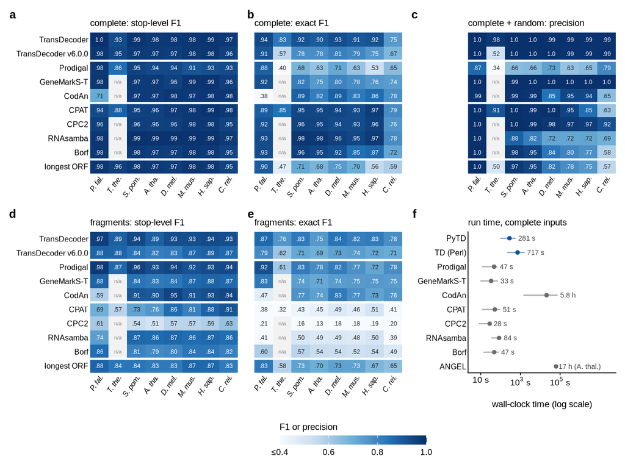

```r
heat_fill <- scale_fill_gradientn(colours = c("#f7fbff", "#c6dbef", "#6baed6", "#2171b5", "#08306b"),
                                  limits = c(0.4, 1), oob = scales::squish, breaks = c(0.4, 0.6, 0.8, 1),
                                  labels = c("≤0.4", "0.6", "0.8", "1.0"), name = "F1 or precision",
                                  na.value = "#dddddd")
hatch <- function(d) {   # diagonal lines inside each hatched cell
  if (nrow(d) == 0) return(NULL)
  offs <- seq(-0.8, 0.8, by = 0.2)
  segs <- tidyr::crossing(d %>% select(x, y), o = offs) %>%
    mutate(x0 = pmax(-0.5, -0.5 + o), y0 = pmax(-0.5, -0.5 - o), x1 = pmin(0.5, 0.5 + o), y1 = pmin(0.5, 0.5 - o)) %>%
    filter(x1 > x0)
  geom_segment(data = segs, aes(x = x + x0, y = y + y0, xend = x + x1, yend = y + y1),
               inherit.aes = FALSE, colour = "#aaaaaa", linewidth = 0.15)
}
heat_panel <- function(p, show_rows) {
  d <- heat %>% filter(panel == p)
  ok <- d %>% filter(!wrong)
  ggplot(ok, aes(x, y)) +
    geom_tile(aes(fill = value), colour = NA) +
    geom_tile(data = d %>% filter(wrong), fill = "#f2f2f2", colour = NA) +
    geom_text(aes(label = lab, colour = !is.na(value) & (pmin(value, 1) - 0.4) / 0.6 > 0.55), size = 1.62) +
    geom_text(data = d %>% filter(wrong), aes(label = lab), colour = "#888888", size = 1.5) +
    scale_colour_manual(values = c(`TRUE` = "white", `FALSE` = "#222222"), guide = "none") +
    geom_hline(yintercept = length(HEAT_TOOLS) + 0.5 - c(2, 5, 9), colour = "white", linewidth = 0.8) +
    heat_fill +
    scale_x_continuous(breaks = seq_along(ORGS), labels = ORG_SHORT[ORGS], expand = c(0, 0)) +
    scale_y_continuous(breaks = seq_along(HEAT_TOOLS), labels = if (show_rows) rev(HEAT_TOOLS) else NULL,
                       expand = c(0, 0)) +
    labs(x = NULL, y = NULL, title = PANELS$title[PANELS$panel == p]) +
    theme(axis.text.x = element_text(angle = 55, hjust = 1, face = "italic", size = 5.6),
          axis.text.y = element_text(size = 6), axis.line = element_blank(), axis.ticks = element_blank())
}
rt_panel <- ggplot(rt, aes(y = y)) +
  geom_segment(aes(x = min, xend = max, yend = y, colour = tool %in% c(TD, TD_PERL)), linewidth = 0.4, alpha = 0.6) +
  geom_point(aes(x = median, colour = tool %in% c(TD, TD_PERL)), size = 1.2) +
  geom_text(aes(x = pmax(max, median) * 1.35, label = note), hjust = 0, size = 1.9, colour = "#444444") +
  scale_colour_manual(values = c(`TRUE` = TD_C, `FALSE` = "#6b6b6b"), guide = "none") +
  scale_x_log10(limits = c(5, 3e7), breaks = c(10, 1e3, 1e5), labels = c("10 s", expression(10^3~s), expression(10^5~s))) +
  coord_cartesian(clip = "off") +
  scale_y_continuous(breaks = rt$y, labels = rt$label) +
  labs(x = "wall-clock time (log scale)", y = NULL,
       title = "run time, complete inputs") +
  theme(axis.ticks.y = element_blank(), axis.text.y = element_text(size = 6))
fig2 <- (heat_panel("a", TRUE) + heat_panel("b", FALSE) + heat_panel("c", FALSE) +
         heat_panel("d", TRUE) + heat_panel("e", FALSE) + rt_panel) +
  plot_layout(ncol = 3, guides = "collect") + plot_annotation(tag_levels = "a") &
  theme(legend.position = "bottom", legend.key.width = unit(8, "mm"), legend.key.height = unit(2.5, "mm"),
        legend.title.position = "top")
png_f <- save_fig(fig2, "fig2_benchmark", FULL_W, 128 * MM)
fig2
```

Pending cells in the heatmaps: 0. Not-applicable cells: 5 per panel.

```r
for (p in PANELS$panel) {
  w <- heat %>% filter(panel == p) %>% arrange(match(tool, names(HEAT_TOOLS)), match(org, ORGS)) %>%
    transmute(method = HEAT_TOOLS[tool], org = ORG_LABEL[org], value = r3(value)) %>%
    pivot_wider(names_from = org, values_from = value)
  print(details(w, sprintf("panel %s: %s (values)", p, PANELS$title[PANELS$panel == p])))
}
```

[1] “

**panel a: complete: stop-level F1 (values)**

| method | P. falciparum | T. thermophila | S. pombe | A. thaliana | D. melanogaster | M. musculus | H. sapiens | C. reinhardtii |
| --- | --- | --- | --- | --- | --- | --- | --- | --- |
| TransDecoder | 0.997 | 0.933 | 0.987 | 0.977 | 0.978 | 0.983 | 0.986 | 0.975 |
| TransDecoder v6.0.0 | 0.984 | 0.948 | 0.974 | 0.970 | 0.966 | 0.980 | 0.985 | 0.962 |
| Prodigal | 0.978 | 0.856 | 0.953 | 0.939 | 0.939 | 0.912 | 0.927 | 0.934 |
| GeneMarkS-T | 0.984 | NA | 0.974 | 0.973 | 0.957 | 0.986 | 0.987 | 0.964 |
| CodAn | 0.710 | NA | 0.972 | 0.970 | 0.983 | 0.974 | 0.980 | 0.982 |
| CPAT | 0.937 | 0.884 | 0.955 | 0.957 | 0.972 | 0.980 | 0.989 | 0.979 |
| CPC2 | 0.964 | NA | 0.965 | 0.962 | 0.964 | 0.980 | 0.979 | 0.953 |
| RNAsamba | 0.982 | NA | 0.993 | 0.992 | 0.989 | 0.991 | 0.993 | 0.974 |
| Borf | 0.984 | NA | 0.976 | 0.970 | 0.966 | 0.983 | 0.978 | 0.955 |
| longest ORF | 0.984 | 0.961 | 0.978 | 0.974 | 0.968 | 0.984 | 0.980 | 0.954 |

**panel b: complete: exact F1 (values)**

| method | P. falciparum | T. thermophila | S. pombe | A. thaliana | D. melanogaster | M. musculus | H. sapiens | C. reinhardtii |
| --- | --- | --- | --- | --- | --- | --- | --- | --- |
| TransDecoder | 0.940 | 0.833 | 0.916 | 0.899 | 0.928 | 0.907 | 0.920 | 0.747 |
| TransDecoder v6.0.0 | 0.912 | 0.567 | 0.781 | 0.777 | 0.811 | 0.794 | 0.755 | 0.670 |
| Prodigal | 0.884 | 0.395 | 0.680 | 0.634 | 0.714 | 0.630 | 0.529 | 0.653 |
| GeneMarkS-T | 0.925 | NA | 0.820 | 0.751 | 0.802 | 0.783 | 0.756 | 0.741 |
| CodAn | 0.378 | NA | 0.886 | 0.819 | 0.887 | 0.830 | 0.859 | 0.780 |
| CPAT | 0.891 | 0.851 | 0.946 | 0.948 | 0.945 | 0.935 | 0.969 | 0.786 |
| CPC2 | 0.916 | NA | 0.955 | 0.952 | 0.935 | 0.935 | 0.959 | 0.761 |
| RNAsamba | 0.934 | NA | 0.982 | 0.981 | 0.961 | 0.946 | 0.973 | 0.781 |
| Borf | 0.931 | NA | 0.963 | 0.946 | 0.923 | 0.853 | 0.870 | 0.716 |
| longest ORF | 0.897 | 0.469 | 0.715 | 0.680 | 0.748 | 0.698 | 0.557 | 0.595 |

**panel c: complete + random: precision (values)**

| method | P. falciparum | T. thermophila | S. pombe | A. thaliana | D. melanogaster | M. musculus | H. sapiens | C. reinhardtii |
| --- | --- | --- | --- | --- | --- | --- | --- | --- |
| TransDecoder | 0.997 | 0.980 | 0.995 | 0.997 | 0.994 | 0.994 | 0.992 | 0.992 |
| TransDecoder v6.0.0 | 1.000 | 0.519 | 0.995 | 0.995 | 0.997 | 0.992 | 0.992 | 0.994 |
| Prodigal | 0.866 | 0.344 | 0.655 | 0.664 | 0.730 | 0.631 | 0.652 | 0.792 |
| GeneMarkS-T | 1.000 | NA | 0.995 | 0.996 | 0.997 | 0.996 | 0.997 | 0.996 |
| CodAn | 0.993 | NA | 0.992 | 0.987 | 0.849 | 0.946 | 0.942 | 0.652 |
| CPAT | 1.000 | 0.913 | 0.999 | 0.992 | 0.995 | 0.951 | 0.854 | 0.629 |
| CPC2 | 1.000 | NA | 0.999 | 0.994 | 0.982 | 0.973 | 0.967 | 0.922 |
| RNAsamba | 0.997 | NA | 0.881 | 0.815 | 0.721 | 0.719 | 0.721 | 0.695 |
| Borf | 0.998 | NA | 0.977 | 0.955 | 0.838 | 0.800 | 0.773 | 0.582 |
| longest ORF | 0.998 | 0.499 | 0.973 | 0.948 | 0.823 | 0.783 | 0.755 | 0.567 |

**panel d: fragments: stop-level F1 (values)**

| method | P. falciparum | T. thermophila | S. pombe | A. thaliana | D. melanogaster | M. musculus | H. sapiens | C. reinhardtii |
| --- | --- | --- | --- | --- | --- | --- | --- | --- |
| TransDecoder | 0.965 | 0.887 | 0.941 | 0.888 | 0.930 | 0.928 | 0.938 | 0.929 |
| TransDecoder v6.0.0 | 0.878 | 0.876 | 0.840 | 0.822 | 0.829 | 0.871 | 0.886 | 0.866 |
| Prodigal | 0.978 | 0.869 | 0.961 | 0.932 | 0.945 | 0.920 | 0.933 | 0.938 |
| GeneMarkS-T | 0.880 | NA | 0.841 | 0.828 | 0.835 | 0.866 | 0.880 | 0.869 |
| CodAn | 0.588 | NA | 0.910 | 0.901 | 0.951 | 0.912 | 0.929 | 0.944 |
| CPAT | 0.693 | 0.573 | 0.729 | 0.755 | 0.860 | 0.811 | 0.880 | 0.915 |
| CPC2 | 0.608 | NA | 0.542 | 0.505 | 0.570 | 0.572 | 0.589 | 0.632 |
| RNAsamba | 0.739 | NA | 0.870 | 0.864 | 0.873 | 0.858 | 0.870 | 0.858 |
| Borf | 0.858 | NA | 0.807 | 0.790 | 0.799 | 0.838 | 0.838 | 0.816 |
| longest ORF | 0.878 | 0.838 | 0.840 | 0.828 | 0.826 | 0.871 | 0.870 | 0.826 |

**panel e: fragments: exact F1 (values)**

| method | P. falciparum | T. thermophila | S. pombe | A. thaliana | D. melanogaster | M. musculus | H. sapiens | C. reinhardtii |
| --- | --- | --- | --- | --- | --- | --- | --- | --- |
| TransDecoder | 0.868 | 0.759 | 0.830 | 0.753 | 0.841 | 0.818 | 0.825 | 0.778 |
| TransDecoder v6.0.0 | 0.788 | 0.622 | 0.715 | 0.693 | 0.730 | 0.740 | 0.716 | 0.706 |
| Prodigal | 0.925 | 0.612 | 0.826 | 0.782 | 0.823 | 0.771 | 0.718 | 0.782 |
| GeneMarkS-T | 0.830 | NA | 0.737 | 0.711 | 0.743 | 0.749 | 0.751 | 0.746 |
| CodAn | 0.465 | NA | 0.769 | 0.736 | 0.827 | 0.773 | 0.725 | 0.761 |
| CPAT | 0.376 | 0.322 | 0.432 | 0.447 | 0.487 | 0.461 | 0.506 | 0.410 |
| CPC2 | 0.214 | NA | 0.160 | 0.128 | 0.183 | 0.178 | 0.193 | 0.198 |
| RNAsamba | 0.408 | NA | 0.499 | 0.486 | 0.490 | 0.480 | 0.502 | 0.390 |
| Borf | 0.598 | NA | 0.573 | 0.541 | 0.538 | 0.524 | 0.538 | 0.487 |
| longest ORF | 0.832 | 0.579 | 0.730 | 0.697 | 0.730 | 0.731 | 0.669 | 0.648 |

```r
print(details(rt %>% arrange(desc(y)) %>% transmute(method = label, n, median_s = round(median, 1),
                                                     min_s = round(min, 1), max_s = round(max, 1)),
              "panel f: run time on complete inputs (seconds)"))
```

[1] “

**panel f: run time on complete inputs (seconds)**

| method | n | median_s | min_s | max_s |
| --- | --- | --- | --- | --- |
| PyTD | 8 | 280.9 | 96.6 | 576.7 |
| TD (Perl) | 8 | 717.0 | 215.4 | 1619.9 |
| Prodigal | 8 | 47.2 | 11.2 | 68.3 |
| GeneMarkS-T | 8 | 33.3 | 9.5 | 73.2 |
| CodAn | 8 | 20839.4 | 1409.2 | 74839.7 |
| CPAT | 8 | 51.3 | 11.8 | 95.9 |
| CPC2 | 8 | 28.2 | 7.7 | 33.4 |
| RNAsamba | 8 | 83.6 | 34.3 | 107.4 |
| Borf | 8 | 47.5 | 13.4 | 79.7 |
| ANGEL | 1 | 62502.9 | 62502.9 | 62502.9 |

## Implementations: Perl and Python

```r
n_ident <- sum(IDENT$identical)
pp <- S %>% filter(tool %in% c(TD, TD_PERL)) %>% select(org, variant, tool, all_of(setdiff(metric_cols, "runtime_sec"))) %>%
  pivot_longer(-c(org, variant, tool)) %>% pivot_wider(names_from = tool)
n_score_diff <- sum(pp[[TD]] != pp[[TD_PERL]])
ratio <- S %>% filter(tool %in% c(TD, TD_PERL)) %>% select(org, variant, tool, runtime_sec) %>%
  pivot_wider(names_from = tool, values_from = runtime_sec) %>% mutate(ratio = .data[[TD_PERL]] / .data[[TD]])
ratio_c <- ratio %>% filter(variant == "complete")
rt_med <- function(tool) median(S$runtime_sec[S$tool == tool & S$variant == "complete"])
ident_rt <- IDENT %>% inner_join(ratio, by = c("org", "variant"))
stopifnot(all(abs(ident_rt$perl_runtime_sec - ident_rt[[TD_PERL]]) < 1e-6),
          all(abs(ident_rt$pytd_runtime_sec - ident_rt[[TD]]) < 1e-6))
```

- Predictions of the Perl and Python release versions are identical in 84 of 84 inputs (`perl_pytd_identity.tsv`: sorted `preds.tsv` compared, E25), and all score columns agree (0 differing cells). One set of numbers describes both implementations.
- Run time, Perl / Python: median ratio 2.71 (2.07-3.28) over the 84 inputs; on complete inputs 2.57. Median run time on complete inputs: Python 281 s, Perl 717 s (earlier final defaults: 185 s and 422 s). Shared host, indicative only. The 2.3-fold figure in the abstract and in Results, algorithm, is for the earlier runs and is checked in `01_algorithm.Rmd`.

## Accuracy across eight eukaryotes

The text opens by stating that the Perl and Python implementations gave identical predictions; see the section above (84/84 inputs, release versions). E25

### Stop codons

```r
td_cs <- V(TD, "complete", "f1_stop"); v6_cs <- V("perl_td_v600", "complete", "f1_stop")
lo_cs <- V("longest_orf", "complete", "f1_stop")
td_v6_maxdiff <- max(abs(td_cs - v6_cs))
```

On complete transcripts, the release default had a stop-level F1 of 0.933-0.997 (median 0.980), against 0.948-0.985 for v6.0.0 and 0.954-0.984 for the longest-ORF baseline. Per organism, the release default was within 0.014 of v6.0.0 at the stop level. E07, E25

### Noncoding sequence

```r
td_p <- V(TD, "complete.wRand", "precision_stop")
pr_p <- V("prodigal", "complete.wRand", "precision_stop")
lo_p <- V("longest_orf", "complete.wRand", "precision_stop")
cp_p <- V("cpat", "complete.wRand", "precision_stop")
```

With one GC-matched random sequence per transcript, the release default kept a median stop-level precision of 0.994 (0.980-0.997), and its median stop F1 went from 0.980 to 0.979. Prodigal’s precision was 0.344-0.866 (median 0.660), and its median stop F1 went from 0.937 to 0.791. The longest-ORF baseline had a median precision of 0.803 (*C. reinhardtii* 0.567). RNAsamba 0.721, Borf 0.838; CPAT 0.971 (*C. reinhardtii* 0.629).

### Start codons

```r
td_ce <- V(TD, "complete", "f1_exact"); v6_ce <- V("perl_td_v600", "complete", "f1_exact")
cls_ce <- sapply(c("cpat", "rnasamba", "cpc2"), MED, variant = "complete", metric = "f1_exact")
cls_fe <- sapply(c("cpat", "rnasamba", "cpc2"), MED, variant = "fragments", metric = "f1_exact")
```

The longest-ORF baseline had a median exact F1 of 0.689. The release default had an exact F1 of 0.747-0.940 on complete transcripts (median 0.912), against 0.567-0.912 (median 0.779) for v6.0.0. Prodigal median 0.643, GeneMarkS-T 0.783. CPAT, RNAsamba and CPC2: medians 0.935-0.961 on complete transcripts and 0.183-0.486 on fragments (TransDecoder 0.822).

### Fragments

```r
td_fs <- V(TD, "fragments", "f1_stop"); pr_fs <- V("prodigal", "fragments", "f1_stop")
td_fe <- V(TD, "fragments", "f1_exact"); pr_fe <- V("prodigal", "fragments", "f1_exact")
prod_better_stop <- names(which(pr_fs > td_fs))
td_better_exact <- names(which(td_fe > pr_fe))
kable(tibble(organism = ORG_LABEL[ORGS], TD_stop = r3(td_fs), Prodigal_stop = r3(pr_fs),
             TD_exact = r3(td_fe), Prodigal_exact = r3(pr_fe)))
```

| organism | TD_stop | Prodigal_stop | TD_exact | Prodigal_exact |
| --- | --- | --- | --- | --- |
| P. falciparum | 0.965 | 0.978 | 0.868 | 0.925 |
| T. thermophila | 0.887 | 0.869 | 0.759 | 0.612 |
| S. pombe | 0.941 | 0.961 | 0.830 | 0.826 |
| A. thaliana | 0.888 | 0.932 | 0.753 | 0.782 |
| D. melanogaster | 0.930 | 0.945 | 0.841 | 0.823 |
| M. musculus | 0.928 | 0.920 | 0.818 | 0.771 |
| H. sapiens | 0.938 | 0.933 | 0.825 | 0.718 |
| C. reinhardtii | 0.929 | 0.938 | 0.778 | 0.782 |

On fragments, Prodigal had the higher stop F1 in 5 of 8 organisms (median 0.936 vs 0.930); *T. thermophila*: 0.869 vs 0.887. At the exact level TransDecoder was higher in T. thermophila, S. pombe, D. melanogaster, M. musculus, H. sapiens.

### Ciliate genetic code

```r
std_tools <- c("gmst", "rnasamba", "cpc2", "borf")
tthe_std <- S_raw %>% filter(org == "tthermophila", tool %in% std_tools, variant %in% c("complete", "fragments")) %>%
  select(tool, variant, f1_stop, f1_exact)
tthe_max <- max(c(tthe_std$f1_stop, tthe_std$f1_exact))
codan_tthe <- S_raw %>% filter(org == "tthermophila", tool == "codan", variant %in% c("complete", "fragments", "complete.wRand")) %>%
  select(variant, f1_stop, f1_exact, precision_stop)
TT <- function(tool, variant, metric) V(tool, variant, metric)[["tthermophila"]]
kable(tthe_std)
```

| tool | variant | f1_stop | f1_exact |
| --- | --- | --- | --- |
| borf | complete | 0.0082 | 0.0015 |
| cpc2 | complete | 0.0066 | 0.0011 |
| gmst | complete | 0.0079 | 0.0014 |
| rnasamba | complete | 0.0142 | 0.0016 |
| borf | fragments | 0.0074 | 0.0014 |
| cpc2 | fragments | 0.0022 | 0.0001 |
| gmst | fragments | 0.0073 | 0.0019 |
| rnasamba | fragments | 0.0201 | 0.0025 |

```r
kable(codan_tthe, caption = "CodAn on T. thermophila (standard code)")
```

CodAn on T. thermophila (standard code)

| variant | f1_stop | f1_exact | precision_stop |
| --- | --- | --- | --- |
| complete | 0.0152 | 0.0015 | 0.0625 |
| complete.wRand | 0.0152 | 0.0015 | 0.0624 |
| fragments | 0.0200 | 0.0080 | 0.1075 |

### GC extremes

```r
cre_others <- sapply(c("perl_td_v600", "prodigal", "gmst", "cpat"), function(t) V(t, "complete", "f1_exact")[["creinhardtii"]])
```

*P. falciparum*: exact F1 0.940 (highest of the eight: P. falciparum), stop F1 0.997. *C. reinhardtii*: stop F1 0.975, exact F1 0.747 (lowest: C. reinhardtii). Other methods on *C. reinhardtii* (v6.0.0, Prodigal, GeneMarkS-T, CPAT): exact F1 0.653-0.786.

## Homology evidence

The Methods list PyTD with DIAMOND/Pfam evidence. Release homology runs (`pytd_v7_homology`, PyTD 3a793ff, before the homology-assisted start refinement): all 84 of 84, from `final_v7/all_scores.tsv` (E25). The manuscript’s homology numbers on the benchmark inputs come from the released homology mode (`pytd_v7h_homology`, which also uses homology in start refinement) and are reproduced in notebook 05.

```r
hom <- A7 %>% filter(tool %in% c(TD, "pytd_v7_homology")) %>%
  select(org, variant, tool, sensitivity_stop, precision_stop, f1_exact) %>%
  pivot_wider(names_from = tool, values_from = c(sensitivity_stop, precision_stop, f1_exact)) %>%
  filter(!is.na(sensitivity_stop_pytd_v7_homology)) %>%
  transmute(org, variant, d_sens_stop = sensitivity_stop_pytd_v7_homology - sensitivity_stop_pytd_v7,
            d_prec_stop = precision_stop_pytd_v7_homology - precision_stop_pytd_v7,
            d_f1_exact = f1_exact_pytd_v7_homology - f1_exact_pytd_v7,
            type = ifelse(grepl("^fragments", variant), "fragments", "complete-type"))
hom_sum <- hom %>% group_by(type) %>% summarise(inputs = n(), across(starts_with("d_"), list(min = min, max = max)))
kable(hom_sum %>% mutate(across(starts_with("d_"), ~ round(.x, 4))),
      caption = "Homology (pytd_v7_homology, 3a793ff) minus ab initio (release), 84 inputs")
```

Homology (pytd_v7_homology, 3a793ff) minus ab initio (release), 84 inputs

| type | inputs | d_sens_stop_min | d_sens_stop_max | d_prec_stop_min | d_prec_stop_max | d_f1_exact_min | d_f1_exact_max |
| --- | --- | --- | --- | --- | --- | --- | --- |
| complete-type | 50 | -0.0029 | 0.0372 | -0.0648 | 0.0066 | -0.0211 | 0.0209 |
| fragments | 34 | 0.0042 | 0.0920 | -0.0580 | 0.0132 | 0.0011 | 0.0465 |

```r
details(hom %>% mutate(across(starts_with("d_"), ~ round(.x, 4))), "per input")
```

**per input**

| org | variant | d_sens_stop | d_prec_stop | d_f1_exact | type |
| --- | --- | --- | --- | --- | --- |
| athal | complete_fullutr.unstranded | 0.0233 | -0.0031 | 0.0106 | complete-type |
| athal | complete_fullutr | 0.0199 | -0.0030 | 0.0089 | complete-type |
| athal | complete | 0.0176 | -0.0015 | 0.0082 | complete-type |
| athal | complete.unstranded | 0.0237 | -0.0011 | 0.0113 | complete-type |
| athal | complete.wRand | 0.0202 | -0.0016 | 0.0096 | complete-type |
| athal | complete.unstranded.wRand | 0.0265 | -0.0013 | 0.0127 | complete-type |
| athal | fragments | 0.0521 | -0.0007 | 0.0234 | fragments |
| athal | fragments.unstranded | 0.0672 | 0.0043 | 0.0330 | fragments |
| athal | fragments.unstranded.wRand | 0.0703 | 0.0042 | 0.0347 | fragments |
| creinhardtii | complete_fullutr | 0.0018 | -0.0015 | -0.0002 | complete-type |
| athal | fragments.wRand | 0.0533 | -0.0006 | 0.0240 | fragments |
| creinhardtii | complete_fullutr.unstranded | 0.0004 | -0.0039 | -0.0015 | complete-type |
| creinhardtii | complete | 0.0018 | -0.0007 | 0.0000 | complete-type |
| creinhardtii | complete.unstranded | 0.0022 | -0.0010 | 0.0000 | complete-type |
| creinhardtii | complete.unstranded.wRand | 0.0023 | -0.0011 | -0.0001 | complete-type |
| creinhardtii | complete.wRand | 0.0019 | -0.0007 | -0.0001 | complete-type |
| creinhardtii | fragments | 0.0068 | -0.0003 | 0.0022 | fragments |
| creinhardtii | fragments.unstranded | 0.0077 | 0.0004 | 0.0027 | fragments |
| creinhardtii | fragments.unstranded.wRand | 0.0078 | 0.0004 | 0.0026 | fragments |
| creinhardtii | fragments.wRand | 0.0072 | -0.0003 | 0.0023 | fragments |
| dmel | complete_fullutr | 0.0122 | 0.0014 | 0.0060 | complete-type |
| dmel | complete_fullutr.unstranded | 0.0118 | 0.0007 | 0.0057 | complete-type |
| dmel | complete | 0.0085 | 0.0001 | 0.0038 | complete-type |
| dmel | complete.unstranded | 0.0081 | -0.0003 | 0.0034 | complete-type |
| dmel | complete.unstranded.wRand | 0.0079 | -0.0006 | 0.0032 | complete-type |
| dmel | complete.wRand | 0.0089 | -0.0002 | 0.0039 | complete-type |
| dmel | fragments | 0.0140 | -0.0002 | 0.0039 | fragments |
| dmel | fragments.unstranded | 0.0179 | 0.0013 | 0.0063 | fragments |
| dmel | fragments.unstranded.wRand | 0.0200 | 0.0013 | 0.0072 | fragments |
| dmel | fragments.wRand | 0.0154 | -0.0002 | 0.0043 | fragments |

[output cut: 54 more lines]

## Fragments by partial type

Each fragment keeps either the 3’ piece of the transcript (stop present, start lost: a 5’ partial CDS) or the 5’ piece (start present, stop lost: a 3’ partial CDS), about half each. For a 3’ partial the reference 3’ end is the last whole codon at the fragment end, so a stop-level match means the prediction runs to the fragment end; for a 5’ partial an exact match means it starts at the fragment start (no start codon). Table from `pipeline/derive/02_partial_types.py` (same matching as `score_predictions.py`; summed over the two types it reproduces every true-positive count of the summary). Stranded fragments, median over organisms (seven for the tools that do not support the ciliate code). Precision is over predictions on fragments of that type. Fragments with both ends missing (internal) are scored in the balanced mixed inputs (next section).

```r
PT <- read_tab("benchmark", "final_v7", "partial_types.tsv") %>%
  filter(!(org == "tthermophila" & tool %in% INCOMPATIBLE))
PT_TOOLS <- c(pytd_v7 = "TransDecoder", perl_td_v600 = "TransDecoder v6.0.0", prodigal = "Prodigal",
              gmst = "GeneMarkS-T", codan = "CodAn", cpat = "CPAT", cpc2 = "CPC2", rnasamba = "RNAsamba",
              borf = "Borf", longest_orf = "longest ORF")
pt <- PT %>% filter(variant == "fragments", tool %in% names(PT_TOOLS)) %>%
  mutate(type = recode(type, `5prime_partial` = "5' partial (start lost)", `3prime_partial` = "3' partial (stop lost)")) %>%
  group_by(tool, type) %>%
  summarise(n_org = n(), across(c(sensitivity_stop, sensitivity_exact, precision_stop), median), .groups = "drop") %>%
  mutate(method = factor(PT_TOOLS[tool], levels = PT_TOOLS)) %>% arrange(method, type)
pt_wide <- pt %>% select(method, type, sensitivity_stop, sensitivity_exact, precision_stop) %>%
  pivot_wider(names_from = type, values_from = c(sensitivity_stop, sensitivity_exact, precision_stop), names_glue = "{type}: {.value}")
kable(pt_wide %>% mutate(across(where(is.numeric), r3)))
```

| method | 3’ partial (stop lost): sensitivity_stop | 5’ partial (start lost): sensitivity_stop | 3’ partial (stop lost): sensitivity_exact | 5’ partial (start lost): sensitivity_exact | 3’ partial (stop lost): precision_stop | 5’ partial (start lost): precision_stop |
| --- | --- | --- | --- | --- | --- | --- |
| TransDecoder | 0.877 | 0.871 | 0.816 | 0.735 | 0.996 | 0.993 |
| TransDecoder v6.0.0 | 0.776 | 0.764 | 0.570 | 0.688 | 0.999 | 0.995 |
| Prodigal | 0.955 | 0.940 | 0.650 | 0.937 | 0.946 | 0.916 |
| GeneMarkS-T | 0.772 | 0.770 | 0.593 | 0.742 | 0.999 | 0.990 |
| CodAn | 0.796 | 0.911 | 0.529 | 0.910 | 0.991 | 0.989 |
| CPAT | 0.751 | 0.543 | 0.724 | 0.014 | 0.999 | 0.980 |
| CPC2 | 0.247 | 0.566 | 0.239 | 0.015 | 0.997 | 0.974 |
| RNAsamba | 0.907 | 0.704 | 0.878 | 0.018 | 0.996 | 0.877 |
| Borf | 0.787 | 0.663 | 0.679 | 0.262 | 0.993 | 0.964 |
| longest ORF | 0.799 | 0.720 | 0.519 | 0.720 | 0.991 | 0.966 |

```r
details(PT %>% filter(tool %in% names(PT_TOOLS)) %>% mutate(across(starts_with(c("sens", "prec")), r3)),
        "per organism, input and tool")
```

**per organism, input and tool**

| org | variant | tool | type | n_truth | n_pred | tp_stop | tp_exact | sensitivity_stop | sensitivity_exact | precision_stop | precision_exact |
| --- | --- | --- | --- | --- | --- | --- | --- | --- | --- | --- | --- |
| athal | fragments | pytd_v7 | 3prime_partial | 13541 | 10921 | 10876 | 10048 | 0.803 | 0.742 | 0.996 | 0.920 |
| athal | fragments | pytd_v7 | 5prime_partial | 13326 | 10710 | 10648 | 8214 | 0.799 | 0.616 | 0.994 | 0.767 |
| athal | fragments | perl_td_v600 | 3prime_partial | 13541 | 9621 | 9600 | 7385 | 0.709 | 0.545 | 0.998 | 0.768 |
| athal | fragments | perl_td_v600 | 5prime_partial | 13326 | 9211 | 9176 | 8444 | 0.689 | 0.634 | 0.996 | 0.917 |
| athal | fragments | prodigal | 3prime_partial | 13541 | 13455 | 12700 | 8649 | 0.938 | 0.639 | 0.944 | 0.643 |
| athal | fragments | prodigal | 5prime_partial | 13326 | 13479 | 12378 | 12376 | 0.929 | 0.929 | 0.918 | 0.918 |
| athal | fragments | gmst | 3prime_partial | 13541 | 9707 | 9682 | 7251 | 0.715 | 0.535 | 0.997 | 0.747 |
| athal | fragments | gmst | 5prime_partial | 13326 | 9410 | 9361 | 9089 | 0.703 | 0.682 | 0.995 | 0.966 |
| athal | fragments | codan | 3prime_partial | 13541 | 10348 | 10153 | 6069 | 0.750 | 0.448 | 0.981 | 0.587 |
| athal | fragments | codan | 5prime_partial | 13326 | 12273 | 12134 | 12133 | 0.911 | 0.910 | 0.989 | 0.989 |
| athal | fragments | cpat | 3prime_partial | 13541 | 9627 | 9608 | 9512 | 0.710 | 0.703 | 0.998 | 0.988 |
| athal | fragments | cpat | 5prime_partial | 13326 | 6925 | 6792 | 198 | 0.510 | 0.015 | 0.981 | 0.029 |
| athal | fragments | cpc2 | 3prime_partial | 13541 | 2139 | 2130 | 2114 | 0.157 | 0.156 | 0.996 | 0.988 |
| athal | fragments | cpc2 | 5prime_partial | 13326 | 7064 | 6980 | 200 | 0.524 | 0.015 | 0.988 | 0.028 |
| athal | fragments | rnasamba | 3prime_partial | 13541 | 12092 | 12030 | 11895 | 0.888 | 0.878 | 0.995 | 0.984 |
| athal | fragments | rnasamba | 5prime_partial | 13326 | 11025 | 9559 | 263 | 0.717 | 0.020 | 0.867 | 0.024 |
| athal | fragments | borf | 3prime_partial | 13541 | 9484 | 9455 | 9196 | 0.698 | 0.679 | 0.997 | 0.970 |
| athal | fragments | borf | 5prime_partial | 13326 | 8280 | 8179 | 2876 | 0.614 | 0.216 | 0.988 | 0.347 |
| athal | fragments | longest_orf | 3prime_partial | 13541 | 9831 | 9793 | 6767 | 0.723 | 0.500 | 0.996 | 0.688 |
| athal | fragments | longest_orf | 5prime_partial | 13326 | 9392 | 9289 | 9289 | 0.697 | 0.697 | 0.989 | 0.989 |
| athal | fragments.unstranded | pytd_v7 | 3prime_partial | 13541 | 10611 | 10381 | 9607 | 0.767 | 0.710 | 0.978 | 0.905 |
| athal | fragments.unstranded | pytd_v7 | 5prime_partial | 13326 | 10429 | 10289 | 7948 | 0.772 | 0.596 | 0.987 | 0.762 |
| athal | fragments.unstranded | perl_td_v600 | 3prime_partial | 13541 | 9636 | 9463 | 7400 | 0.699 | 0.546 | 0.982 | 0.768 |
| athal | fragments.unstranded | perl_td_v600 | 5prime_partial | 13326 | 9296 | 9167 | 8236 | 0.688 | 0.618 | 0.986 | 0.886 |
| athal | fragments.unstranded | prodigal | 3prime_partial | 13541 | 14435 | 12696 | 8643 | 0.938 | 0.638 | 0.879 | 0.599 |
| athal | fragments.unstranded | prodigal | 5prime_partial | 13326 | 14366 | 12380 | 12378 | 0.929 | 0.929 | 0.862 | 0.862 |
| athal | fragments.unstranded | gmst | 3prime_partial | 13541 | 9811 | 9635 | 7736 | 0.712 | 0.571 | 0.982 | 0.788 |
| athal | fragments.unstranded | gmst | 5prime_partial | 13326 | 9470 | 9346 | 7966 | 0.701 | 0.598 | 0.987 | 0.841 |
| athal | fragments.unstranded | codan | 3prime_partial | 13541 | 10980 | 9750 | 5827 | 0.720 | 0.430 | 0.888 | 0.531 |
| athal | fragments.unstranded | codan | 5prime_partial | 13326 | 12302 | 12115 | 12114 | 0.909 | 0.909 | 0.985 | 0.985 |

[output cut: 1442 more lines]

```r
PTV <- function(tool, type, m) pt[[m]][pt$tool == tool & grepl(paste0("^", type), pt$type)]
```

TransDecoder: on 3’ partials stop-level sensitivity 0.877, exact 0.816; on 5’ partials 0.871 and 0.735. Prodigal: 3’ partials 0.955 / 0.650, 5’ partials 0.940 / 0.937. The classifiers that require an ATG (CPAT, CPC2, RNAsamba) have exact sensitivity of at most 0.018 on 5’ partials.

## Balanced mixed inputs

The `fragments` inputs hold one partial type per sequence and no complete transcripts, and have no internal fragments (both ends missing). Methods that train on their input (TransDecoder’s coding and start models, GeneMarkS-T, Prodigal) are affected by such a composition. The balanced mixed inputs `fragments_mixed_t1`, `_t2` and `_t3` (`pipeline/benchmark/make_mixed_inputs.py`, E28) are built from the same transcripts as `fragments` (UTRs at most 250 nt). Each one assigns every transcript at random to one of four equal groups:

- complete (unchanged);
- 5’ partial: cut inside codons 2 to 80% of the CDS, uniformly, keeping the 3’ piece;
- 3’ partial: cut from 20% of the CDS to just before the stop codon, uniformly, keeping the 5’ piece;
- internal: a window of about half the CDS (fraction from $\mathcal N(0.5,0.1)$), with both ends inside the CDS.

At least 150 nt of CDS must remain. Trials 1-3 use seeds 1-3 for both the assignment and the cuts. The inputs are stranded, the tools were run as for `fragments` (CodAn partial models, RNAsamba partial weights) and the scoring is the same. For an internal fragment, a stop-level match means the prediction runs to the fragment end; an exact match means it also starts at the fragment start. Values are the median over organisms (seven for the tools without the ciliate code) in each trial, shown as the mean over the three trials (min-max over trials). The longest-ORF baseline is the longest ORF of the `pytd_v7` LongOrfs run.

```r
MX_TOOLS <- c(pytd_v7 = "TransDecoder", perl_td_v600 = "TransDecoder v6.0.0", longest_orf = "longest ORF",
              prodigal = "Prodigal", gmst = "GeneMarkS-T", codan = "CodAn", cpat = "CPAT", rnasamba = "RNAsamba",
              cpc2 = "CPC2", borf = "Borf")
trial_of <- function(v) sub("fragments_mixed_", "", v)
MX_RAW <- read_tab("benchmark", "final_v7", "mixed_scores.tsv") %>% mutate(trial = trial_of(variant))
MX <- MX_RAW %>% filter(!(org == "tthermophila" & tool %in% INCOMPATIBLE))
mr <- function(x) sprintf("%.3f (%.3f-%.3f)", mean(x), min(x), max(x))
mx_metrics <- c("sensitivity_stop", "precision_stop", "f1_stop", "sensitivity_exact", "precision_exact", "f1_exact")
mx_trial <- MX %>% filter(tool %in% names(MX_TOOLS)) %>% group_by(tool, trial) %>%
  summarise(n_org = n(), across(all_of(mx_metrics), median), .groups = "drop")
mx <- mx_trial %>% group_by(tool) %>%
  summarise(organisms = paste(unique(range(n_org)), collapse = "-"), trials = n(),
            across(all_of(mx_metrics), mr), .groups = "drop") %>%
  mutate(method = factor(MX_TOOLS[tool], levels = MX_TOOLS)) %>% arrange(method) %>%
  select(method, organisms, trials, all_of(mx_metrics))
mx_mean <- mx_trial %>% group_by(tool) %>% summarise(across(all_of(mx_metrics), mean), .groups = "drop")
MXV <- function(tool, m) mx_mean[[m]][mx_mean$tool == tool]
mx_n <- MX %>% filter(tool == TD) %>% select(org, trial, n_truth) %>% pivot_wider(names_from = trial, values_from = n_truth)
mx_trial_spread <- mx_trial %>% group_by(tool) %>%
  summarise(across(all_of(mx_metrics), ~ max(.x) - min(.x)), .groups = "drop")
kable(mx, caption = "Balanced mixed inputs: all references, median over organisms, mean (range) over 3 trials")
```

Balanced mixed inputs: all references, median over organisms, mean (range) over 3 trials

| method | organisms | trials | sensitivity_stop | precision_stop | f1_stop | sensitivity_exact | precision_exact | f1_exact |
| --- | --- | --- | --- | --- | --- | --- | --- | --- |
| TransDecoder | 8 | 3 | 0.944 (0.942-0.945) | 0.997 (0.997-0.998) | 0.970 (0.969-0.971) | 0.818 (0.817-0.819) | 0.870 (0.866-0.872) | 0.843 (0.841-0.844) |
| TransDecoder v6.0.0 | 8 | 3 | 0.853 (0.851-0.855) | 0.998 (0.998-0.998) | 0.916 (0.915-0.917) | 0.712 (0.709-0.713) | 0.832 (0.828-0.836) | 0.768 (0.764-0.773) |
| longest ORF | 8 | 3 | 0.979 (0.978-0.980) | 0.980 (0.979-0.980) | 0.979 (0.979-0.980) | 0.839 (0.837-0.840) | 0.839 (0.837-0.840) | 0.839 (0.837-0.840) |
| Prodigal | 8 | 3 | 0.971 (0.970-0.972) | 0.941 (0.941-0.942) | 0.952 (0.952-0.953) | 0.815 (0.814-0.816) | 0.787 (0.786-0.787) | 0.796 (0.795-0.796) |
| GeneMarkS-T | 7 | 3 | 0.852 (0.850-0.855) | 0.996 (0.996-0.997) | 0.918 (0.916-0.920) | 0.747 (0.747-0.748) | 0.865 (0.864-0.866) | 0.809 (0.809-0.810) |
| CodAn | 7 | 3 | 0.921 (0.920-0.922) | 0.994 (0.994-0.995) | 0.957 (0.956-0.958) | 0.767 (0.763-0.769) | 0.804 (0.803-0.805) | 0.788 (0.785-0.791) |
| CPAT | 8 | 3 | 0.768 (0.766-0.769) | 0.994 (0.994-0.994) | 0.867 (0.866-0.867) | 0.428 (0.425-0.430) | 0.556 (0.551-0.559) | 0.493 (0.490-0.495) |
| RNAsamba | 7 | 3 | 0.887 (0.886-0.887) | 0.959 (0.957-0.963) | 0.920 (0.919-0.920) | 0.485 (0.483-0.486) | 0.523 (0.523-0.525) | 0.496 (0.495-0.497) |
| CPC2 | 7 | 3 | 0.573 (0.571-0.576) | 0.990 (0.990-0.991) | 0.726 (0.724-0.728) | 0.326 (0.324-0.329) | 0.582 (0.582-0.583) | 0.418 (0.415-0.420) |
| Borf | 7 | 3 | 0.823 (0.821-0.826) | 0.989 (0.988-0.989) | 0.890 (0.890-0.890) | 0.571 (0.571-0.571) | 0.695 (0.694-0.697) | 0.623 (0.621-0.624) |

```r
details(mx_n %>% mutate(organism = ORG_LABEL[org]) %>% select(organism, starts_with("t")),
        "references per organism and trial")
```

**references per organism and trial**

| organism | t1 | t2 | t3 |
| --- | --- | --- | --- |
| H. sapiens | 19127 | 19137 | 19131 |
| M. musculus | 21367 | 21357 | 21362 |
| D. melanogaster | 13789 | 13789 | 13778 |
| A. thaliana | 26787 | 26764 | 26777 |
| S. pombe | 5086 | 5084 | 5084 |
| T. thermophila | 26377 | 26362 | 26372 |
| P. falciparum | 5275 | 5277 | 5278 |
| C. reinhardtii | 17621 | 17621 | 17621 |

```r
details(MX %>% filter(tool %in% names(MX_TOOLS)) %>%
          select(org, trial, tool, n_truth, n_pred, tp_stop, tp_exact, all_of(mx_metrics), runtime_sec) %>%
          mutate(across(all_of(mx_metrics), r3), runtime_sec = round(runtime_sec)) %>% arrange(org, tool, trial),
        "per organism, trial and tool")
```

**per organism, trial and tool**

| org | trial | tool | n_truth | n_pred | tp_stop | tp_exact | sensitivity_stop | precision_stop | f1_stop | sensitivity_exact | precision_exact | f1_exact | runtime_sec |
| --- | --- | --- | --- | --- | --- | --- | --- | --- | --- | --- | --- | --- | --- |
| athal | t1 | borf | 26787 | 21233 | 21178 | 15302 | 0.791 | 0.997 | 0.882 | 0.571 | 0.721 | 0.637 | 31 |
| athal | t2 | borf | 26764 | 21137 | 21082 | 15286 | 0.788 | 0.997 | 0.880 | 0.571 | 0.723 | 0.638 | 26 |
| athal | t3 | borf | 26777 | 21238 | 21168 | 15298 | 0.790 | 0.997 | 0.882 | 0.571 | 0.720 | 0.637 | 26 |
| athal | t1 | codan | 26787 | 24825 | 24670 | 19994 | 0.921 | 0.994 | 0.956 | 0.746 | 0.805 | 0.775 | 29838 |
| athal | t2 | codan | 26764 | 24843 | 24671 | 19948 | 0.922 | 0.993 | 0.956 | 0.745 | 0.803 | 0.773 | 29820 |
| athal | t3 | codan | 26777 | 24802 | 24620 | 19932 | 0.919 | 0.993 | 0.955 | 0.744 | 0.804 | 0.773 | 25954 |
| athal | t1 | cpat | 26787 | 19828 | 19736 | 11555 | 0.737 | 0.995 | 0.847 | 0.431 | 0.583 | 0.496 | 31 |
| athal | t2 | cpat | 26764 | 19830 | 19723 | 11574 | 0.737 | 0.995 | 0.847 | 0.432 | 0.584 | 0.497 | 28 |
| athal | t3 | cpat | 26777 | 19813 | 19714 | 11600 | 0.736 | 0.995 | 0.846 | 0.433 | 0.586 | 0.498 | 28 |
| athal | t1 | cpc2 | 26787 | 13867 | 13812 | 8444 | 0.516 | 0.996 | 0.679 | 0.315 | 0.609 | 0.415 | 21 |
| athal | t2 | cpc2 | 26764 | 13951 | 13907 | 8486 | 0.520 | 0.997 | 0.683 | 0.317 | 0.608 | 0.417 | 18 |
| athal | t3 | cpc2 | 26777 | 13965 | 13897 | 8564 | 0.519 | 0.995 | 0.682 | 0.320 | 0.613 | 0.420 | 18 |
| athal | t1 | gmst | 26787 | 22215 | 22171 | 19110 | 0.828 | 0.998 | 0.905 | 0.713 | 0.860 | 0.780 | 30 |
| athal | t2 | gmst | 26764 | 22136 | 22087 | 18998 | 0.825 | 0.998 | 0.903 | 0.710 | 0.858 | 0.777 | 29 |
| athal | t3 | gmst | 26777 | 22142 | 22091 | 19025 | 0.825 | 0.998 | 0.903 | 0.711 | 0.859 | 0.778 | 29 |
| athal | t1 | longest_orf | 26787 | 26758 | 26500 | 22555 | 0.989 | 0.990 | 0.990 | 0.842 | 0.843 | 0.843 | NA |
| athal | t2 | longest_orf | 26764 | 26747 | 26509 | 22489 | 0.991 | 0.991 | 0.991 | 0.840 | 0.841 | 0.841 | NA |
| athal | t3 | longest_orf | 26777 | 26749 | 26472 | 22532 | 0.989 | 0.990 | 0.989 | 0.842 | 0.842 | 0.842 | NA |
| athal | t1 | perl_td_v600 | 26787 | 21997 | 21961 | 18053 | 0.820 | 0.998 | 0.900 | 0.674 | 0.821 | 0.740 | 330 |
| athal | t2 | perl_td_v600 | 26764 | 21904 | 21857 | 18126 | 0.817 | 0.998 | 0.898 | 0.677 | 0.828 | 0.745 | 315 |
| athal | t3 | perl_td_v600 | 26777 | 21933 | 21893 | 18107 | 0.818 | 0.998 | 0.899 | 0.676 | 0.826 | 0.744 | 317 |
| athal | t1 | prodigal | 26787 | 27712 | 26001 | 21805 | 0.971 | 0.938 | 0.954 | 0.814 | 0.787 | 0.800 | 38 |
| athal | t2 | prodigal | 26764 | 27704 | 26013 | 21767 | 0.972 | 0.939 | 0.955 | 0.813 | 0.786 | 0.799 | 38 |
| athal | t3 | prodigal | 26777 | 27691 | 26000 | 21819 | 0.971 | 0.939 | 0.955 | 0.815 | 0.788 | 0.801 | 39 |
| athal | t1 | pytd_v7 | 26787 | 24034 | 23965 | 20276 | 0.895 | 0.997 | 0.943 | 0.757 | 0.844 | 0.798 | 180 |
| athal | t2 | pytd_v7 | 26764 | 23973 | 23913 | 20343 | 0.893 | 0.998 | 0.943 | 0.760 | 0.849 | 0.802 | 183 |
| athal | t3 | pytd_v7 | 26777 | 24176 | 24113 | 20445 | 0.900 | 0.997 | 0.947 | 0.763 | 0.846 | 0.802 | 183 |
| athal | t1 | rnasamba | 26787 | 24769 | 23710 | 12944 | 0.885 | 0.957 | 0.920 | 0.483 | 0.523 | 0.502 | 112 |
| athal | t2 | rnasamba | 26764 | 24768 | 23724 | 13016 | 0.886 | 0.958 | 0.921 | 0.486 | 0.525 | 0.505 | 67 |
| athal | t3 | rnasamba | 26777 | 24920 | 23831 | 13035 | 0.890 | 0.956 | 0.922 | 0.487 | 0.523 | 0.504 | 66 |

[output cut: 195 more lines]

Over the three trials the per-trial medians of every method and measure vary by at most 0.008 (largest range). TransDecoder: stop-level F1 0.970, exact F1 0.843; Prodigal 0.952 / 0.796; GeneMarkS-T 0.918 / 0.809; longest ORF 0.979 / 0.839.

**By partial type** (`02_partial_types.py` on the mixed inputs). Sensitivity is per type. Precision is over the predictions on sequences of that type, as in the previous section.

```r
MPT <- read_tab("benchmark", "final_v7", "partial_types.tsv") %>%
  filter(grepl("^fragments_mixed_", variant), !(org == "tthermophila" & tool %in% INCOMPATIBLE),
         tool %in% names(MX_TOOLS)) %>% mutate(trial = trial_of(variant))
TYPE_LABEL <- c(complete = "complete", `5prime_partial` = "5' partial", `3prime_partial` = "3' partial",
                internal = "internal")
mpt_trial <- MPT %>% group_by(tool, type, trial) %>%
  summarise(across(c(sensitivity_stop, sensitivity_exact, precision_stop), median), .groups = "drop")
mpt_mean <- mpt_trial %>% group_by(tool, type) %>%
  summarise(across(c(sensitivity_stop, sensitivity_exact, precision_stop), mean), .groups = "drop")
mpt_tab <- function(m) mpt_trial %>% group_by(tool, type) %>% summarise(v = mr(.data[[m]]), .groups = "drop") %>%
  mutate(type = factor(TYPE_LABEL[type], levels = TYPE_LABEL), method = factor(MX_TOOLS[tool], levels = MX_TOOLS)) %>%
  arrange(type) %>% select(method, type, v) %>% pivot_wider(names_from = type, values_from = v) %>% arrange(method)
kable(mpt_tab("sensitivity_stop"), caption = "Stop-level sensitivity by type")
```

Stop-level sensitivity by type

| method | complete | 5’ partial | 3’ partial | internal |
| --- | --- | --- | --- | --- |
| TransDecoder | 0.959 (0.959-0.960) | 0.936 (0.931-0.939) | 0.936 (0.930-0.940) | 0.940 (0.936-0.943) |
| TransDecoder v6.0.0 | 0.946 (0.943-0.948) | 0.819 (0.817-0.821) | 0.847 (0.843-0.852) | 0.807 (0.803-0.810) |
| longest ORF | 0.988 (0.988-0.988) | 0.953 (0.951-0.954) | 0.984 (0.983-0.985) | 1.000 (1.000-1.000) |
| Prodigal | 0.977 (0.974-0.978) | 0.963 (0.963-0.964) | 0.971 (0.971-0.971) | 0.976 (0.976-0.977) |
| GeneMarkS-T | 0.956 (0.948-0.964) | 0.820 (0.815-0.824) | 0.849 (0.844-0.856) | 0.798 (0.792-0.803) |
| CodAn | 0.957 (0.953-0.962) | 0.956 (0.955-0.957) | 0.866 (0.863-0.871) | 0.931 (0.930-0.933) |
| CPAT | 0.935 (0.934-0.936) | 0.663 (0.657-0.668) | 0.830 (0.829-0.832) | 0.638 (0.635-0.641) |
| RNAsamba | 0.981 (0.981-0.982) | 0.778 (0.775-0.780) | 0.952 (0.951-0.954) | 0.827 (0.826-0.830) |
| CPC2 | 0.934 (0.932-0.935) | 0.660 (0.658-0.663) | 0.400 (0.398-0.401) | 0.253 (0.251-0.254) |
| Borf | 0.957 (0.952-0.963) | 0.733 (0.727-0.736) | 0.851 (0.851-0.852) | 0.774 (0.768-0.780) |

```r
kable(mpt_tab("sensitivity_exact"), caption = "Exact sensitivity by type")
```

Exact sensitivity by type

| method | complete | 5’ partial | 3’ partial | internal |
| --- | --- | --- | --- | --- |
| TransDecoder | 0.893 (0.889-0.895) | 0.776 (0.770-0.781) | 0.869 (0.865-0.873) | 0.783 (0.779-0.790) |
| TransDecoder v6.0.0 | 0.756 (0.746-0.763) | 0.721 (0.709-0.730) | 0.638 (0.637-0.640) | 0.735 (0.720-0.743) |
| longest ORF | 0.701 (0.696-0.705) | 0.953 (0.951-0.954) | 0.686 (0.682-0.689) | 1.000 (1.000-1.000) |
| Prodigal | 0.666 (0.662-0.669) | 0.961 (0.961-0.962) | 0.660 (0.659-0.661) | 0.972 (0.972-0.972) |
| GeneMarkS-T | 0.771 (0.768-0.776) | 0.784 (0.781-0.787) | 0.660 (0.657-0.665) | 0.772 (0.769-0.773) |
| CodAn | 0.594 (0.590-0.600) | 0.952 (0.949-0.953) | 0.578 (0.568-0.585) | 0.929 (0.927-0.929) |
| CPAT | 0.909 (0.909-0.909) | 0.015 (0.014-0.016) | 0.782 (0.778-0.785) | 0.015 (0.014-0.015) |
| RNAsamba | 0.952 (0.950-0.954) | 0.018 (0.018-0.018) | 0.929 (0.926-0.931) | 0.018 (0.017-0.019) |
| CPC2 | 0.915 (0.912-0.918) | 0.014 (0.013-0.015) | 0.380 (0.378-0.381) | 0.006 (0.005-0.007) |
| Borf | 0.894 (0.888-0.897) | 0.318 (0.317-0.319) | 0.763 (0.757-0.769) | 0.349 (0.343-0.355) |

```r
details(mpt_tab("precision_stop"), "stop-level precision by type")
```

**stop-level precision by type**

| method | complete | 5’ partial | 3’ partial | internal |
| --- | --- | --- | --- | --- |
| TransDecoder | 0.998 (0.998-0.998) | 0.995 (0.994-0.996) | 0.998 (0.997-0.998) | 1.000 (0.999-1.000) |
| TransDecoder v6.0.0 | 0.998 (0.998-0.998) | 0.996 (0.996-0.997) | 0.999 (0.998-0.999) | 1.000 (0.999-1.000) |
| longest ORF | 0.989 (0.989-0.990) | 0.953 (0.951-0.954) | 0.984 (0.983-0.985) | 1.000 (1.000-1.000) |
| Prodigal | 0.892 (0.889-0.893) | 0.925 (0.924-0.925) | 0.950 (0.949-0.951) | 0.995 (0.995-0.996) |
| GeneMarkS-T | 0.998 (0.998-0.999) | 0.990 (0.988-0.991) | 0.998 (0.998-0.998) | 1.000 (1.000-1.000) |
| CodAn | 0.995 (0.993-0.995) | 0.992 (0.991-0.994) | 0.992 (0.992-0.993) | 0.997 (0.997-0.998) |
| CPAT | 0.998 (0.997-0.998) | 0.984 (0.983-0.985) | 0.999 (0.999-1.000) | 0.993 (0.992-0.995) |
| RNAsamba | 0.997 (0.997-0.998) | 0.908 (0.903-0.911) | 0.999 (0.998-0.999) | 0.933 (0.930-0.937) |
| CPC2 | 0.999 (0.999-0.999) | 0.979 (0.976-0.981) | 0.999 (0.999-1.000) | 0.979 (0.979-0.980) |
| Borf | 0.995 (0.994-0.996) | 0.971 (0.970-0.973) | 0.996 (0.994-0.998) | 0.995 (0.994-0.996) |

```r
details(MPT %>% select(org, trial, tool, type, n_truth, n_pred, tp_stop, tp_exact, sensitivity_stop,
                       sensitivity_exact, precision_stop) %>%
          mutate(across(c(sensitivity_stop, sensitivity_exact, precision_stop), r3)) %>% arrange(org, tool, type, trial),
        "per organism, trial, tool and type")
```

**per organism, trial, tool and type**

| org | trial | tool | type | n_truth | n_pred | tp_stop | tp_exact | sensitivity_stop | sensitivity_exact | precision_stop |
| --- | --- | --- | --- | --- | --- | --- | --- | --- | --- | --- |
| athal | t1 | borf | 3prime_partial | 6685 | 5285 | 5276 | 5121 | 0.789 | 0.766 | 0.998 |
| athal | t2 | borf | 3prime_partial | 6687 | 5220 | 5206 | 5060 | 0.778 | 0.757 | 0.997 |
| athal | t3 | borf | 3prime_partial | 6703 | 5352 | 5339 | 5170 | 0.796 | 0.771 | 0.998 |
| athal | t1 | borf | 5prime_partial | 6695 | 4841 | 4802 | 1911 | 0.717 | 0.285 | 0.992 |
| athal | t2 | borf | 5prime_partial | 6677 | 4829 | 4800 | 1959 | 0.719 | 0.293 | 0.994 |
| athal | t3 | borf | 5prime_partial | 6685 | 4835 | 4791 | 1937 | 0.717 | 0.290 | 0.991 |
| athal | t1 | borf | complete | 6717 | 6306 | 6302 | 6157 | 0.938 | 0.917 | 0.999 |
| athal | t2 | borf | complete | 6717 | 6334 | 6327 | 6168 | 0.942 | 0.918 | 0.999 |
| athal | t3 | borf | complete | 6717 | 6311 | 6306 | 6156 | 0.939 | 0.916 | 0.999 |
| athal | t1 | borf | internal | 6690 | 4801 | 4798 | 2113 | 0.717 | 0.316 | 0.999 |
| athal | t2 | borf | internal | 6683 | 4754 | 4749 | 2099 | 0.711 | 0.314 | 0.999 |
| athal | t3 | borf | internal | 6672 | 4740 | 4732 | 2035 | 0.709 | 0.305 | 0.998 |
| athal | t1 | codan | 3prime_partial | 6685 | 5646 | 5589 | 3358 | 0.836 | 0.502 | 0.990 |
| athal | t2 | codan | 3prime_partial | 6687 | 5637 | 5556 | 3328 | 0.831 | 0.498 | 0.986 |
| athal | t3 | codan | 3prime_partial | 6703 | 5664 | 5594 | 3399 | 0.835 | 0.507 | 0.988 |
| athal | t1 | codan | 5prime_partial | 6695 | 6540 | 6502 | 6496 | 0.971 | 0.970 | 0.994 |
| athal | t2 | codan | 5prime_partial | 6677 | 6528 | 6494 | 6491 | 0.973 | 0.972 | 0.995 |
| athal | t3 | codan | 5prime_partial | 6685 | 6526 | 6477 | 6472 | 0.969 | 0.968 | 0.993 |
| athal | t1 | codan | complete | 6717 | 6396 | 6359 | 3925 | 0.947 | 0.584 | 0.994 |
| athal | t2 | codan | complete | 6717 | 6419 | 6385 | 3899 | 0.951 | 0.581 | 0.995 |
| athal | t3 | codan | complete | 6717 | 6383 | 6345 | 3866 | 0.945 | 0.576 | 0.994 |
| athal | t1 | codan | internal | 6690 | 6243 | 6220 | 6215 | 0.930 | 0.929 | 0.996 |
| athal | t2 | codan | internal | 6683 | 6259 | 6236 | 6230 | 0.933 | 0.932 | 0.996 |
| athal | t3 | codan | internal | 6672 | 6229 | 6204 | 6195 | 0.930 | 0.928 | 0.996 |
| athal | t1 | cpat | 3prime_partial | 6685 | 5348 | 5342 | 5270 | 0.799 | 0.788 | 0.999 |
| athal | t2 | cpat | 3prime_partial | 6687 | 5306 | 5299 | 5231 | 0.792 | 0.782 | 0.999 |
| athal | t3 | cpat | 3prime_partial | 6703 | 5371 | 5368 | 5292 | 0.801 | 0.789 | 0.999 |
| athal | t1 | cpat | 5prime_partial | 6695 | 4280 | 4234 | 97 | 0.632 | 0.015 | 0.989 |
| athal | t2 | cpat | 5prime_partial | 6677 | 4288 | 4232 | 94 | 0.634 | 0.014 | 0.987 |
| athal | t3 | cpat | 5prime_partial | 6685 | 4297 | 4236 | 110 | 0.634 | 0.016 | 0.986 |

[output cut: 870 more lines]

```r
MPTV <- function(tool, type, m) mpt_mean[[m]][mpt_mean$tool == tool & mpt_mean$type == type]
f3p <- function(x) if (length(x) == 0) "(pending)" else f3(x)
codan_mx <- MX_RAW %>% filter(tool == "codan") %>% distinct(org, trial)
```

**5’ partials by distance to the first in-frame ATG and by the share of the CDS removed** (`five_prime_by_distance.tsv`, from `score_mixed.py`). On a 5’ partial an exact match means the prediction is left open at the fragment start. A stop-level match without an exact match usually means the prediction starts at a downstream ATG. “none”: no in-frame ATG in the remaining CDS.

```r
FD <- read_tab("benchmark", "final_v7", "five_prime_by_distance.tsv") %>%
  filter(!(org == "tthermophila" & tool %in% INCOMPATIBLE), tool %in% names(MX_TOOLS)) %>%
  mutate(trial = trial_of(variant))
fd_tab <- function(stratum_, m) {
  bins <- unique(FD$bin[FD$stratum == stratum_])
  FD %>% filter(stratum == stratum_) %>% group_by(tool, bin, trial) %>% summarise(v = median(.data[[m]]), .groups = "drop") %>%
    group_by(tool, bin) %>% summarise(v = r3(mean(v)), .groups = "drop") %>%
    mutate(bin = factor(bin, levels = bins), method = factor(MX_TOOLS[tool], levels = MX_TOOLS)) %>% arrange(bin) %>%
    select(method, bin, v) %>% pivot_wider(names_from = bin, values_from = v) %>% arrange(method)
}
fd_n <- FD %>% filter(tool == TD) %>% group_by(stratum, bin, trial) %>% summarise(n = sum(n_truth), .groups = "drop") %>%
  group_by(stratum, bin) %>% summarise(references = round(mean(n)), .groups = "drop")
kable(fd_tab("dist_first_inframe_atg", "sensitivity_exact"),
      caption = "5' partials: exact sensitivity (ORF left open) by nt from fragment start to first in-frame ATG")
```

5’ partials: exact sensitivity (ORF left open) by nt from fragment start to first in-frame ATG

| method | 0-29 | 30-59 | 60-119 | 120-299 | 300+ | none |
| --- | --- | --- | --- | --- | --- | --- |
| TransDecoder | 0.668 | 0.687 | 0.762 | 0.836 | 0.913 | 0.725 |
| TransDecoder v6.0.0 | 0.698 | 0.651 | 0.689 | 0.808 | 0.974 | 0.379 |
| longest ORF | 0.964 | 0.959 | 0.967 | 0.973 | 0.990 | 0.756 |
| Prodigal | 0.973 | 0.968 | 0.971 | 0.974 | 0.982 | 0.829 |
| GeneMarkS-T | 0.687 | 0.773 | 0.807 | 0.869 | 0.997 | 0.395 |
| CodAn | 0.959 | 0.957 | 0.961 | 0.966 | 0.980 | 0.856 |
| CPAT | 0.083 | 0.000 | 0.000 | 0.000 | 0.000 | 0.000 |
| RNAsamba | 0.101 | 0.000 | 0.000 | 0.000 | 0.000 | 0.000 |
| CPC2 | 0.082 | 0.000 | 0.000 | 0.000 | 0.000 | 0.000 |
| Borf | 0.084 | 0.000 | 0.000 | 0.635 | 0.953 | 0.124 |

```r
kable(fd_tab("dist_first_inframe_atg", "sensitivity_stop"), caption = "5' partials: stop-level sensitivity by distance to first in-frame ATG")
```

5’ partials: stop-level sensitivity by distance to first in-frame ATG

| method | 0-29 | 30-59 | 60-119 | 120-299 | 300+ | none |
| --- | --- | --- | --- | --- | --- | --- |
| TransDecoder | 0.931 | 0.945 | 0.943 | 0.958 | 0.994 | 0.725 |
| TransDecoder v6.0.0 | 0.812 | 0.808 | 0.820 | 0.870 | 0.994 | 0.379 |
| longest ORF | 0.964 | 0.959 | 0.967 | 0.973 | 0.990 | 0.756 |
| Prodigal | 0.973 | 0.969 | 0.973 | 0.978 | 0.991 | 0.829 |
| GeneMarkS-T | 0.817 | 0.811 | 0.825 | 0.876 | 0.999 | 0.395 |
| CodAn | 0.961 | 0.960 | 0.963 | 0.971 | 0.987 | 0.856 |
| CPAT | 0.781 | 0.755 | 0.722 | 0.673 | 0.670 | 0.000 |
| RNAsamba | 0.920 | 0.894 | 0.859 | 0.801 | 0.792 | 0.000 |
| CPC2 | 0.768 | 0.747 | 0.713 | 0.681 | 0.683 | 0.000 |
| Borf | 0.771 | 0.751 | 0.726 | 0.823 | 0.953 | 0.124 |

```r
kable(fd_tab("cut_frac", "sensitivity_exact"), caption = "5' partials: exact sensitivity by fraction of the CDS removed")
```

5’ partials: exact sensitivity by fraction of the CDS removed

| method | 0.0-0.1 | 0.1-0.2 | 0.2-0.3 | 0.3-0.4 | 0.4-0.5 | 0.5-0.6 | 0.6-0.7 | 0.7-0.8 |
| --- | --- | --- | --- | --- | --- | --- | --- | --- |
| TransDecoder | 0.760 | 0.788 | 0.778 | 0.773 | 0.771 | 0.776 | 0.758 | 0.740 |
| TransDecoder v6.0.0 | 0.756 | 0.761 | 0.759 | 0.747 | 0.741 | 0.718 | 0.688 | 0.557 |
| longest ORF | 0.979 | 0.971 | 0.974 | 0.965 | 0.956 | 0.945 | 0.935 | 0.892 |
| Prodigal | 0.966 | 0.970 | 0.966 | 0.962 | 0.964 | 0.965 | 0.968 | 0.954 |
| GeneMarkS-T | 0.859 | 0.857 | 0.823 | 0.813 | 0.828 | 0.786 | 0.747 | 0.582 |
| CodAn | 0.959 | 0.959 | 0.959 | 0.959 | 0.965 | 0.959 | 0.951 | 0.939 |
| CPAT | 0.014 | 0.015 | 0.015 | 0.013 | 0.016 | 0.016 | 0.016 | 0.014 |
| RNAsamba | 0.015 | 0.018 | 0.016 | 0.015 | 0.019 | 0.020 | 0.019 | 0.017 |
| CPC2 | 0.013 | 0.015 | 0.014 | 0.014 | 0.018 | 0.017 | 0.015 | 0.012 |
| Borf | 0.429 | 0.375 | 0.321 | 0.316 | 0.297 | 0.271 | 0.264 | 0.207 |

```r
details(fd_n %>% filter(stratum == "dist_first_inframe_atg") %>% select(-stratum) %>%
          bind_rows(fd_n %>% filter(stratum == "cut_frac") %>% select(-stratum)),
        "references per bin (all organisms, mean over trials)")
```

**references per bin (all organisms, mean over trials)**

| bin | references |
| --- | --- |
| 0-29 | 5856 |
| 120-299 | 9532 |
| 30-59 | 4726 |
| 300+ | 4088 |
| 60-119 | 6873 |
| none | 2741 |
| 0.0-0.1 | 4541 |
| 0.1-0.2 | 4692 |
| 0.2-0.3 | 4452 |
| 0.3-0.4 | 4343 |
| 0.4-0.5 | 4276 |
| 0.5-0.6 | 4207 |
| 0.6-0.7 | 3857 |
| 0.7-0.8 | 3448 |

```r
details(FD %>% select(org, trial, tool, stratum, bin, n_truth, sensitivity_stop, sensitivity_exact) %>%
          arrange(org, tool, stratum, trial), "per organism, trial, tool and bin")
```

**per organism, trial, tool and bin**

| org | trial | tool | stratum | bin | n_truth | sensitivity_stop | sensitivity_exact |
| --- | --- | --- | --- | --- | --- | --- | --- |
| athal | t1 | borf | cut_frac | 0.0-0.1 | 882 | 0.8424 | 0.4138 |
| athal | t1 | borf | cut_frac | 0.1-0.2 | 964 | 0.8226 | 0.3683 |
| athal | t1 | borf | cut_frac | 0.2-0.3 | 925 | 0.7611 | 0.3103 |
| athal | t1 | borf | cut_frac | 0.3-0.4 | 873 | 0.7629 | 0.2749 |
| athal | t1 | borf | cut_frac | 0.4-0.5 | 861 | 0.7491 | 0.2892 |
| athal | t1 | borf | cut_frac | 0.5-0.6 | 820 | 0.6659 | 0.2183 |
| athal | t1 | borf | cut_frac | 0.6-0.7 | 760 | 0.5789 | 0.1947 |
| athal | t1 | borf | cut_frac | 0.7-0.8 | 610 | 0.4344 | 0.1443 |
| athal | t2 | borf | cut_frac | 0.0-0.1 | 899 | 0.8320 | 0.4171 |
| athal | t2 | borf | cut_frac | 0.1-0.2 | 947 | 0.8215 | 0.3675 |
| athal | t2 | borf | cut_frac | 0.2-0.3 | 936 | 0.7853 | 0.3162 |
| athal | t2 | borf | cut_frac | 0.3-0.4 | 852 | 0.7488 | 0.2899 |
| athal | t2 | borf | cut_frac | 0.4-0.5 | 835 | 0.7353 | 0.2838 |
| athal | t2 | borf | cut_frac | 0.5-0.6 | 809 | 0.7095 | 0.2472 |
| athal | t2 | borf | cut_frac | 0.6-0.7 | 741 | 0.5911 | 0.2078 |
| athal | t2 | borf | cut_frac | 0.7-0.8 | 658 | 0.4179 | 0.1550 |
| athal | t3 | borf | cut_frac | 0.0-0.1 | 934 | 0.8351 | 0.4143 |
| athal | t3 | borf | cut_frac | 0.1-0.2 | 960 | 0.8073 | 0.3438 |
| athal | t3 | borf | cut_frac | 0.2-0.3 | 944 | 0.8030 | 0.3199 |
| athal | t3 | borf | cut_frac | 0.3-0.4 | 824 | 0.7682 | 0.2985 |
| athal | t3 | borf | cut_frac | 0.4-0.5 | 862 | 0.7343 | 0.2842 |
| athal | t3 | borf | cut_frac | 0.5-0.6 | 838 | 0.6742 | 0.2363 |
| athal | t3 | borf | cut_frac | 0.6-0.7 | 733 | 0.5675 | 0.1855 |
| athal | t3 | borf | cut_frac | 0.7-0.8 | 590 | 0.3915 | 0.1576 |
| athal | t1 | borf | dist_first_inframe_atg | 0-29 | 1281 | 0.7338 | 0.0710 |
| athal | t1 | borf | dist_first_inframe_atg | 30-59 | 1019 | 0.6820 | 0.0000 |
| athal | t1 | borf | dist_first_inframe_atg | 60-119 | 1431 | 0.7086 | 0.0000 |
| athal | t1 | borf | dist_first_inframe_atg | 120-299 | 1897 | 0.8181 | 0.6426 |
| athal | t1 | borf | dist_first_inframe_atg | 300+ | 592 | 0.9544 | 0.9544 |
| athal | t1 | borf | dist_first_inframe_atg | none | 475 | 0.0758 | 0.0758 |

[output cut: 3120 more lines]

```r
FDV <- function(tool, b) {
  d <- FD %>% filter(stratum == "dist_first_inframe_atg", tool == !!tool, bin == b) %>% group_by(trial) %>%
    summarise(v = median(sensitivity_exact), .groups = "drop")
  mean(d$v)
}
```

TransDecoder leaves 0.668 of the 5’ partials open when an in-frame ATG lies within 30 nt of the fragment start, and 0.913 when the first in-frame ATG is 300 nt or more downstream. The corresponding values for Prodigal are 0.973 and 0.982.

## Method rankings across inputs and measures

Each method is ranked in every combination of organism, stranded input (complete, complete with full UTRs, fragments, complete + random, fragments + random) and measure (stop-level and exact sensitivity, precision and F1): 7 organisms x 5 inputs x 6 measures = 210 categories. *T. thermophila* is left out, because five of the eight methods do not support its genetic code (above); it is compared separately under “Ciliate genetic code”. Only the methods run on all of these inputs are ranked: TransDecoder (release), Prodigal, GeneMarkS-T, CodAn, CPAT, CPC2, RNAsamba and Borf (RNAsamba was not run on unstranded inputs; v6.0.0 and the longest-ORF baseline are not ranked). Ties share the best rank. Because ranks ignore margins, the gap to the best method in each category (best value minus the method’s value) is reported too.

```r
RANK_TOOLS <- c(pytd_v7 = "TransDecoder", prodigal = "Prodigal", gmst = "GeneMarkS-T", codan = "CodAn",
                cpat = "CPAT", cpc2 = "CPC2", rnasamba = "RNAsamba", borf = "Borf")
RANK_INPUTS <- c(complete = "complete", complete_fullutr = "complete, full UTR", fragments = "fragments",
                 complete.wRand = "complete + random", fragments.wRand = "fragments + random")
RANK_MEASURES <- c(sensitivity_stop = "stop sensitivity", precision_stop = "stop precision",
                   f1_stop = "stop F1", sensitivity_exact = "exact sensitivity",
                   precision_exact = "exact precision", f1_exact = "exact F1")
rk <- S %>% filter(tool %in% names(RANK_TOOLS), variant %in% names(RANK_INPUTS)) %>%
  select(org, variant, tool, all_of(names(RANK_MEASURES))) %>%
  pivot_longer(all_of(names(RANK_MEASURES)), names_to = "measure", values_to = "value") %>%
  group_by(org, variant, measure) %>% filter(n_distinct(tool) == length(RANK_TOOLS), !any(is.na(value))) %>%
  mutate(rank = rank(-value, ties.method = "min"), gap = max(value) - value) %>% ungroup()
n_cat <- n_distinct(rk %>% select(org, variant, measure))
rank_summary <- function(d) d %>% group_by(tool) %>%
  summarise(categories = n(), first = sum(rank == 1), top3 = sum(rank <= 3), median_rank = median(rank),
            within_0.01 = mean(gap <= 0.01), within_0.03 = mean(gap <= 0.03), median_gap = median(gap),
            max_gap = max(gap)) %>%
  mutate(method = RANK_TOOLS[tool]) %>% arrange(desc(first + top3 / 100))
rs_all <- rank_summary(rk)
rs_measure <- rk %>% group_by(measure, tool) %>%
  summarise(first = sum(rank == 1), top3 = sum(rank <= 3), median_rank = median(rank), .groups = "drop")
td_rs <- rs_all %>% filter(tool == TD)
td_gap <- rk %>% filter(tool == TD) %>% group_by(measure) %>%
  summarise(median_gap = median(gap), max_gap = max(gap), first = sum(rank == 1), top3 = sum(rank <= 3))
td_worst <- rk %>% filter(tool == TD) %>% slice_max(gap, n = 1)
```

Categories ranked: 210. TransDecoder ranks first in 50 (24%) and in the top three in 134 (64%), more than any other method; its median rank is 3. It is within 0.01 of the best method in 46% of categories and within 0.03 in 65%; its median gap to the best is 0.015 (next smallest: CPAT, 0.041). Its largest gap is 0.145 (A. thaliana, fragments + random, stop sensitivity). By measure, TransDecoder is never first in stop sensitivity (Prodigal is first in 22 of 35) and is first or tied first most often in stop F1 (16 of 35, median gap 0.004).

```r
fmt_rs <- function(d) d %>% transmute(method, categories, first, `top 3` = top3, `median rank` = median_rank,
                                      `within 0.01` = pct(within_0.01, 0), `within 0.03` = pct(within_0.03, 0),
                                      `median gap` = f3(median_gap), `max gap` = f3(max_gap))
kable(fmt_rs(rs_all), caption = "Seven organisms (T. thermophila not ranked)")
```

Seven organisms (T. thermophila not ranked)

| method | categories | first | top 3 | median rank | within 0.01 | within 0.03 | median gap | max gap |
| --- | --- | --- | --- | --- | --- | --- | --- | --- |
| TransDecoder | 210 | 50 | 134 | 3 | 46% | 65% | 0.015 | 0.145 |
| RNAsamba | 210 | 45 | 78 | 5 | 41% | 46% | 0.053 | 0.609 |
| Prodigal | 210 | 41 | 68 | 7 | 27% | 31% | 0.100 | 0.610 |
| GeneMarkS-T | 210 | 26 | 87 | 4 | 27% | 43% | 0.041 | 0.323 |
| CPAT | 210 | 24 | 78 | 5 | 33% | 44% | 0.041 | 0.645 |
| CPC2 | 210 | 22 | 72 | 6 | 20% | 44% | 0.043 | 0.779 |
| CodAn | 210 | 10 | 83 | 4 | 20% | 32% | 0.071 | 0.644 |
| Borf | 210 | 1 | 32 | 5 | 13% | 32% | 0.062 | 0.489 |

```r
kable(td_gap %>% transmute(measure = RANK_MEASURES[measure], first, `top 3` = top3,
                           `median gap` = f3(median_gap), `max gap` = f3(max_gap)),
      caption = "TransDecoder by measure (35 categories each)")
```

TransDecoder by measure (35 categories each)

| measure | first | top 3 | median gap | max gap |
| --- | --- | --- | --- | --- |
| exact F1 | 13 | 21 | 0.019 | 0.083 |
| stop F1 | 16 | 31 | 0.004 | 0.045 |
| exact precision | 9 | 18 | 0.022 | 0.071 |
| stop precision | 7 | 23 | 0.002 | 0.006 |
| exact sensitivity | 5 | 20 | 0.046 | 0.115 |
| stop sensitivity | 0 | 21 | 0.029 | 0.145 |

```r
details(rs_measure %>% mutate(measure = RANK_MEASURES[measure], method = RANK_TOOLS[tool]) %>%
          select(measure, method, first, top3, median_rank) %>% arrange(measure, median_rank),
        "rank counts by measure and method")
```

**rank counts by measure and method**

| measure | method | first | top3 | median_rank |
| --- | --- | --- | --- | --- |
| exact F1 | TransDecoder | 13 | 21 | 2 |
| exact F1 | CPC2 | 4 | 16 | 4 |
| exact F1 | GeneMarkS-T | 2 | 12 | 4 |
| exact F1 | Borf | 0 | 8 | 5 |
| exact F1 | CodAn | 0 | 13 | 5 |
| exact F1 | RNAsamba | 9 | 13 | 5 |
| exact F1 | CPAT | 3 | 14 | 6 |
| exact F1 | Prodigal | 4 | 8 | 7 |
| exact precision | CPAT | 10 | 20 | 2 |
| exact precision | CPC2 | 9 | 20 | 2 |
| exact precision | TransDecoder | 9 | 18 | 3 |
| exact precision | CodAn | 0 | 12 | 4 |
| exact precision | Borf | 0 | 2 | 5 |
| exact precision | GeneMarkS-T | 7 | 16 | 5 |
| exact precision | RNAsamba | 1 | 13 | 6 |
| exact precision | Prodigal | 0 | 4 | 7 |
| exact sensitivity | RNAsamba | 15 | 19 | 2 |
| exact sensitivity | TransDecoder | 5 | 20 | 3 |
| exact sensitivity | CPAT | 3 | 12 | 4 |
| exact sensitivity | Borf | 0 | 9 | 5 |
| exact sensitivity | GeneMarkS-T | 0 | 4 | 5 |
| exact sensitivity | CodAn | 0 | 15 | 6 |
| exact sensitivity | CPC2 | 0 | 12 | 6 |
| exact sensitivity | Prodigal | 12 | 14 | 8 |
| stop F1 | TransDecoder | 16 | 31 | 2 |
| stop F1 | GeneMarkS-T | 2 | 22 | 3 |
| stop F1 | CodAn | 4 | 17 | 4 |
| stop F1 | CPAT | 1 | 6 | 5 |
| stop F1 | RNAsamba | 9 | 10 | 5 |
| stop F1 | Borf | 0 | 7 | 6 |
| stop F1 | CPC2 | 0 | 3 | 7 |
| stop F1 | Prodigal | 3 | 9 | 7 |
| stop precision | GeneMarkS-T | 15 | 25 | 2 |
| stop precision | CPAT | 7 | 20 | 3 |
| stop precision | CPC2 | 9 | 21 | 3 |
| stop precision | TransDecoder | 7 | 23 | 3 |
| stop precision | CodAn | 3 | 8 | 4 |
| stop precision | Borf | 1 | 6 | 6 |
| stop precision | RNAsamba | 1 | 4 | 7 |
| stop precision | Prodigal | 0 | 0 | 8 |
| stop sensitivity | Prodigal | 22 | 33 | 1 |
| stop sensitivity | CodAn | 3 | 18 | 3 |
| stop sensitivity | TransDecoder | 0 | 21 | 3 |
| stop sensitivity | RNAsamba | 10 | 19 | 3 |
| stop sensitivity | GeneMarkS-T | 0 | 8 | 5 |
| stop sensitivity | Borf | 0 | 0 | 6 |
| stop sensitivity | CPAT | 0 | 6 | 6 |
| stop sensitivity | CPC2 | 0 | 0 | 8 |

```r
details(rk %>% transmute(org = ORG_LABEL[org], input = RANK_INPUTS[variant], measure = RANK_MEASURES[measure],
                         method = RANK_TOOLS[tool], value = r3(value), rank, gap = r3(gap)) %>%
          arrange(org, input, measure, rank), "all ranks (one row per method and category)")
```

**all ranks (one row per method and category)**

| org | input | measure | method | value | rank | gap |
| --- | --- | --- | --- | --- | --- | --- |
| A. thaliana | complete | exact F1 | RNAsamba | 0.981 | 1 | 0.000 |
| A. thaliana | complete | exact F1 | CPC2 | 0.952 | 2 | 0.029 |
| A. thaliana | complete | exact F1 | CPAT | 0.948 | 3 | 0.033 |
| A. thaliana | complete | exact F1 | Borf | 0.946 | 4 | 0.035 |
| A. thaliana | complete | exact F1 | TransDecoder | 0.899 | 5 | 0.082 |
| A. thaliana | complete | exact F1 | CodAn | 0.819 | 6 | 0.162 |
| A. thaliana | complete | exact F1 | GeneMarkS-T | 0.751 | 7 | 0.230 |
| A. thaliana | complete | exact F1 | Prodigal | 0.634 | 8 | 0.347 |
| A. thaliana | complete | exact precision | CPC2 | 0.990 | 1 | 0.000 |
| A. thaliana | complete | exact precision | CPAT | 0.988 | 2 | 0.002 |
| A. thaliana | complete | exact precision | RNAsamba | 0.987 | 3 | 0.002 |
| A. thaliana | complete | exact precision | Borf | 0.975 | 4 | 0.015 |
| A. thaliana | complete | exact precision | TransDecoder | 0.919 | 5 | 0.071 |
| A. thaliana | complete | exact precision | CodAn | 0.842 | 6 | 0.147 |
| A. thaliana | complete | exact precision | GeneMarkS-T | 0.770 | 7 | 0.219 |
| A. thaliana | complete | exact precision | Prodigal | 0.608 | 8 | 0.382 |
| A. thaliana | complete | exact sensitivity | RNAsamba | 0.975 | 1 | 0.000 |
| A. thaliana | complete | exact sensitivity | Borf | 0.919 | 2 | 0.056 |
| A. thaliana | complete | exact sensitivity | CPC2 | 0.917 | 3 | 0.057 |
| A. thaliana | complete | exact sensitivity | CPAT | 0.910 | 4 | 0.064 |
| A. thaliana | complete | exact sensitivity | TransDecoder | 0.880 | 5 | 0.094 |
| A. thaliana | complete | exact sensitivity | CodAn | 0.796 | 6 | 0.179 |
| A. thaliana | complete | exact sensitivity | GeneMarkS-T | 0.732 | 7 | 0.243 |
| A. thaliana | complete | exact sensitivity | Prodigal | 0.662 | 8 | 0.313 |
| A. thaliana | complete | stop F1 | RNAsamba | 0.992 | 1 | 0.000 |
| A. thaliana | complete | stop F1 | TransDecoder | 0.977 | 2 | 0.015 |
| A. thaliana | complete | stop F1 | GeneMarkS-T | 0.973 | 3 | 0.019 |
| A. thaliana | complete | stop F1 | CodAn | 0.970 | 4 | 0.022 |
| A. thaliana | complete | stop F1 | Borf | 0.970 | 5 | 0.023 |
| A. thaliana | complete | stop F1 | CPC2 | 0.962 | 6 | 0.030 |

[output cut: 1650 more lines]

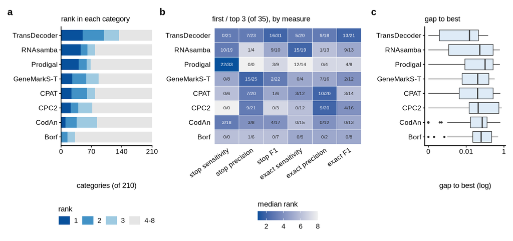

```r
tool_order <- rs_all$method
rank_bins <- rk %>% mutate(method = factor(RANK_TOOLS[tool], levels = rev(tool_order)),
                           bin = cut(rank, c(0, 1, 2, 3, 8), labels = c("1", "2", "3", "4-8"))) %>%
  count(method, bin)
pa <- ggplot(rank_bins, aes(n, method, fill = forcats::fct_rev(bin))) + geom_col(width = 0.75) +
  scale_fill_manual(values = c(`1` = "#08519c", `2` = "#4292c6", `3` = "#9ecae1", `4-8` = "#e5e5e5"),
                    breaks = c("1", "2", "3", "4-8"), name = "rank") +
  scale_x_continuous(expand = c(0, 0), breaks = c(0, 70, 140, 210)) +
  labs(x = sprintf("categories (of %d)", n_cat), y = NULL, title = "rank in each category")
heat_r <- rs_measure %>% mutate(method = factor(RANK_TOOLS[tool], levels = rev(tool_order)),
                                measure = factor(RANK_MEASURES[measure], levels = RANK_MEASURES))
pb <- ggplot(heat_r, aes(measure, method, fill = median_rank)) + geom_tile(colour = "white") +
  geom_text(aes(label = sprintf("%d/%d", first, top3)), size = 1.55,
            colour = ifelse(heat_r$median_rank <= 3, "white", "#222222")) +
  scale_fill_gradient(low = "#08519c", high = "#f0f0f0", limits = c(1, 8), name = "median rank") +
  labs(x = NULL, y = NULL, title = "first / top 3 (of 35), by measure") +
  theme(axis.text.x = element_text(angle = 35, hjust = 1), axis.line = element_blank(), axis.ticks = element_blank())
pc <- ggplot(rk %>% mutate(method = factor(RANK_TOOLS[tool], levels = rev(tool_order))),
             aes(pmax(gap, 1e-4), method)) +
  geom_boxplot(outlier.size = 0.3, linewidth = 0.25, fill = "#deebf7") +
  scale_x_log10(breaks = c(1e-4, 1e-2, 1), labels = c("0", "0.01", "1")) +
  labs(x = "gap to best (log)", y = NULL, title = "gap to best")
figS4 <- (pa + pb + pc) + plot_layout(widths = c(0.9, 1.5, 0.8)) + plot_annotation(tag_levels = "a") &
  theme(legend.position = "bottom", legend.title.position = "top", legend.key.width = unit(4, "mm"))
save_fig(figS4, "figS4_rankings", FULL_W, 70 * MM)
figS4
```

## Release versus earlier final defaults

```r
both <- function(f) c(earlier = f(TD_OLD), release = f(TD))
rv <- bind_rows(
  tibble(quantity = "complete stop F1 median", !!!both(function(t) MED(t, "complete", "f1_stop"))),
  tibble(quantity = "complete stop F1 min", !!!both(function(t) min(V(t, "complete", "f1_stop")))),
  tibble(quantity = "complete stop F1 max", !!!both(function(t) max(V(t, "complete", "f1_stop")))),
  tibble(quantity = "complete exact F1 median", !!!both(function(t) MED(t, "complete", "f1_exact"))),
  tibble(quantity = "complete exact F1 min", !!!both(function(t) min(V(t, "complete", "f1_exact")))),
  tibble(quantity = "complete exact F1 max", !!!both(function(t) max(V(t, "complete", "f1_exact")))),
  tibble(quantity = "fragments stop F1 median", !!!both(function(t) MED(t, "fragments", "f1_stop"))),
  tibble(quantity = "fragments exact F1 median", !!!both(function(t) MED(t, "fragments", "f1_exact"))),
  tibble(quantity = "complete+rand precision median", !!!both(function(t) MED(t, "complete.wRand", "precision_stop"))),
  tibble(quantity = "complete+rand precision min", !!!both(function(t) min(V(t, "complete.wRand", "precision_stop")))),
  tibble(quantity = "complete+rand stop F1 median", !!!both(function(t) MED(t, "complete.wRand", "f1_stop"))),
  tibble(quantity = "T. the. complete stop F1", !!!both(function(t) TT(t, "complete", "f1_stop"))),
  tibble(quantity = "T. the. complete exact F1", !!!both(function(t) TT(t, "complete", "f1_exact"))),
  tibble(quantity = "T. the. fragments stop F1", !!!both(function(t) TT(t, "fragments", "f1_stop"))),
  tibble(quantity = "T. the. complete+rand precision", !!!both(function(t) TT(t, "complete.wRand", "precision_stop"))),
  tibble(quantity = "P. fal. complete stop F1", !!!both(function(t) V(t, "complete", "f1_stop")[["pfalciparum"]])),
  tibble(quantity = "P. fal. complete exact F1", !!!both(function(t) V(t, "complete", "f1_exact")[["pfalciparum"]])),
  tibble(quantity = "C. rei. complete stop F1", !!!both(function(t) V(t, "complete", "f1_stop")[["creinhardtii"]])),
  tibble(quantity = "C. rei. complete exact F1", !!!both(function(t) V(t, "complete", "f1_exact")[["creinhardtii"]])),
  tibble(quantity = "max |TD - v6.0.0|, complete stop F1",
         !!!both(function(t) max(abs(V(t, "complete", "f1_stop") - v6_cs)))),
  tibble(quantity = "organisms where Prodigal > TD, fragments stop F1",
         !!!both(function(t) sum(pr_fs > V(t, "fragments", "f1_stop")))),
  tibble(quantity = "organisms where TD > Prodigal, fragments exact F1",
         !!!both(function(t) sum(V(t, "fragments", "f1_exact") > pr_fe))))
kable(rv %>% mutate(across(c(earlier, release), ~ round(.x, 3))))
```

| quantity | earlier | release |
| --- | --- | --- |
| complete stop F1 median | 0.978 | 0.980 |
| complete stop F1 min | 0.940 | 0.933 |
| complete stop F1 max | 0.988 | 0.997 |
| complete exact F1 median | 0.910 | 0.912 |
| complete exact F1 min | 0.742 | 0.747 |
| complete exact F1 max | 0.928 | 0.940 |
| fragments stop F1 median | 0.895 | 0.930 |
| fragments exact F1 median | 0.789 | 0.822 |
| complete+rand precision median | 0.993 | 0.994 |
| complete+rand precision min | 0.954 | 0.980 |
| complete+rand stop F1 median | 0.975 | 0.979 |
| T. the. complete stop F1 | 0.940 | 0.933 |
| T. the. complete exact F1 | 0.840 | 0.833 |
| T. the. fragments stop F1 | 0.896 | 0.887 |
| T. the. complete+rand precision | 0.954 | 0.980 |
| P. fal. complete stop F1 | 0.985 | 0.997 |
| P. fal. complete exact F1 | 0.928 | 0.940 |
| C. rei. complete stop F1 | 0.968 | 0.975 |
| C. rei. complete exact F1 | 0.742 | 0.747 |
| max \|TD - v6.0.0\|, complete stop F1 | 0.008 | 0.014 |
| organisms where Prodigal > TD, fragments stop F1 | 7.000 | 5.000 |
| organisms where TD > Prodigal, fragments exact F1 | 3.000 | 5.000 |

```r
old_better_exact <- names(which(V(TD_OLD, "fragments", "f1_exact") > pr_fe))
```

Earlier runs, fragments exact F1 higher than Prodigal in: T. thermophila, M. musculus, H. sapiens; release: T. thermophila, S. pombe, D. melanogaster, M. musculus, H. sapiens.

## Simulated GM12878 Trinity assembly

A benchmark on assembled transcripts whose true coding regions are known (E30; scripts `pipeline/simtrinity/`, tables `data/simtrinity/`). Reads were simulated from annotated transcripts only, at GM12878 expression levels, and assembled with the pipeline used for the real GM12878 Trinity assembly (E11). So the input has the fragment, isoform and chimera structure of a real genome-guided Trinity assembly, while every contig can be traced to its source transcript.

- **Transcripts simulated:** GENCODE v50 `protein_coding` transcripts with a complete CDS (no `*_NF` tags; ATG to stop, a whole number of codons, no internal stop) and all `lncRNA` transcripts. Nothing else: no pre-mRNA, retained-intron, NMD or pseudogene transcripts.
- **Expression:** salmon 1.10.3 counts (`ISR`, `--seqBias --gcBias`, full GENCODE v50 index) from the real reads (ENCSR000AED rep 1); the rounded counts of the kept transcripts are simulated.
- **Reads:** Polyester 1.38.0, paired 101 nt, `illumina5` errors, fragment length from salmon, stranded with read 1 antisense (dUTP/RF, as the real library).
- **Assembly:** STAR 2-pass (same index and parameters as the real run; run on methods02 for memory), Trinity 2.15.2 genome-guided (`--SS_lib_type RF --min_kmer_cov 2`), minimap2 `splice:hq` to GRCh38.
- **Labels** (`label_assembly.py`): a contig is compatible with a simulated transcript when their exons agree over the overlap (same introns; up to 10 nt of terminal overhang tolerated). The source CDS is projected onto compatible contigs, which are labelled complete, 5’ partial, 3’ partial or internal from the CDS ends they contain; contigs compatible only with lncRNAs and overlapping no GENCODE CDS are negatives. Contigs with conflicting projections (ambiguous), fewer than 50 codons (short) or no resolvable structure (unresolved) stay in the input, but predictions on them are not scored.
- **Scoring:** as for the other inputs (`score_predictions.py`): stop within 2 nt, exact when the start is also within 2 nt, one credit per truth CDS; every prediction on a negative is a false positive. The input is named `fragments_simtrinity.fa`, so `run_tool.sh` treats it as stranded and as fragments (RNAsamba partial-length weights); CPAT uses the human model. CodAn was not run (too slow) and `perl_td_v7` was not run (identical to `pytd_v7` on all other inputs; E08, E25).

```r
ST <- function(f) read_tab("simtrinity", f)
sim_par <- ST("sim_params.tsv") %>% { setNames(.[[2]], .[[1]]) }
sim_sel <- read_tsv(data_path("simtrinity", "selection_counts.tsv"), col_names = c("step", "n"), show_col_types = FALSE)
SEL <- setNames(sim_sel$n, sim_sel$step)
asm <- ST("assembly_stats.tsv")
ASM <- function(m, w = "simulated") asm[[w]][asm$metric == m]
LC <- ST("label_counts.tsv")
lc_n <- function(a, l) sum(LC$n[LC$assembly == a & LC$label %in% l])
SCORED_TYPES <- c("complete", "5prime_partial", "3prime_partial", "internal")
lab_tab <- LC %>% mutate(group = case_when(label %in% SCORED_TYPES ~ "coding (truth)", label == "noncoding" ~ "negative",
                                           TRUE ~ "not scored")) %>%
  group_by(assembly, group, label) %>% summarise(n = sum(n), .groups = "drop") %>%
  group_by(assembly) %>% mutate(frac = n / sum(n)) %>% ungroup()
kable(tibble(step = c("coding transcripts kept (complete CDS)", "lncRNA transcripts", "salmon pairs assigned (real reads)",
                      "simulated pairs (kept transcripts)", "  of which coding / lncRNA", "fragment length mean / sd",
                      "STAR uniquely mapped", "Trinity transcripts (simulated / real)", "Trinity 'genes' (simulated / real)",
                      "contigs with a primary alignment (simulated / real)"),
             value = c(num(SEL[["coding_kept"]]), num(SEL[["lncRNA"]]), num(as.numeric(sim_par[["salmon_num_mapped"]])),
                       num(as.numeric(sim_par[["pairs_total"]])),
                       paste(num(as.numeric(sim_par[["pairs_coding"]])), "/", num(as.numeric(sim_par[["pairs_lncRNA"]]))),
                       paste(sim_par[["fld_mean"]], "/", sim_par[["fld_sd"]]), paste0(ASM("star_unique_pct"), "%"),
                       paste(num(ASM("trinity_transcripts")), "/", num(ASM("trinity_transcripts", "real"))),
                       paste(num(ASM("trinity_genes")), "/", num(ASM("trinity_genes", "real"))),
                       paste(num(ASM("minimap2_primary_mapped")), "/", num(ASM("minimap2_primary_mapped", "real"))))),
      caption = "Simulation and assembly")
```

Simulation and assembly

| step | value |
| --- | --- |
| coding transcripts kept (complete CDS) | 252,930 |
| lncRNA transcripts | 191,362 |
| salmon pairs assigned (real reads) | 73,798,725 |
| simulated pairs (kept transcripts) | 52,753,990 |
| of which coding / lncRNA | 49,865,569 / 2,888,421 |
| fragment length mean / sd | 215.43 / 24.09 |
| STAR uniquely mapped | 96.84% |
| Trinity transcripts (simulated / real) | 84,972 / 428,960 |
| Trinity ‘genes’ (simulated / real) | 46,339 / 319,068 |
| contigs with a primary alignment (simulated / real) | 84,838 / 428,223 |

```r
sg <- ST("strand_check_genome.tsv") %>% filter(mapping == "unique")
r1_anti <- sum(sg$n[sg$read == "R1" & sg$alignment_strand_vs_source == "opposite"]) / sum(sg$n[sg$read == "R1"])
```

**Strand.** In a 1% sample of the STAR alignments, uniquely mapped read 1 lies on the strand opposite its source transcript in 99.97% of 510,704 reads (RF, as the real library).

**Labels.** The real GM12878 Trinity assembly was labelled with the same script against the same transcript set, for comparison (its contigs come from all transcripts, pre-mRNA and unannotated isoforms, so most are unresolved there).

```r
kable(lab_tab %>% select(assembly, group, label, n) %>%
        pivot_wider(names_from = assembly, values_from = n, values_fill = 0) %>%
        mutate(simulated_frac = r3(simulated / sum(simulated)), real_frac = r3(real / sum(real))),
      caption = "Contig labels, simulated vs real Trinity GG assembly")
```

Contig labels, simulated vs real Trinity GG assembly

| group | label | real | simulated | simulated_frac | real_frac |
| --- | --- | --- | --- | --- | --- |
| coding (truth) | 3prime_partial | 2329 | 1579 | 0.019 | 0.005 |
| coding (truth) | 5prime_partial | 2283 | 1454 | 0.017 | 0.005 |
| coding (truth) | complete | 15489 | 28187 | 0.332 | 0.036 |
| coding (truth) | internal | 2714 | 2719 | 0.032 | 0.006 |
| negative | noncoding | 13316 | 20815 | 0.245 | 0.031 |
| not scored | ambiguous | 805 | 590 | 0.007 | 0.002 |
| not scored | short_complete | 303 | 498 | 0.006 | 0.001 |
| not scored | short_partial | 2016 | 1464 | 0.017 | 0.005 |
| not scored | unresolved | 389705 | 27666 | 0.326 | 0.908 |

```r
details(LC %>% filter(label %in% c("unresolved", "ambiguous")) %>%
          pivot_wider(names_from = assembly, values_from = n, values_fill = 0), "unresolved and ambiguous by reason")
```

**unresolved and ambiguous by reason**

| label | reason | simulated | real |
| --- | --- | --- | --- |
| ambiguous | 2_projections | 559 | 748 |
| ambiguous | 3_projections | 31 | 55 |
| unresolved | chimeric | 464 | 6361 |
| unresolved | frame_check_failed | 31 | 1270 |
| unresolved | incompatible | 12137 | 311753 |
| unresolved | large_softclip | 483 | 12141 |
| unresolved | lnc_overlaps_cds | 92 | 407 |
| unresolved | no_overlap | 595 | 29739 |
| unresolved | softclip_at_open_cds_end | 283 | 539 |
| unresolved | unaligned | 134 | 737 |
| unresolved | utr_only | 13447 | 26750 |
| ambiguous | 4_projections | 0 | 2 |
| unresolved | cds_end_in_deletion | 0 | 8 |

```r
details(ST("incompatible_breakdown.tsv"), "simulated: why contigs are structurally incompatible")
```

**simulated: why contigs are structurally incompatible**

| category | n |
| --- | --- |
| known_introns_new_combination | 6033 |
| introns_ok_exon_diff>10nt(retained/extended_end) | 3322 |
| novel_intron(1) | 1644 |
| terminal_diff_le10nt | 818 |
| novel_intron(2+) | 320 |

```r
pos_types <- function(a) { d <- LC %>% filter(assembly == a, label %in% SCORED_TYPES); setNames(d$n / sum(d$n), d$label) }
E29T <- ST("e29_five_prime.tsv")
n_unres_sim <- lc_n("simulated", "unresolved"); n_sim <- sum(LC$n[LC$assembly == "simulated"])
```

Of 84,972 simulated contigs, 33,939 carry a scored CDS, 20,815 are negatives and 27,666 (32.6%) are unresolved. The two largest unresolved groups are contigs compatible with coding transcripts but holding only UTR sequence (13,447) and contigs whose intron chain matches no single simulated transcript (12,137; half of them annotated introns joined in new combinations by the assembler). Among the scored contigs, 83.1% are complete in the simulated assembly against 67.9% in the real one. The E29 statistic (contigs carrying a MANE Select stop with the reference structure to their 5’ end that begin inside the CDS) is 7.0% simulated vs 13.6% real: the simulated assembly is more complete than the real one (uniform coverage, no pre-mRNA, no degradation).

```r
TBE <- ST("type_by_expr.tsv"); CBS <- ST("complete_by_source_expr.tsv")
TPM_BINS <- c("<1", "1-5", "5-20", "20-100", ">100")
kable(TBE %>% select(-n) %>% mutate(frac = r3(frac), tpm_bin = factor(tpm_bin, TPM_BINS)) %>%
        pivot_wider(names_from = type, values_from = frac) %>%
        left_join(TBE %>% group_by(tpm_bin) %>% summarise(contigs = sum(n)), by = "tpm_bin") %>% arrange(tpm_bin),
      caption = "Scored contigs by salmon TPM of the source transcript(s): fraction of each type")
```

Scored contigs by salmon TPM of the source transcript(s): fraction of each type

| tpm_bin | complete | 5prime_partial | 3prime_partial | internal | contigs |
| --- | --- | --- | --- | --- | --- |
| 1-5 | 0.955 | 0.018 | 0.021 | 0.006 | 9856 |
| 20-100 | 0.951 | 0.011 | 0.013 | 0.025 | 2175 |
| 5-20 | 0.962 | 0.010 | 0.014 | 0.015 | 4697 |
| <1 | 0.704 | 0.071 | 0.076 | 0.150 | 16562 |
| >100 | 0.826 | 0.045 | 0.046 | 0.083 | 649 |

```r
kable(CBS %>% mutate(across(starts_with("frac"), r3)),
      caption = "Simulated coding transcripts by TPM: with >= 1 complete contig, with >= 1 scored contig")
```

Simulated coding transcripts by TPM: with >= 1 complete contig, with >= 1 scored contig

| tpm_bin | n_coding_simulated | with_complete_contig | frac_complete | with_scored_contig | frac_scored |
| --- | --- | --- | --- | --- | --- |
| <1 | 44621 | 8853 | 0.198 | 13202 | 0.296 |
| 1-5 | 14096 | 10090 | 0.716 | 10556 | 0.749 |
| 5-20 | 5671 | 4773 | 0.842 | 4875 | 0.860 |
| 20-100 | 2349 | 2075 | 0.883 | 2116 | 0.901 |
| >100 | 572 | 474 | 0.829 | 491 | 0.858 |

**Accuracy.** Predictions on unresolved, ambiguous and short contigs are removed before scoring (counted in `n_pred_excluded`).

```r
SIM_TOOLS <- c(pytd_v7 = "TransDecoder", perl_td_v600 = "TransDecoder v6.0.0", longest_orf = "longest ORF",
               prodigal = "Prodigal", gmst = "GeneMarkS-T", cpat = "CPAT", rnasamba = "RNAsamba", cpc2 = "CPC2",
               borf = "Borf")
so <- ST("scores_overall.tsv") %>% mutate(method = factor(SIM_TOOLS[tool], levels = SIM_TOOLS)) %>% arrange(method)
neg <- ST("negatives.tsv")
kable(so %>% left_join(neg %>% select(tool, frac_negatives_with_pred), by = "tool") %>%
        transmute(method, n_truth, n_pred, sensitivity_stop, precision_stop, f1_stop, sensitivity_exact,
                  precision_exact, f1_exact, negatives_with_pred = frac_negatives_with_pred, n_pred_excluded) %>%
        mutate(across(where(is.double), r3)),
      caption = "Simulated Trinity assembly: all scored contigs")
```

Simulated Trinity assembly: all scored contigs

| method | n_truth | n_pred | sensitivity_stop | precision_stop | f1_stop | sensitivity_exact | precision_exact | f1_exact | negatives_with_pred | n_pred_excluded |
| --- | --- | --- | --- | --- | --- | --- | --- | --- | --- | --- |
| TransDecoder | 33939 | 32664 | 0.899 | 0.934 | 0.916 | 0.828 | 0.861 | 0.844 | 0.081 | 9918 |
| TransDecoder v6.0.0 | 33939 | 41059 | 0.893 | 0.738 | 0.808 | 0.742 | 0.613 | 0.671 | 0.175 | 14387 |
| longest ORF | 33939 | 48626 | 0.948 | 0.661 | 0.779 | 0.695 | 0.485 | 0.571 | 0.706 | 21392 |
| Prodigal | 33939 | 71439 | 0.978 | 0.465 | 0.630 | 0.704 | 0.334 | 0.453 | 0.518 | 28819 |
| GeneMarkS-T | 33939 | 35272 | 0.890 | 0.856 | 0.873 | 0.700 | 0.674 | 0.687 | 0.208 | 11751 |
| CPAT | 33939 | 33004 | 0.888 | 0.914 | 0.901 | 0.788 | 0.811 | 0.799 | 0.112 | 10260 |
| RNAsamba | 33939 | 34068 | 0.902 | 0.898 | 0.900 | 0.788 | 0.785 | 0.787 | 0.117 | 10579 |
| CPC2 | 33939 | 28481 | 0.776 | 0.925 | 0.844 | 0.718 | 0.856 | 0.781 | 0.074 | 8911 |
| Borf | 33939 | 34568 | 0.865 | 0.849 | 0.857 | 0.730 | 0.716 | 0.723 | 0.197 | 11656 |

```r
sbt <- ST("scores_by_type.tsv") %>% mutate(method = factor(SIM_TOOLS[tool], levels = SIM_TOOLS),
                                          type = factor(TYPE_LABEL[type], levels = TYPE_LABEL))
kable(sbt %>% transmute(method, type, v = sprintf("%.3f / %.3f", sensitivity_stop, sensitivity_exact)) %>%
        pivot_wider(names_from = type, values_from = v) %>% arrange(method),
      caption = "Sensitivity by type, stop / exact")
```

Sensitivity by type, stop / exact

| method | complete | 5’ partial | 3’ partial | internal |
| --- | --- | --- | --- | --- |
| TransDecoder | 0.922 / 0.859 | 0.717 / 0.574 | 0.819 / 0.751 | 0.800 / 0.689 |
| TransDecoder v6.0.0 | 0.943 / 0.780 | 0.672 / 0.607 | 0.772 / 0.541 | 0.569 / 0.537 |
| longest ORF | 0.949 / 0.665 | 0.875 / 0.875 | 0.908 / 0.535 | 1.000 / 1.000 |
| Prodigal | 0.981 / 0.672 | 0.924 / 0.922 | 0.958 / 0.586 | 0.985 / 0.984 |
| GeneMarkS-T | 0.939 / 0.727 | 0.682 / 0.649 | 0.762 / 0.527 | 0.564 / 0.551 |
| CPAT | 0.943 / 0.901 | 0.576 / 0.011 | 0.868 / 0.827 | 0.505 / 0.013 |
| RNAsamba | 0.941 / 0.900 | 0.583 / 0.012 | 0.892 / 0.849 | 0.672 / 0.015 |
| CPC2 | 0.889 / 0.849 | 0.472 / 0.010 | 0.286 / 0.272 | 0.051 / 0.001 |
| Borf | 0.924 / 0.806 | 0.565 / 0.252 | 0.744 / 0.612 | 0.480 / 0.265 |

```r
sbe <- ST("scores_by_expr.tsv") %>% mutate(method = factor(SIM_TOOLS[tool], levels = SIM_TOOLS),
                                          tpm_bin = factor(tpm_bin, TPM_BINS))
kable(sbe %>% transmute(method, tpm_bin, v = sprintf("%.3f / %.3f", sensitivity_stop, sensitivity_exact)) %>%
        pivot_wider(names_from = tpm_bin, values_from = v) %>% arrange(method),
      caption = "Sensitivity by TPM of the source transcript(s), stop / exact")
```

Sensitivity by TPM of the source transcript(s), stop / exact

| method | <1 | 1-5 | 5-20 | 20-100 | >100 |
| --- | --- | --- | --- | --- | --- |
| TransDecoder | 0.883 / 0.801 | 0.904 / 0.840 | 0.937 / 0.879 | 0.925 / 0.874 | 0.860 / 0.818 |
| TransDecoder v6.0.0 | 0.853 / 0.721 | 0.931 / 0.763 | 0.953 / 0.783 | 0.924 / 0.752 | 0.807 / 0.606 |
| longest ORF | 0.946 / 0.743 | 0.944 / 0.660 | 0.964 / 0.647 | 0.945 / 0.614 | 0.948 / 0.635 |
| Prodigal | 0.975 / 0.753 | 0.978 / 0.665 | 0.986 / 0.651 | 0.980 / 0.629 | 0.992 / 0.669 |
| GeneMarkS-T | 0.849 / 0.685 | 0.927 / 0.713 | 0.948 / 0.731 | 0.923 / 0.719 | 0.814 / 0.623 |
| CPAT | 0.846 / 0.693 | 0.922 / 0.870 | 0.949 / 0.906 | 0.935 / 0.893 | 0.858 / 0.777 |
| RNAsamba | 0.870 / 0.693 | 0.926 / 0.873 | 0.950 / 0.904 | 0.938 / 0.886 | 0.895 / 0.790 |
| CPC2 | 0.693 / 0.618 | 0.858 / 0.812 | 0.886 / 0.850 | 0.842 / 0.810 | 0.624 / 0.592 |
| Borf | 0.818 / 0.667 | 0.909 / 0.784 | 0.933 / 0.816 | 0.898 / 0.794 | 0.755 / 0.670 |

```r
ex <- ST("excluded_preds.tsv")
details(ex %>% mutate(frac_with_pred = r3(frac_with_pred)) %>% select(tool, label, n_transcripts, with_pred, frac_with_pred) %>%
          pivot_wider(id_cols = c(label, n_transcripts), names_from = tool, values_from = frac_with_pred),
        "fraction of excluded contigs with a prediction, by label / reason")
```

**fraction of excluded contigs with a prediction, by label / reason**

| label | n_transcripts | pytd_v7 | perl_td_v600 | prodigal | gmst | cpat | cpc2 | rnasamba | borf | longest_orf |
| --- | --- | --- | --- | --- | --- | --- | --- | --- | --- | --- |
| ambiguous | 590 | 0.803 | 0.758 | 0.929 | 0.758 | 0.756 | 0.632 | 0.803 | 0.737 | 0.959 |
| short_complete | 498 | 0.189 | 0.301 | 0.761 | 0.317 | 0.285 | 0.120 | 0.299 | 0.291 | 0.904 |
| short_partial | 1464 | 0.032 | 0.063 | 0.414 | 0.076 | 0.058 | 0.016 | 0.097 | 0.083 | 0.555 |
| unresolved:chimeric | 464 | 0.466 | 0.547 | 0.737 | 0.584 | 0.491 | 0.448 | 0.453 | 0.578 | 0.899 |
| unresolved:frame_check_failed | 31 | 0.871 | 0.871 | 1.000 | 0.871 | 0.839 | 0.710 | 0.839 | 0.871 | 0.968 |
| unresolved:incompatible | 12137 | 0.680 | 0.743 | 0.882 | 0.765 | 0.705 | 0.635 | 0.708 | 0.755 | 0.947 |
| unresolved:large_softclip | 483 | 0.497 | 0.613 | 0.795 | 0.669 | 0.559 | 0.501 | 0.520 | 0.642 | 0.901 |
| unresolved:lnc_overlaps_cds | 92 | 0.543 | 0.620 | 0.870 | 0.630 | 0.587 | 0.522 | 0.565 | 0.630 | 0.935 |
| unresolved:no_overlap | 595 | 0.150 | 0.128 | 0.482 | 0.136 | 0.104 | 0.027 | 0.158 | 0.123 | 0.595 |
| unresolved:softclip_at_open_cds_end | 283 | 0.746 | 0.618 | 0.944 | 0.625 | 0.565 | 0.173 | 0.724 | 0.534 | 0.972 |
| unresolved:unaligned | 134 | 0.045 | 0.015 | 0.664 | 0.022 | 0.015 | 0.000 | 0.015 | 0.007 | 0.724 |
| unresolved:utr_only | 13447 | 0.016 | 0.053 | 0.256 | 0.059 | 0.017 | 0.012 | 0.028 | 0.063 | 0.474 |

```r
pt_sim <- ST("pred_types.tsv")
details(pt_sim %>% filter(scope == "scored") %>% mutate(method = SIM_TOOLS[tool]) %>%
          select(method, n_pred, ends_with("_frac")) %>% mutate(across(ends_with("_frac"), r3)),
        "predicted ORF types (from each prediction's own ends), scored contigs")
```

**predicted ORF types (from each prediction’s own ends), scored contigs**

| method | n_pred | complete_frac | 5prime_partial_frac | 3prime_partial_frac | internal_frac |
| --- | --- | --- | --- | --- | --- |
| TransDecoder | 32664 | 0.826 | 0.058 | 0.054 | 0.062 |
| TransDecoder v6.0.0 | 41059 | 0.744 | 0.172 | 0.036 | 0.048 |
| Prodigal | 71439 | 0.556 | 0.342 | 0.048 | 0.054 |
| GeneMarkS-T | 35272 | 0.721 | 0.189 | 0.035 | 0.056 |
| CPAT | 33004 | 0.906 | 0.000 | 0.094 | 0.000 |
| CPC2 | 28481 | 0.979 | 0.000 | 0.021 | 0.000 |
| RNAsamba | 34068 | 0.891 | 0.000 | 0.108 | 0.000 |
| Borf | 34568 | 0.811 | 0.102 | 0.058 | 0.030 |
| longest ORF | 48626 | 0.546 | 0.329 | 0.040 | 0.086 |

```r
SOV <- function(t, m) so[[m]][so$tool == t]
NEGV <- function(t) neg$frac_negatives_with_pred[neg$tool == t]
```

TransDecoder: stop-level F1 0.916, exact F1 0.844, with a prediction on 8.1% of the lncRNA-derived negatives. Prodigal finds more stops (sensitivity 0.978) but predicts on 51.8% of the negatives (exact F1 0.453); the longest-ORF baseline predicts on 70.6% of them. CPAT and RNAsamba reach stop F1 0.901 and 0.900 but cannot leave a 5’ end open (exact sensitivity on 5’ partials and internal fragments below 0.02).

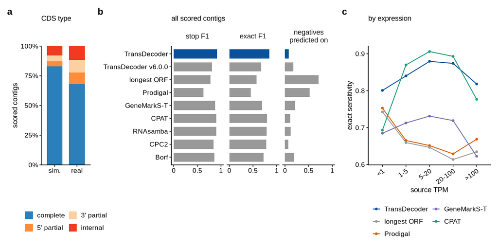

```r
SIM_TYPE_LAB <- c(complete = "complete", `5prime_partial` = "5' partial", `3prime_partial` = "3' partial",
                  internal = "internal")
TYPE_COL <- c(complete = COMPLETE_C, `5' partial` = "#fd8d3c", `3' partial` = "#fdd0a2", internal = FRAG_C)
pa <- LC %>% filter(label %in% SCORED_TYPES) %>% group_by(assembly) %>% mutate(frac = n / sum(n)) %>% ungroup() %>%
  mutate(type = factor(SIM_TYPE_LAB[label], levels = rev(SIM_TYPE_LAB)),
         assembly = factor(assembly, c("simulated", "real"), c("sim.", "real"))) %>%
  ggplot(aes(assembly, frac, fill = type)) + geom_col(width = 0.7) +
  scale_fill_manual(values = TYPE_COL, breaks = unname(SIM_TYPE_LAB), name = NULL) +
  scale_y_continuous(expand = c(0, 0), labels = percent) + labs(x = NULL, y = "scored contigs", title = "CDS type") +
  guides(fill = guide_legend(ncol = 2))
pb <- so %>% left_join(neg, by = "tool") %>% select(method, f1_stop, f1_exact, frac_negatives_with_pred) %>%
  pivot_longer(-method) %>%
  mutate(name = factor(name, c("f1_stop", "f1_exact", "frac_negatives_with_pred"),
                       c("stop F1", "exact F1", "negatives\npredicted on")), method = factor(method, rev(SIM_TOOLS))) %>%
  ggplot(aes(value, method, fill = method == "TransDecoder")) + geom_col(width = 0.7) + facet_wrap(~name, nrow = 1) +
  scale_fill_manual(values = c(`TRUE` = TD_C, `FALSE` = GREY), guide = "none") +
  scale_x_continuous(breaks = c(0, 0.5, 1), labels = c("0", "0.5", "1"), limits = c(0, 1)) +
  labs(x = NULL, y = NULL, title = "all scored contigs")
pc <- sbe %>% filter(tool %in% c(TD, "prodigal", "gmst", "cpat", "longest_orf")) %>%
  ggplot(aes(tpm_bin, sensitivity_exact, colour = method, group = method)) + geom_line(linewidth = 0.4) + geom_point(size = 0.8) +
  scale_colour_manual(values = c(TransDecoder = TD_C, Prodigal = "#d95f02", `GeneMarkS-T` = "#7570b3", CPAT = "#1b9e77",
                                 `longest ORF` = GREY), name = NULL) +
  labs(x = "source TPM", y = "exact sensitivity", title = "by expression") +
  theme(axis.text.x = element_text(angle = 35, hjust = 1)) + guides(colour = guide_legend(ncol = 2))
figS_sim <- (pa + pb + pc) + plot_layout(widths = c(0.6, 2, 1.5)) + plot_annotation(tag_levels = "a") &
  theme(legend.position = "bottom")
save_fig(figS_sim, "figS_simtrinity", FULL_W, 85 * MM)
figS_sim
```

### Read-depth ablation

At full depth the simulated assembly is mostly complete CDSs (above), so partial CDSs are few. To get more partial contigs, the E30 STAR alignments were subsampled by read pair to 1/2, 1/4, … of the pairs (`samtools view --subsample`, one seed, so the levels are nested), and each level was assembled, labelled, run and scored exactly as at full depth (E31; scripts `11_depth_subsample.sh`, `08b_trinity_gg_level.sh`, `12_depth_label_and_run.sh`, `13_depth_collect.py`; tables `data/simtrinity/depth/`). STAR was not re-run, so the two-pass junctions come from the full read set (they are annotated junctions anyway).

```r
DP <- function(f) read_tab("simtrinity", "depth", f)
dlev <- DP("levels.tsv") %>% mutate(fraction = as.numeric(fraction))
LEV_LAB <- setNames(ifelse(dlev$fraction == 1, "1", paste0("1/", round(1 / dlev$fraction))), dlev$level)
dtc <- DP("truth_counts.tsv") %>% mutate(reads = LEV_LAB[level])
kable(dlev %>% transmute(level, `read pairs` = num(as.numeric(pairs)), `observed fraction` = observed_fraction,
                         `Trinity transcripts` = num(trinity_transcripts)) %>%
        left_join(dtc %>% select(level, complete, `5' partial` = `5prime_partial`, `3' partial` = `3prime_partial`, internal,
                                 truth = truth_total, negatives, unresolved), by = "level"),
      caption = "Depth levels: read pairs, assembly size and labels")
```

Depth levels: read pairs, assembly size and labels

| level | read pairs | observed fraction | Trinity transcripts | complete | 5’ partial | 3’ partial | internal | truth | negatives | unresolved |
| --- | --- | --- | --- | --- | --- | --- | --- | --- | --- | --- |
| d1 | 52,633,605 | 1.00000 | 84,972 | 28187 | 1454 | 1579 | 2719 | 33939 | 20815 | 27666 |
| d2 | 26,320,005 | 0.50006 | 70,277 | 22864 | 1488 | 1572 | 2667 | 28591 | 15054 | 24469 |
| d4 | 13,160,759 | 0.25004 | 56,018 | 17188 | 1610 | 1786 | 3205 | 23789 | 9913 | 20319 |
| d8 | 6,581,285 | 0.12504 | 44,871 | 11615 | 1926 | 1973 | 4646 | 20160 | 5885 | 16963 |
| d16 | 3,291,032 | 0.06253 | 36,052 | 7039 | 2096 | 1920 | 6402 | 17457 | 3267 | 13529 |
| d32 | 1,646,007 | 0.03127 | 26,744 | 3889 | 1839 | 1531 | 6587 | 13846 | 1594 | 9634 |

```r
# shares from the counts (not from the rounded share_* columns), rounded once for display
dsh <- dtc %>% transmute(reads, s_c = complete / truth_total, s_5 = `5prime_partial` / truth_total,
                         s_3 = `3prime_partial` / truth_total, s_i = internal / truth_total)
kable(dsh %>% transmute(reads, complete = pct(s_c), `5' partial` = pct(s_5), `3' partial` = pct(s_3), internal = pct(s_i),
                        `largest change from previous level (points)` =
                          c(NA, f1(100 * apply(abs(diff(as.matrix(select(dsh, -reads)))), 1, max)))),
      caption = "Share of each CDS type among the scored truth, by level (stop rule: every share changes by < 3 points)")
```

Share of each CDS type among the scored truth, by level (stop rule: every share changes by < 3 points)

| reads | complete | 5’ partial | 3’ partial | internal | largest change from previous level (points) |
| --- | --- | --- | --- | --- | --- |
| 1 | 83.1% | 4.3% | 4.7% | 8.0% | NA |
| 1/2 | 80.0% | 5.2% | 5.5% | 9.3% | 3.1 |
| 1/4 | 72.3% | 6.8% | 7.5% | 13.5% | 7.7 |
| 1/8 | 57.6% | 9.6% | 9.8% | 23.0% | 14.6 |
| 1/16 | 40.3% | 12.0% | 11.0% | 36.7% | 17.3 |
| 1/32 | 28.1% | 13.3% | 11.1% | 47.6% | 12.2 |

```r
de29 <- DP("e29_five_prime.tsv")
details(de29 %>% mutate(frac_5prime_partial = r3(frac_5prime_partial)), "E29 statistic by level")
```

**E29 statistic by level**

| level | n_with_mane_stop | n_5prime_partial | frac_5prime_partial |
| --- | --- | --- | --- |
| d1 | 16001 | 1116 | 0.070 |
| d2 | 13669 | 1146 | 0.084 |
| d4 | 11455 | 1423 | 0.124 |
| d8 | 9277 | 1933 | 0.208 |
| d16 | 7112 | 2244 | 0.316 |
| d32 | 5142 | 2256 | 0.439 |

```r
details(DP("label_counts.tsv") %>% pivot_wider(names_from = level, values_from = n, values_fill = 0),
        "all labels and reasons by level")
```

**all labels and reasons by level**

| label | reason | d1 | d2 | d4 | d8 | d16 | d32 |
| --- | --- | --- | --- | --- | --- | --- | --- |
| 3prime_partial | . | 1579 | 1572 | 1786 | 1973 | 1920 | 1531 |
| 5prime_partial | . | 1454 | 1488 | 1610 | 1926 | 2096 | 1839 |
| ambiguous | 2_projections | 559 | 517 | 529 | 545 | 589 | 575 |
| ambiguous | 3_projections | 31 | 31 | 36 | 39 | 38 | 51 |
| complete | . | 28187 | 22864 | 17188 | 11615 | 7039 | 3889 |
| internal | . | 2719 | 2667 | 3205 | 4646 | 6402 | 6587 |
| noncoding | . | 20815 | 15054 | 9913 | 5885 | 3267 | 1594 |
| short_complete | . | 498 | 375 | 256 | 144 | 81 | 52 |
| short_partial | . | 1464 | 1240 | 1174 | 1134 | 1090 | 991 |
| unresolved | chimeric | 464 | 335 | 166 | 117 | 56 | 22 |
| unresolved | frame_check_failed | 31 | 18 | 18 | 4 | 7 | 5 |
| unresolved | incompatible | 12137 | 8565 | 5209 | 2907 | 1287 | 575 |
| unresolved | large_softclip | 483 | 347 | 248 | 168 | 81 | 47 |
| unresolved | lnc_overlaps_cds | 92 | 71 | 48 | 27 | 20 | 12 |
| unresolved | no_overlap | 595 | 455 | 360 | 221 | 161 | 104 |
| unresolved | softclip_at_open_cds_end | 283 | 269 | 333 | 459 | 555 | 566 |
| unresolved | unaligned | 134 | 80 | 49 | 42 | 18 | 5 |
| unresolved | utr_only | 13447 | 14324 | 13888 | 13018 | 11343 | 8298 |
| unresolved | cds_end_in_deletion | 0 | 5 | 0 | 0 | 1 | 0 |
| ambiguous | 4_projections | 0 | 0 | 2 | 1 | 1 | 1 |

```r
dbt <- DP("scores_by_type.tsv") %>% mutate(method = factor(SIM_TOOLS[tool], levels = SIM_TOOLS),
                                          type = factor(SIM_TYPE_LAB[type], levels = SIM_TYPE_LAB),
                                          reads = factor(LEV_LAB[level], levels = LEV_LAB))
dov <- DP("scores_overall.tsv") %>% left_join(DP("negatives.tsv") %>% select(level, tool, frac_negatives_with_pred),
                                              by = c("level", "tool")) %>%
  mutate(method = factor(SIM_TOOLS[tool], levels = SIM_TOOLS), reads = factor(LEV_LAB[level], levels = LEV_LAB))
best_of <- function(col) dbt %>% filter(tool != TD) %>% group_by(reads, type) %>%
  slice_max(.data[[col]], n = 1, with_ties = FALSE) %>% ungroup() %>%
  transmute(reads, type, v = sprintf("%.3f (%s)", .data[[col]], method))
kable(dbt %>% filter(tool == TD) %>% transmute(reads, type, n_truth, `TransDecoder, with negatives` = r3(f1_exact_wneg)) %>%
        left_join(best_of("f1_exact_wneg") %>% rename(`best other, with negatives` = v), by = c("reads", "type")) %>%
        left_join(dbt %>% filter(tool == TD) %>% transmute(reads, type, `TransDecoder, truth only` = r3(f1_exact)),
                  by = c("reads", "type")) %>%
        left_join(best_of("f1_exact") %>% rename(`best other, truth only` = v), by = c("reads", "type")) %>%
        arrange(type, reads),
      caption = "Exact F1 by CDS type: TransDecoder vs the best other method. Precision counts the predictions on contigs of that type; 'with negatives' also counts predictions on negatives whose own ORF is of that type")
```

Exact F1 by CDS type: TransDecoder vs the best other method. Precision counts the predictions on contigs of that type; ‘with negatives’ also counts predictions on negatives whose own ORF is of that type

| reads | type | n_truth | TransDecoder, with negatives | best other, with negatives | TransDecoder, truth only | best other, truth only |
| --- | --- | --- | --- | --- | --- | --- |
| 1 | complete | 28187 | 0.869 | 0.888 (CPAT) | 0.887 | 0.920 (CPAT) |
| 1/2 | complete | 22864 | 0.875 | 0.899 (CPAT) | 0.893 | 0.928 (CPAT) |
| 1/4 | complete | 17188 | 0.884 | 0.913 (CPAT) | 0.899 | 0.938 (CPAT) |
| 1/8 | complete | 11615 | 0.886 | 0.923 (CPAT) | 0.901 | 0.945 (CPAT) |
| 1/16 | complete | 7039 | 0.894 | 0.932 (CPAT) | 0.906 | 0.953 (RNAsamba) |
| 1/32 | complete | 3889 | 0.891 | 0.941 (CPAT) | 0.900 | 0.958 (RNAsamba) |
| 1 | 5’ partial | 1454 | 0.599 | 0.455 (GeneMarkS-T) | 0.663 | 0.875 (longest ORF) |
| 1/2 | 5’ partial | 1488 | 0.587 | 0.536 (GeneMarkS-T) | 0.640 | 0.877 (longest ORF) |
| 1/4 | 5’ partial | 1610 | 0.639 | 0.611 (GeneMarkS-T) | 0.687 | 0.899 (longest ORF) |
| 1/8 | 5’ partial | 1926 | 0.676 | 0.707 (GeneMarkS-T) | 0.706 | 0.904 (longest ORF) |
| 1/16 | 5’ partial | 2096 | 0.724 | 0.749 (GeneMarkS-T) | 0.746 | 0.908 (longest ORF) |
| 1/32 | 5’ partial | 1839 | 0.732 | 0.808 (Prodigal) | 0.745 | 0.905 (longest ORF) |
| 1 | 3’ partial | 1579 | 0.776 | 0.796 (CPAT) | 0.823 | 0.892 (RNAsamba) |
| 1/2 | 3’ partial | 1572 | 0.816 | 0.826 (RNAsamba) | 0.855 | 0.926 (RNAsamba) |
| 1/4 | 3’ partial | 1786 | 0.826 | 0.858 (CPAT) | 0.858 | 0.935 (RNAsamba) |
| 1/8 | 3’ partial | 1973 | 0.837 | 0.893 (RNAsamba) | 0.862 | 0.940 (RNAsamba) |
| 1/16 | 3’ partial | 1920 | 0.845 | 0.904 (RNAsamba) | 0.864 | 0.943 (RNAsamba) |
| 1/32 | 3’ partial | 1531 | 0.831 | 0.904 (RNAsamba) | 0.849 | 0.945 (RNAsamba) |
| 1 | internal | 2719 | 0.747 | 0.872 (Prodigal) | 0.765 | 1.000 (longest ORF) |
| 1/2 | internal | 2667 | 0.743 | 0.881 (Prodigal) | 0.760 | 1.000 (longest ORF) |
| 1/4 | internal | 3205 | 0.742 | 0.905 (Prodigal) | 0.756 | 1.000 (longest ORF) |
| 1/8 | internal | 4646 | 0.748 | 0.951 (longest ORF) | 0.754 | 1.000 (longest ORF) |
| 1/16 | internal | 6402 | 0.771 | 0.973 (longest ORF) | 0.776 | 1.000 (longest ORF) |
| 1/32 | internal | 6587 | 0.768 | 0.982 (longest ORF) | 0.773 | 1.000 (longest ORF) |

```r
details(DP("neg_pred_types.tsv") %>% mutate(reads = LEV_LAB[level], method = SIM_TOOLS[tool]) %>%
          select(reads, method, n_pred_on_negatives, all_of(SCORED_TYPES)), "predictions on negatives by their own ORF type")
```

**predictions on negatives by their own ORF type**

| reads | method | n_pred_on_negatives | complete | 5prime_partial | 3prime_partial | internal |
| --- | --- | --- | --- | --- | --- | --- |
| 1 | TransDecoder | 1688 | 1131 | 267 | 172 | 118 |
| 1 | TransDecoder v6.0.0 | 4602 | 2696 | 1405 | 267 | 234 |
| 1 | Prodigal | 15842 | 6759 | 7074 | 1277 | 732 |
| 1 | GeneMarkS-T | 4345 | 2269 | 1658 | 199 | 219 |
| 1 | CPAT | 2328 | 2006 | 0 | 322 | 0 |
| 1 | CPC2 | 1544 | 1527 | 0 | 17 | 0 |
| 1 | RNAsamba | 2428 | 2030 | 0 | 398 | 0 |
| 1 | Borf | 4119 | 2876 | 733 | 340 | 170 |
| 1 | longest ORF | 14687 | 6161 | 6651 | 933 | 942 |
| 1/2 | TransDecoder | 1343 | 865 | 231 | 138 | 109 |
| 1/2 | TransDecoder v6.0.0 | 3003 | 1710 | 913 | 171 | 209 |
| 1/2 | Prodigal | 10263 | 3993 | 4702 | 938 | 630 |
| 1/2 | GeneMarkS-T | 2878 | 1436 | 1112 | 141 | 189 |
| 1/2 | CPAT | 1721 | 1448 | 0 | 273 | 0 |
| 1/2 | CPC2 | 1045 | 1031 | 0 | 14 | 0 |
| 1/2 | RNAsamba | 1886 | 1523 | 0 | 363 | 0 |
| 1/2 | Borf | 2764 | 1865 | 475 | 265 | 159 |
| 1/2 | longest ORF | 10280 | 3894 | 4819 | 748 | 819 |
| 1/4 | TransDecoder | 995 | 540 | 217 | 130 | 108 |
| 1/4 | TransDecoder v6.0.0 | 1945 | 1040 | 613 | 127 | 165 |
| 1/4 | Prodigal | 6772 | 2374 | 3143 | 681 | 574 |
| 1/4 | GeneMarkS-T | 1817 | 818 | 750 | 88 | 161 |
| 1/4 | CPAT | 1116 | 914 | 0 | 202 | 0 |
| 1/4 | CPC2 | 664 | 648 | 0 | 16 | 0 |
| 1/4 | RNAsamba | 1319 | 1001 | 0 | 318 | 0 |
| 1/4 | Borf | 1764 | 1098 | 338 | 189 | 139 |
| 1/4 | longest ORF | 6714 | 2336 | 3167 | 495 | 716 |
| 1/8 | TransDecoder | 704 | 372 | 147 | 112 | 73 |
| 1/8 | TransDecoder v6.0.0 | 1080 | 507 | 378 | 92 | 103 |
| 1/8 | Prodigal | 3858 | 1280 | 1763 | 455 | 360 |
| 1/8 | GeneMarkS-T | 1029 | 439 | 409 | 81 | 100 |
| 1/8 | CPAT | 696 | 544 | 0 | 152 | 0 |
| 1/8 | CPC2 | 369 | 361 | 0 | 8 | 0 |
| 1/8 | RNAsamba | 832 | 633 | 0 | 199 | 0 |
| 1/8 | Borf | 996 | 580 | 199 | 134 | 83 |
| 1/8 | longest ORF | 3895 | 1249 | 1871 | 300 | 475 |
| 1/16 | TransDecoder | 466 | 182 | 116 | 82 | 86 |
| 1/16 | TransDecoder v6.0.0 | 570 | 211 | 216 | 47 | 96 |
| 1/16 | Prodigal | 1995 | 550 | 929 | 249 | 267 |
| 1/16 | GeneMarkS-T | 549 | 185 | 239 | 41 | 84 |
| 1/16 | CPAT | 414 | 298 | 0 | 116 | 0 |
| 1/16 | CPC2 | 189 | 185 | 0 | 4 | 0 |
| 1/16 | RNAsamba | 561 | 405 | 0 | 156 | 0 |
| 1/16 | Borf | 516 | 266 | 105 | 73 | 72 |
| 1/16 | longest ORF | 2141 | 617 | 995 | 173 | 356 |
| 1/32 | TransDecoder | 264 | 77 | 56 | 60 | 71 |
| 1/32 | TransDecoder v6.0.0 | 253 | 69 | 86 | 30 | 68 |
| 1/32 | Prodigal | 905 | 178 | 414 | 124 | 189 |
| 1/32 | GeneMarkS-T | 266 | 75 | 95 | 26 | 70 |
| 1/32 | CPAT | 217 | 114 | 0 | 103 | 0 |
| 1/32 | CPC2 | 85 | 78 | 0 | 7 | 0 |
| 1/32 | RNAsamba | 324 | 192 | 0 | 132 | 0 |
| 1/32 | Borf | 249 | 103 | 50 | 48 | 48 |
| 1/32 | longest ORF | 1102 | 262 | 498 | 99 | 243 |

```r
details(dov %>% transmute(reads, method, n_truth, f1_stop = r3(f1_stop), f1_exact = r3(f1_exact),
                          negatives_with_pred = r3(frac_negatives_with_pred)) %>% arrange(reads, method),
        "overall stop / exact F1 and negatives with a prediction, by level and method")
```

**overall stop / exact F1 and negatives with a prediction, by level and method**

| reads | method | n_truth | f1_stop | f1_exact | negatives_with_pred |
| --- | --- | --- | --- | --- | --- |
| 1 | TransDecoder | 33939 | 0.916 | 0.844 | 0.081 |
| 1 | TransDecoder v6.0.0 | 33939 | 0.808 | 0.671 | 0.175 |
| 1 | longest ORF | 33939 | 0.779 | 0.571 | 0.706 |
| 1 | Prodigal | 33939 | 0.630 | 0.453 | 0.518 |
| 1 | GeneMarkS-T | 33939 | 0.873 | 0.687 | 0.208 |
| 1 | CPAT | 33939 | 0.901 | 0.799 | 0.112 |
| 1 | RNAsamba | 33939 | 0.900 | 0.787 | 0.117 |
| 1 | CPC2 | 33939 | 0.844 | 0.781 | 0.074 |
| 1 | Borf | 33939 | 0.857 | 0.723 | 0.197 |
| 1/2 | TransDecoder | 28591 | 0.920 | 0.846 | 0.089 |
| 1/2 | TransDecoder v6.0.0 | 28591 | 0.828 | 0.675 | 0.163 |
| 1/2 | longest ORF | 28591 | 0.808 | 0.585 | 0.683 |
| 1/2 | Prodigal | 28591 | 0.674 | 0.478 | 0.486 |
| 1/2 | GeneMarkS-T | 28591 | 0.886 | 0.697 | 0.191 |
| 1/2 | CPAT | 28591 | 0.902 | 0.794 | 0.114 |
| 1/2 | RNAsamba | 28591 | 0.904 | 0.780 | 0.125 |
| 1/2 | CPC2 | 28591 | 0.843 | 0.776 | 0.069 |
| 1/2 | Borf | 28591 | 0.868 | 0.729 | 0.183 |
| 1/4 | TransDecoder | 23789 | 0.923 | 0.846 | 0.100 |
| 1/4 | TransDecoder v6.0.0 | 23789 | 0.841 | 0.688 | 0.162 |
| 1/4 | longest ORF | 23789 | 0.841 | 0.606 | 0.677 |
| 1/4 | Prodigal | 23789 | 0.713 | 0.506 | 0.493 |
| 1/4 | GeneMarkS-T | 23789 | 0.891 | 0.697 | 0.183 |
| 1/4 | CPAT | 23789 | 0.900 | 0.762 | 0.113 |
| 1/4 | RNAsamba | 23789 | 0.904 | 0.745 | 0.133 |
| 1/4 | CPC2 | 23789 | 0.819 | 0.742 | 0.067 |
| 1/4 | Borf | 23789 | 0.870 | 0.718 | 0.177 |
| 1/8 | TransDecoder | 20160 | 0.924 | 0.832 | 0.120 |
| 1/8 | TransDecoder v6.0.0 | 20160 | 0.847 | 0.687 | 0.154 |
| 1/8 | longest ORF | 20160 | 0.879 | 0.651 | 0.662 |
| 1/8 | Prodigal | 20160 | 0.771 | 0.566 | 0.486 |
| 1/8 | GeneMarkS-T | 20160 | 0.882 | 0.706 | 0.175 |
| 1/8 | CPAT | 20160 | 0.873 | 0.672 | 0.118 |
| 1/8 | RNAsamba | 20160 | 0.888 | 0.652 | 0.141 |
| 1/8 | CPC2 | 20160 | 0.751 | 0.653 | 0.063 |
| 1/8 | Borf | 20160 | 0.854 | 0.682 | 0.169 |
| 1/16 | TransDecoder | 17457 | 0.929 | 0.825 | 0.143 |
| 1/16 | TransDecoder v6.0.0 | 17457 | 0.838 | 0.683 | 0.156 |
| 1/16 | longest ORF | 17457 | 0.914 | 0.716 | 0.655 |
| 1/16 | Prodigal | 17457 | 0.844 | 0.656 | 0.483 |
| 1/16 | GeneMarkS-T | 17457 | 0.857 | 0.706 | 0.168 |
| 1/16 | CPAT | 17457 | 0.838 | 0.538 | 0.127 |
| 1/16 | RNAsamba | 17457 | 0.865 | 0.512 | 0.172 |
| 1/16 | CPC2 | 17457 | 0.640 | 0.512 | 0.058 |
| 1/16 | Borf | 17457 | 0.816 | 0.611 | 0.157 |
| 1/32 | TransDecoder | 13846 | 0.925 | 0.806 | 0.166 |
| 1/32 | TransDecoder v6.0.0 | 13846 | 0.810 | 0.664 | 0.150 |
| 1/32 | longest ORF | 13846 | 0.935 | 0.763 | 0.691 |
| 1/32 | Prodigal | 13846 | 0.892 | 0.725 | 0.484 |
| 1/32 | GeneMarkS-T | 13846 | 0.821 | 0.694 | 0.167 |
| 1/32 | CPAT | 13846 | 0.806 | 0.428 | 0.136 |
| 1/32 | RNAsamba | 13846 | 0.839 | 0.404 | 0.203 |
| 1/32 | CPC2 | 13846 | 0.521 | 0.389 | 0.053 |
| 1/32 | Borf | 13846 | 0.771 | 0.547 | 0.156 |

```r
details(dbt %>% transmute(reads, method, type, n_truth, sensitivity_stop = r3(sensitivity_stop),
                          sensitivity_exact = r3(sensitivity_exact), f1_exact = r3(f1_exact),
                          f1_exact_wneg = r3(f1_exact_wneg)) %>% arrange(type, reads, method),
        "by type: sensitivity and exact F1, by level and method")
```

**by type: sensitivity and exact F1, by level and method**

| reads | method | type | n_truth | sensitivity_stop | sensitivity_exact | f1_exact | f1_exact_wneg |
| --- | --- | --- | --- | --- | --- | --- | --- |
| 1 | TransDecoder | complete | 28187 | 0.922 | 0.859 | 0.887 | 0.869 |
| 1 | TransDecoder v6.0.0 | complete | 28187 | 0.943 | 0.780 | 0.725 | 0.694 |
| 1 | longest ORF | complete | 28187 | 0.949 | 0.665 | 0.665 | 0.600 |
| 1 | Prodigal | complete | 28187 | 0.981 | 0.672 | 0.490 | 0.451 |
| 1 | GeneMarkS-T | complete | 28187 | 0.939 | 0.727 | 0.741 | 0.712 |
| 1 | CPAT | complete | 28187 | 0.943 | 0.901 | 0.920 | 0.888 |
| 1 | RNAsamba | complete | 28187 | 0.941 | 0.900 | 0.917 | 0.884 |
| 1 | CPC2 | complete | 28187 | 0.889 | 0.849 | 0.890 | 0.865 |
| 1 | Borf | complete | 28187 | 0.924 | 0.806 | 0.824 | 0.783 |
| 1/2 | TransDecoder | complete | 22864 | 0.926 | 0.865 | 0.893 | 0.875 |
| 1/2 | TransDecoder v6.0.0 | complete | 22864 | 0.945 | 0.761 | 0.714 | 0.689 |
| 1/2 | longest ORF | complete | 22864 | 0.954 | 0.650 | 0.650 | 0.599 |
| 1/2 | Prodigal | complete | 22864 | 0.982 | 0.653 | 0.492 | 0.462 |
| 1/2 | GeneMarkS-T | complete | 22864 | 0.943 | 0.727 | 0.741 | 0.718 |
| 1/2 | CPAT | complete | 22864 | 0.947 | 0.910 | 0.928 | 0.899 |
| 1/2 | RNAsamba | complete | 22864 | 0.948 | 0.911 | 0.926 | 0.896 |
| 1/2 | CPC2 | complete | 22864 | 0.895 | 0.860 | 0.900 | 0.879 |
| 1/2 | Borf | complete | 22864 | 0.928 | 0.809 | 0.827 | 0.793 |
| 1/4 | TransDecoder | complete | 17188 | 0.932 | 0.873 | 0.899 | 0.884 |
| 1/4 | TransDecoder v6.0.0 | complete | 17188 | 0.947 | 0.763 | 0.723 | 0.703 |
| 1/4 | longest ORF | complete | 17188 | 0.959 | 0.627 | 0.627 | 0.588 |
| 1/4 | Prodigal | complete | 17188 | 0.982 | 0.630 | 0.485 | 0.461 |
| 1/4 | GeneMarkS-T | complete | 17188 | 0.947 | 0.716 | 0.729 | 0.712 |
| 1/4 | CPAT | complete | 17188 | 0.951 | 0.920 | 0.938 | 0.913 |
| 1/4 | RNAsamba | complete | 17188 | 0.954 | 0.922 | 0.936 | 0.909 |
| 1/4 | CPC2 | complete | 17188 | 0.898 | 0.868 | 0.908 | 0.890 |
| 1/4 | Borf | complete | 17188 | 0.931 | 0.817 | 0.835 | 0.809 |
| 1/8 | TransDecoder | complete | 11615 | 0.937 | 0.876 | 0.901 | 0.886 |
| 1/8 | TransDecoder v6.0.0 | complete | 11615 | 0.948 | 0.733 | 0.704 | 0.689 |
| 1/8 | longest ORF | complete | 11615 | 0.962 | 0.601 | 0.601 | 0.570 |

[output cut: 186 more lines]

```r
DTV <- function(lev, tool, type, m) dbt[[m]][dbt$level == lev & dbt$tool == tool & dbt$type == SIM_TYPE_LAB[[type]]]
DOV <- function(lev, tool, m) dov[[m]][dov$level == lev & dov$tool == tool]
LAST <- tail(dlev$level, 1)
```

Halving the reads down to 1/32 of the pairs shifts the scored truth from 83.1% complete to 28.1% complete, and internal fragments from 8.0% to 47.6%. The ablation was stopped at 1/32 (Brian, 2026-10-27); the type shares had not stabilised (largest change at the last step 12.2 points), and the 5’ and 3’ partial counts had begun to fall with the total. TransDecoder’s exact F1 (with negatives) on 5’ partials rises from 0.599 at full depth to 0.732, and on internal fragments from 0.747 to 0.768; its overall exact F1 is 0.844 and 0.806, with predictions on 8.1% and 16.6% of the negatives (Prodigal 48.4%, longest ORF 69.1% at 1/32).

Fig. S (`figS_simtrinity_depth`): one line per method across depth. The four per-type panels show exact F1 with predictions on negatives counted toward that type’s precision (`f1_exact_wneg`; each prediction on a negative is typed by its own ORF). Overall exact F1 and the fraction of negatives with a prediction are also shown. Per-type exact sensitivity, which ignores the negatives, is in the second figure (`figS_simtrinity_depth_sens`).

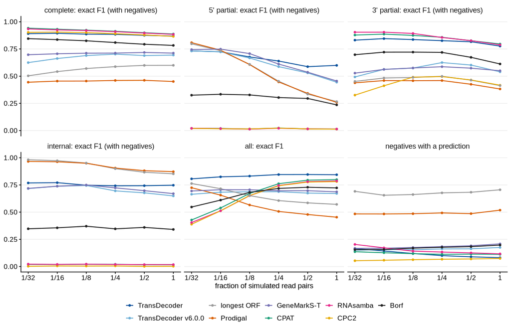

```r
DEPTH_COL <- c(TransDecoder = TD_C, `TransDecoder v6.0.0` = "#6baed6", `longest ORF` = GREY, Prodigal = "#d95f02",
               `GeneMarkS-T` = "#7570b3", CPAT = "#1b9e77", RNAsamba = "#e7298a", CPC2 = "#e6ab02", Borf = "#222222")
lev_frac <- function(l) dlev$fraction[match(l, dlev$level)]
depth_plot <- function(d) {
  ggplot(d, aes(fraction, value, colour = method)) + geom_line(linewidth = 0.4) + geom_point(size = 0.7) +
    facet_wrap(~panel, nrow = 2) +
    scale_x_continuous(trans = "log2", breaks = dlev$fraction, labels = LEV_LAB[dlev$level]) +
    scale_colour_manual(values = DEPTH_COL, name = NULL) + scale_y_continuous(limits = c(0, 1)) +
    labs(x = "fraction of simulated read pairs", y = NULL) +
    theme(legend.position = "bottom", panel.grid.major.y = element_line(linewidth = 0.2, colour = "#e5e5e5")) +
    guides(colour = guide_legend(nrow = 2))
}
F1_PANELS <- c(paste0(SIM_TYPE_LAB, ": exact F1 (with negatives)"), "all: exact F1", "negatives with a prediction")
dpanel <- bind_rows(
  dbt %>% transmute(fraction = lev_frac(level), method, panel = paste0(type, ": exact F1 (with negatives)"), value = f1_exact_wneg),
  dov %>% transmute(fraction = lev_frac(level), method, panel = "all: exact F1", value = f1_exact),
  dov %>% transmute(fraction = lev_frac(level), method, panel = "negatives with a prediction", value = frac_negatives_with_pred)) %>%
  mutate(panel = factor(panel, F1_PANELS))
figS_depth <- depth_plot(dpanel)
save_fig(figS_depth, "figS_simtrinity_depth", FULL_W, 110 * MM)
figS_depth
```

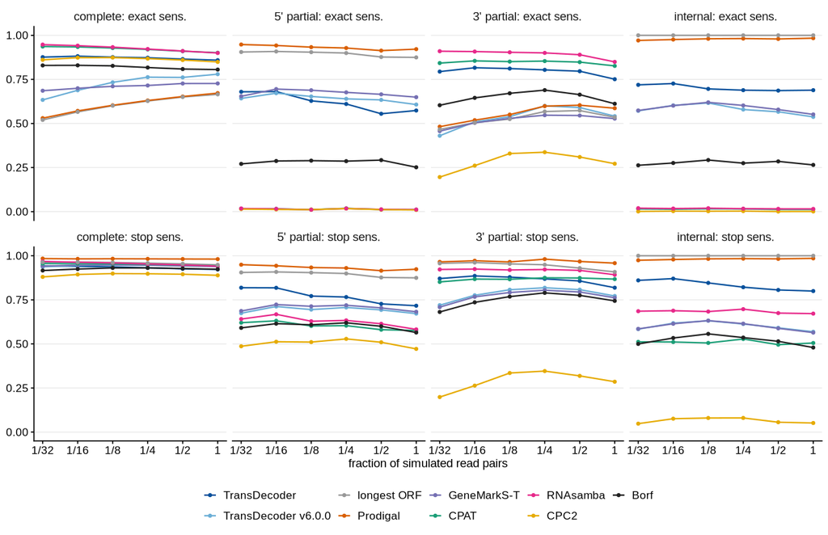

```r
SENS_PANELS <- c(paste0(SIM_TYPE_LAB, ": exact sens."), paste0(SIM_TYPE_LAB, ": stop sens."))
dsens <- bind_rows(
  dbt %>% transmute(fraction = lev_frac(level), method, panel = paste0(type, ": exact sens."), value = sensitivity_exact),
  dbt %>% transmute(fraction = lev_frac(level), method, panel = paste0(type, ": stop sens."), value = sensitivity_stop)) %>%
  mutate(panel = factor(panel, SENS_PANELS))
figS_depth_sens <- depth_plot(dsens) + facet_wrap(~panel, nrow = 2, ncol = 4)
save_fig(figS_depth_sens, "figS_simtrinity_depth_sens", FULL_W, 110 * MM)
figS_depth_sens
```

## Simulated Arabidopsis Trinity assembly

The E30/E31 design repeated for *A. thaliana* (E32; scripts `pipeline/simtrinity_athal/`, tables `data/simtrinity_athal/`). Transcripts: TAIR12 (the annotation of the main benchmark) protein-coding transcripts with a complete CDS, plus lncRNA and antisense_RNA transcripts that overlap no same-strand CDS as negatives. Expression: salmon on a stranded (dUTP) Col-0 leaf library (ENA ERR4140056, 2 x 100 nt). Reads: Polyester, as E30. Assembly: STAR two-pass on a TAIR12 index, genome-guided Trinity 2.15.2 and minimap2 with the E30 parameters. Labels, tools (organism `athal`: TransDecoder `-G Universal`; CPAT, CPC2 and RNAsamba with their human models) and scoring as E30/E31, at full depth (d1) and at 1/2 … of the read pairs.

```r
AT <- function(...) read_tab("simtrinity_athal", ...)
at_sel <- read_tsv(data_path("simtrinity_athal", "selection_counts.tsv"), col_names = c("step", "n"), show_col_types = FALSE)
ATSEL <- setNames(at_sel$n, at_sel$step)
at_par <- AT("sim_params.tsv") %>% { setNames(.[[2]], .[[1]]) }
alev <- AT("depth", "levels.tsv") %>% mutate(fraction = as.numeric(fraction))
ALEV_LAB <- setNames(ifelse(alev$fraction == 1, "1", paste0("1/", round(1 / alev$fraction))), alev$level)
atc <- AT("depth", "truth_counts.tsv") %>% mutate(reads = ALEV_LAB[level])
kable(tibble(step = c("coding transcripts kept (complete CDS)", "negatives kept (lncRNA / antisense_RNA)",
                      "salmon pairs assigned (real reads)", "simulated pairs (coding / negatives)",
                      "fragment length mean / sd"),
             value = c(num(ATSEL[["coding_kept"]]),
                       paste(num(ATSEL[["neg_kept:lncRNA"]]), "/", num(ATSEL[["neg_kept:antisense_RNA"]])),
                       num(as.numeric(at_par[["salmon_num_mapped"]])),
                       paste(num(as.numeric(at_par[["pairs_coding"]])), "/", num(as.numeric(at_par[["pairs_lncRNA"]]))),
                       paste(at_par[["fld_mean"]], "/", at_par[["fld_sd"]]))),
      caption = "Arabidopsis: transcript set and simulation")
```

Arabidopsis: transcript set and simulation

| step | value |
| --- | --- |
| coding transcripts kept (complete CDS) | 36,572 |
| negatives kept (lncRNA / antisense_RNA) | 2,576 / 3,342 |
| salmon pairs assigned (real reads) | 28,993,357 |
| simulated pairs (coding / negatives) | 28,728,866 / 125,003 |
| fragment length mean / sd | 340.25 / 88.13 |

```r
ash <- atc %>% transmute(reads, s_c = complete / truth_total, s_5 = `5prime_partial` / truth_total,
                         s_3 = `3prime_partial` / truth_total, s_i = internal / truth_total)
kable(alev %>% transmute(level, `read pairs` = num(as.numeric(pairs)), `Trinity transcripts` = num(trinity_transcripts)) %>%
        left_join(atc %>% select(level, complete, `5' partial` = `5prime_partial`, `3' partial` = `3prime_partial`, internal,
                                 truth = truth_total, negatives, unresolved), by = "level") %>%
        left_join(ash %>% transmute(level = names(ALEV_LAB)[match(reads, ALEV_LAB)],
                                    `complete / 5' / 3' / internal (%)` = paste(f1(100 * s_c), f1(100 * s_5), f1(100 * s_3), f1(100 * s_i), sep = " / ")),
                  by = "level"),
      caption = "Arabidopsis: assembly size and labels by depth level")
```

Arabidopsis: assembly size and labels by depth level

| level | read pairs | Trinity transcripts | complete | 5’ partial | 3’ partial | internal | truth | negatives | unresolved | complete / 5’ / 3’ / internal (%) |
| --- | --- | --- | --- | --- | --- | --- | --- | --- | --- | --- |
| d1 | 28,853,433 | 23,947 | 17317 | 1065 | 593 | 2078 | 21053 | 1372 | 1139 | 82.3 / 5.1 / 2.8 / 9.9 |
| d2 | 14,429,353 | 22,942 | 15335 | 1315 | 793 | 3044 | 20487 | 990 | 1021 | 74.9 / 6.4 / 3.9 / 14.9 |
| d4 | 7,217,805 | 22,400 | 12699 | 1797 | 1031 | 4643 | 20170 | 638 | 1007 | 63.0 / 8.9 / 5.1 / 23.0 |
| d8 | 3,610,788 | 22,655 | 9216 | 2410 | 1456 | 7407 | 20489 | 321 | 1058 | 45.0 / 11.8 / 7.1 / 36.2 |
| d16 | 1,803,816 | 21,228 | 5780 | 2484 | 1516 | 9426 | 19206 | 154 | 1065 | 30.1 / 12.9 / 7.9 / 49.1 |
| d32 | 901,520 | 16,147 | 3170 | 1940 | 1099 | 8330 | 14539 | 74 | 847 | 21.8 / 13.3 / 7.6 / 57.3 |

```r
details(AT("depth", "label_counts.tsv") %>% pivot_wider(names_from = level, values_from = n, values_fill = 0),
        "Arabidopsis: all labels and reasons by level")
```

**Arabidopsis: all labels and reasons by level**

| label | reason | d1 | d2 | d4 | d8 | d16 | d32 |
| --- | --- | --- | --- | --- | --- | --- | --- |
| 3prime_partial | . | 593 | 793 | 1031 | 1456 | 1516 | 1099 |
| 5prime_partial | . | 1065 | 1315 | 1797 | 2410 | 2484 | 1940 |
| ambiguous | 2_projections | 81 | 60 | 74 | 87 | 74 | 45 |
| complete | . | 17317 | 15335 | 12699 | 9216 | 5780 | 3170 |
| internal | . | 2078 | 3044 | 4643 | 7407 | 9426 | 8330 |
| noncoding | . | 1372 | 990 | 638 | 321 | 154 | 74 |
| short_complete | . | 39 | 33 | 28 | 23 | 13 | 11 |
| short_partial | . | 263 | 351 | 483 | 677 | 716 | 631 |
| unresolved | cds_end_in_deletion | 1 | 1 | 0 | 0 | 1 | 1 |
| unresolved | chimeric | 9 | 9 | 8 | 6 | 4 | 2 |
| unresolved | frame_check_failed | 6 | 2 | 1 | 0 | 5 | 4 |
| unresolved | incompatible | 577 | 423 | 315 | 256 | 166 | 103 |
| unresolved | large_softclip | 93 | 76 | 49 | 29 | 25 | 7 |
| unresolved | no_overlap | 22 | 7 | 2 | 1 | 1 | 3 |
| unresolved | softclip_at_open_cds_end | 74 | 119 | 218 | 355 | 496 | 493 |
| unresolved | unaligned | 9 | 3 | 2 | 1 | 0 | 0 |
| unresolved | utr_only | 348 | 381 | 412 | 410 | 367 | 234 |

```r
abt <- AT("depth", "scores_by_type.tsv") %>% mutate(method = factor(SIM_TOOLS[tool], levels = SIM_TOOLS),
                                                   type = factor(SIM_TYPE_LAB[type], levels = SIM_TYPE_LAB),
                                                   reads = factor(ALEV_LAB[level], levels = ALEV_LAB))
aov <- AT("depth", "scores_overall.tsv") %>%
  left_join(AT("depth", "negatives.tsv") %>% select(level, tool, frac_negatives_with_pred), by = c("level", "tool")) %>%
  mutate(method = factor(SIM_TOOLS[tool], levels = SIM_TOOLS), reads = factor(ALEV_LAB[level], levels = ALEV_LAB))
kable(aov %>% filter(level == "d1") %>% arrange(method) %>%
        transmute(method, n_truth, sensitivity_stop, precision_stop, f1_stop, sensitivity_exact, precision_exact, f1_exact,
                  negatives_with_pred = frac_negatives_with_pred, n_pred_excluded) %>% mutate(across(where(is.double), r3)),
      caption = "Arabidopsis, full depth: all scored contigs")
```

Arabidopsis, full depth: all scored contigs

| method | n_truth | sensitivity_stop | precision_stop | f1_stop | sensitivity_exact | precision_exact | f1_exact | negatives_with_pred | n_pred_excluded |
| --- | --- | --- | --- | --- | --- | --- | --- | --- | --- |
| TransDecoder | 21053 | 0.951 | 0.994 | 0.972 | 0.863 | 0.901 | 0.881 | 0.060 | 797 |
| TransDecoder v6.0.0 | 21053 | 0.909 | 0.983 | 0.944 | 0.742 | 0.803 | 0.771 | 0.055 | 825 |
| longest ORF | 21053 | 0.995 | 0.958 | 0.976 | 0.745 | 0.717 | 0.731 | 0.588 | 1075 |
| Prodigal | 21053 | 0.986 | 0.895 | 0.938 | 0.713 | 0.648 | 0.679 | 0.230 | 1264 |
| GeneMarkS-T | 21053 | 0.911 | 0.992 | 0.950 | 0.733 | 0.797 | 0.764 | 0.081 | 752 |
| CPAT | 21053 | 0.878 | 0.992 | 0.932 | 0.807 | 0.911 | 0.856 | 0.061 | 699 |
| RNAsamba | 21053 | 0.956 | 0.951 | 0.954 | 0.841 | 0.836 | 0.838 | 0.536 | 989 |
| CPC2 | 21053 | 0.839 | 0.996 | 0.911 | 0.794 | 0.943 | 0.862 | 0.025 | 613 |
| Borf | 21053 | 0.896 | 0.993 | 0.942 | 0.837 | 0.927 | 0.880 | 0.063 | 741 |

```r
anc <- AT("depth", "negatives_by_class.tsv") %>% filter(level == "d1") %>% mutate(method = SIM_TOOLS[tool])
kable(anc %>% select(class, n_negatives, method, frac_with_pred) %>% mutate(frac_with_pred = r3(frac_with_pred)) %>%
        pivot_wider(names_from = method, values_from = frac_with_pred),
      caption = "Arabidopsis, full depth: negatives with a prediction, by source class ('both': compatible with transcripts of both classes)")
```

Arabidopsis, full depth: negatives with a prediction, by source class (‘both’: compatible with transcripts of both classes)

| class | n_negatives | TransDecoder | TransDecoder v6.0.0 | Prodigal | GeneMarkS-T | CPAT | CPC2 | RNAsamba | Borf | longest ORF |
| --- | --- | --- | --- | --- | --- | --- | --- | --- | --- | --- |
| antisense_RNA | 1014 | 0.059 | 0.059 | 0.169 | 0.090 | 0.066 | 0.027 | 0.545 | 0.068 | 0.582 |
| both | 9 | 0.333 | 0.111 | 0.333 | 0.111 | 0.222 | 0.000 | 0.333 | 0.000 | 0.333 |
| lncRNA | 349 | 0.057 | 0.040 | 0.404 | 0.054 | 0.043 | 0.023 | 0.516 | 0.052 | 0.610 |

```r
details(AT("depth", "negatives_by_class.tsv") %>% mutate(frac_with_pred = r3(frac_with_pred)),
        "Arabidopsis: negatives by class, all levels")
```

**Arabidopsis: negatives by class, all levels**

| level | class | n_negatives | tool | with_pred | frac_with_pred |
| --- | --- | --- | --- | --- | --- |
| d1 | antisense_RNA | 1014 | pytd_v7 | 60 | 0.059 |
| d1 | both | 9 | pytd_v7 | 3 | 0.333 |
| d1 | lncRNA | 349 | pytd_v7 | 20 | 0.057 |
| d1 | antisense_RNA | 1014 | perl_td_v600 | 60 | 0.059 |
| d1 | both | 9 | perl_td_v600 | 1 | 0.111 |
| d1 | lncRNA | 349 | perl_td_v600 | 14 | 0.040 |
| d1 | antisense_RNA | 1014 | prodigal | 171 | 0.169 |
| d1 | both | 9 | prodigal | 3 | 0.333 |
| d1 | lncRNA | 349 | prodigal | 141 | 0.404 |
| d1 | antisense_RNA | 1014 | gmst | 91 | 0.090 |
| d1 | both | 9 | gmst | 1 | 0.111 |
| d1 | lncRNA | 349 | gmst | 19 | 0.054 |
| d1 | antisense_RNA | 1014 | cpat | 67 | 0.066 |
| d1 | both | 9 | cpat | 2 | 0.222 |
| d1 | lncRNA | 349 | cpat | 15 | 0.043 |
| d1 | antisense_RNA | 1014 | cpc2 | 27 | 0.027 |
| d1 | both | 9 | cpc2 | 0 | 0.000 |
| d1 | lncRNA | 349 | cpc2 | 8 | 0.023 |
| d1 | antisense_RNA | 1014 | rnasamba | 553 | 0.545 |
| d1 | both | 9 | rnasamba | 3 | 0.333 |
| d1 | lncRNA | 349 | rnasamba | 180 | 0.516 |
| d1 | antisense_RNA | 1014 | borf | 69 | 0.068 |
| d1 | both | 9 | borf | 0 | 0.000 |
| d1 | lncRNA | 349 | borf | 18 | 0.052 |
| d1 | antisense_RNA | 1014 | longest_orf | 590 | 0.582 |
| d1 | both | 9 | longest_orf | 3 | 0.333 |
| d1 | lncRNA | 349 | longest_orf | 213 | 0.610 |
| d2 | antisense_RNA | 711 | pytd_v7 | 44 | 0.062 |
| d2 | both | 8 | pytd_v7 | 1 | 0.125 |
| d2 | lncRNA | 271 | pytd_v7 | 15 | 0.055 |

[output cut: 105 more lines]

```r
abest <- function(col) abt %>% filter(tool != TD) %>% group_by(reads, type) %>%
  slice_max(.data[[col]], n = 1, with_ties = FALSE) %>% ungroup() %>%
  transmute(reads, type, v = sprintf("%.3f (%s)", .data[[col]], method))
kable(abt %>% filter(tool == TD) %>% transmute(reads, type, n_truth, `TransDecoder, with negatives` = r3(f1_exact_wneg)) %>%
        left_join(abest("f1_exact_wneg") %>% rename(`best other, with negatives` = v), by = c("reads", "type")) %>%
        arrange(type, reads),
      caption = "Arabidopsis: exact F1 by CDS type (negatives counted), TransDecoder vs the best other method")
```

Arabidopsis: exact F1 by CDS type (negatives counted), TransDecoder vs the best other method

| reads | type | n_truth | TransDecoder, with negatives | best other, with negatives |
| --- | --- | --- | --- | --- |
| 1 | complete | 17317 | 0.918 | 0.973 (RNAsamba) |
| 1/2 | complete | 15335 | 0.921 | 0.977 (RNAsamba) |
| 1/4 | complete | 12699 | 0.921 | 0.982 (RNAsamba) |
| 1/8 | complete | 9216 | 0.916 | 0.986 (RNAsamba) |
| 1/16 | complete | 5780 | 0.918 | 0.989 (RNAsamba) |
| 1/32 | complete | 3170 | 0.907 | 0.988 (RNAsamba) |
| 1 | 5’ partial | 1065 | 0.617 | 0.893 (Prodigal) |
| 1/2 | 5’ partial | 1315 | 0.633 | 0.911 (Prodigal) |
| 1/4 | 5’ partial | 1797 | 0.677 | 0.941 (Prodigal) |
| 1/8 | 5’ partial | 2410 | 0.688 | 0.967 (longest ORF) |
| 1/16 | 5’ partial | 2484 | 0.704 | 0.977 (longest ORF) |
| 1/32 | 5’ partial | 1940 | 0.743 | 0.967 (longest ORF) |
| 1 | 3’ partial | 593 | 0.773 | 0.858 (RNAsamba) |
| 1/2 | 3’ partial | 793 | 0.841 | 0.910 (RNAsamba) |
| 1/4 | 3’ partial | 1031 | 0.855 | 0.931 (RNAsamba) |
| 1/8 | 3’ partial | 1456 | 0.852 | 0.951 (RNAsamba) |
| 1/16 | 3’ partial | 1516 | 0.853 | 0.948 (RNAsamba) |
| 1/32 | 3’ partial | 1099 | 0.847 | 0.944 (RNAsamba) |
| 1 | internal | 2078 | 0.736 | 0.989 (longest ORF) |
| 1/2 | internal | 3044 | 0.730 | 0.994 (longest ORF) |
| 1/4 | internal | 4643 | 0.757 | 0.998 (longest ORF) |
| 1/8 | internal | 7407 | 0.783 | 0.999 (longest ORF) |
| 1/16 | internal | 9426 | 0.787 | 1.000 (longest ORF) |
| 1/32 | internal | 8330 | 0.815 | 1.000 (longest ORF) |

```r
details(aov %>% transmute(reads, method, f1_stop = r3(f1_stop), f1_exact = r3(f1_exact),
                          negatives_with_pred = r3(frac_negatives_with_pred)) %>% arrange(reads, method),
        "Arabidopsis: overall F1 and negatives with a prediction, by level and method")
```

**Arabidopsis: overall F1 and negatives with a prediction, by level and method**

| reads | method | f1_stop | f1_exact | negatives_with_pred |
| --- | --- | --- | --- | --- |
| 1 | TransDecoder | 0.972 | 0.881 | 0.060 |
| 1 | TransDecoder v6.0.0 | 0.944 | 0.771 | 0.055 |
| 1 | longest ORF | 0.976 | 0.731 | 0.588 |
| 1 | Prodigal | 0.938 | 0.679 | 0.230 |
| 1 | GeneMarkS-T | 0.950 | 0.764 | 0.081 |
| 1 | CPAT | 0.932 | 0.856 | 0.061 |
| 1 | RNAsamba | 0.954 | 0.838 | 0.536 |
| 1 | CPC2 | 0.911 | 0.862 | 0.025 |
| 1 | Borf | 0.942 | 0.880 | 0.063 |
| 1/2 | TransDecoder | 0.970 | 0.873 | 0.061 |
| 1/2 | TransDecoder v6.0.0 | 0.936 | 0.760 | 0.048 |
| 1/2 | longest ORF | 0.982 | 0.747 | 0.566 |
| 1/2 | Prodigal | 0.945 | 0.699 | 0.243 |
| 1/2 | GeneMarkS-T | 0.941 | 0.764 | 0.067 |
| 1/2 | CPAT | 0.918 | 0.805 | 0.046 |
| 1/2 | RNAsamba | 0.953 | 0.784 | 0.522 |
| 1/2 | CPC2 | 0.883 | 0.814 | 0.016 |
| 1/2 | Borf | 0.931 | 0.843 | 0.048 |
| 1/4 | TransDecoder | 0.973 | 0.859 | 0.046 |
| 1/4 | TransDecoder v6.0.0 | 0.919 | 0.734 | 0.028 |
| 1/4 | longest ORF | 0.987 | 0.773 | 0.545 |
| 1/4 | Prodigal | 0.955 | 0.731 | 0.208 |
| 1/4 | GeneMarkS-T | 0.922 | 0.759 | 0.049 |
| 1/4 | CPAT | 0.887 | 0.718 | 0.027 |
| 1/4 | RNAsamba | 0.940 | 0.689 | 0.497 |
| 1/4 | CPC2 | 0.830 | 0.728 | 0.016 |
| 1/4 | Borf | 0.906 | 0.788 | 0.036 |
| 1/8 | TransDecoder | 0.968 | 0.838 | 0.047 |
| 1/8 | TransDecoder v6.0.0 | 0.881 | 0.730 | 0.028 |
| 1/8 | longest ORF | 0.992 | 0.815 | 0.526 |
| 1/8 | Prodigal | 0.963 | 0.779 | 0.212 |
| 1/8 | GeneMarkS-T | 0.882 | 0.747 | 0.037 |
| 1/8 | CPAT | 0.825 | 0.573 | 0.003 |
| 1/8 | RNAsamba | 0.910 | 0.540 | 0.470 |
| 1/8 | CPC2 | 0.723 | 0.582 | 0.009 |
| 1/8 | Borf | 0.858 | 0.690 | 0.031 |
| 1/16 | TransDecoder | 0.969 | 0.822 | 0.026 |
| 1/16 | TransDecoder v6.0.0 | 0.827 | 0.688 | 0.013 |
| 1/16 | longest ORF | 0.994 | 0.852 | 0.435 |
| 1/16 | Prodigal | 0.970 | 0.824 | 0.156 |
| 1/16 | GeneMarkS-T | 0.827 | 0.716 | 0.020 |
| 1/16 | CPAT | 0.755 | 0.438 | 0.000 |
| 1/16 | RNAsamba | 0.879 | 0.403 | 0.403 |
| 1/16 | CPC2 | 0.594 | 0.435 | 0.006 |
| 1/16 | Borf | 0.792 | 0.585 | 0.006 |
| 1/32 | TransDecoder | 0.971 | 0.828 | 0.040 |
| 1/32 | TransDecoder v6.0.0 | 0.772 | 0.664 | 0.014 |
| 1/32 | longest ORF | 0.994 | 0.876 | 0.405 |
| 1/32 | Prodigal | 0.974 | 0.854 | 0.108 |
| 1/32 | GeneMarkS-T | 0.771 | 0.679 | 0.040 |
| 1/32 | CPAT | 0.689 | 0.347 | 0.000 |
| 1/32 | RNAsamba | 0.851 | 0.316 | 0.392 |
| 1/32 | CPC2 | 0.486 | 0.336 | 0.014 |
| 1/32 | Borf | 0.727 | 0.512 | 0.014 |

```r
details(abt %>% transmute(reads, method, type, n_truth, sensitivity_exact = r3(sensitivity_exact),
                          f1_exact = r3(f1_exact), f1_exact_wneg = r3(f1_exact_wneg)) %>% arrange(type, reads, method),
        "Arabidopsis: by type, by level and method")
```

**Arabidopsis: by type, by level and method**

| reads | method | type | n_truth | sensitivity_exact | f1_exact | f1_exact_wneg |
| --- | --- | --- | --- | --- | --- | --- |
| 1 | TransDecoder | complete | 17317 | 0.904 | 0.919 | 0.918 |
| 1 | TransDecoder v6.0.0 | complete | 17317 | 0.787 | 0.794 | 0.793 |
| 1 | longest ORF | complete | 17317 | 0.704 | 0.704 | 0.697 |
| 1 | Prodigal | complete | 17317 | 0.672 | 0.640 | 0.637 |
| 1 | GeneMarkS-T | complete | 17317 | 0.768 | 0.778 | 0.777 |
| 1 | CPAT | complete | 17317 | 0.954 | 0.973 | 0.971 |
| 1 | RNAsamba | complete | 17317 | 0.987 | 0.990 | 0.973 |
| 1 | CPC2 | complete | 17317 | 0.952 | 0.973 | 0.972 |
| 1 | Borf | complete | 17317 | 0.950 | 0.966 | 0.964 |
| 1/2 | TransDecoder | complete | 15335 | 0.908 | 0.922 | 0.921 |
| 1/2 | TransDecoder v6.0.0 | complete | 15335 | 0.780 | 0.788 | 0.787 |
| 1/2 | longest ORF | complete | 15335 | 0.695 | 0.695 | 0.690 |
| 1/2 | Prodigal | complete | 15335 | 0.665 | 0.635 | 0.632 |
| 1/2 | GeneMarkS-T | complete | 15335 | 0.765 | 0.776 | 0.775 |
| 1/2 | CPAT | complete | 15335 | 0.956 | 0.975 | 0.973 |
| 1/2 | RNAsamba | complete | 15335 | 0.988 | 0.991 | 0.977 |
| 1/2 | CPC2 | complete | 15335 | 0.954 | 0.974 | 0.973 |
| 1/2 | Borf | complete | 15335 | 0.950 | 0.965 | 0.964 |
| 1/4 | TransDecoder | complete | 12699 | 0.909 | 0.921 | 0.921 |
| 1/4 | TransDecoder v6.0.0 | complete | 12699 | 0.741 | 0.750 | 0.750 |
| 1/4 | longest ORF | complete | 12699 | 0.681 | 0.681 | 0.677 |
| 1/4 | Prodigal | complete | 12699 | 0.651 | 0.624 | 0.623 |
| 1/4 | GeneMarkS-T | complete | 12699 | 0.759 | 0.769 | 0.769 |
| 1/4 | CPAT | complete | 12699 | 0.957 | 0.976 | 0.975 |
| 1/4 | RNAsamba | complete | 12699 | 0.989 | 0.992 | 0.982 |
| 1/4 | CPC2 | complete | 12699 | 0.954 | 0.974 | 0.974 |
| 1/4 | Borf | complete | 12699 | 0.951 | 0.967 | 0.966 |
| 1/8 | TransDecoder | complete | 9216 | 0.902 | 0.916 | 0.916 |
| 1/8 | TransDecoder v6.0.0 | complete | 9216 | 0.772 | 0.783 | 0.783 |
| 1/8 | longest ORF | complete | 9216 | 0.655 | 0.655 | 0.653 |

[output cut: 186 more lines]

**What this assembly tests.** The expression levels are those of the real leaf library (Brian, 2026-10-28: the noncoding RNAs were not boosted). The lncRNA and antisense_RNA transcripts carry only 0.4% of the simulated reads, so few negative contigs assemble (1,372 at full depth, falling with depth). This simulation is therefore mainly a test of frame and end placement on assembled coding transcripts, not of rejecting noncoding sequence; the noncoding test is the human simulation (E30/E31) and the lncRNA inputs of the main benchmark (E04).

**Homology mode.** TransDecoder (PyTD a5b24c3, E33) on each depth level of both simulations in three conditions on the same LongOrfs: A ab initio; B homology mode (DIAMOND `-k 1 -e 1e-5` against Swiss-Prot without the organism’s own entries, `sprot_minus_9606` / `sprot_minus_3702`, and `hmmsearch --cut_ga` against Pfam-A, on all LongOrfs peptides) with the homology start assist (the default when hits are supplied); C the same hits with `--no-homology-start-assist`. Condition A equals the release TransDecoder rows above. Scripts `pipeline/start_classifier/17_*`-`22_*`; tables `data/start_classifier/adoption/{human,athal}_depth_scores.tsv`.

```r
HOM_COND <- c(TD_A_abinitio = "A ab initio", TD_B_homology_assist = "B homology + start assist",
              TD_C_homology_noassist = "C homology, no start assist")
hds <- bind_rows(
  read_tab("start_classifier", "adoption", "human_depth_scores.tsv") %>% mutate(species = "human"),
  read_tab("start_classifier", "adoption", "athal_depth_scores.tsv") %>% mutate(species = "A. thaliana")) %>%
  mutate(species = factor(species, c("human", "A. thaliana")))
hds_lab <- function(sp, lv) ifelse(sp == "human", LEV_LAB[lv], ALEV_LAB[lv])
kable(hds %>% filter(method %in% names(HOM_COND)) %>%
        transmute(species, reads = hds_lab(species, level), lv = as.integer(sub("d", "", level)), condition = HOM_COND[method],
                  `all: exact F1` = r3(f1_exact), `all: stop F1` = r3(f1_stop),
                  complete = r3(f1_exact_wneg_complete), `5' partial` = r3(f1_exact_wneg_5prime_partial),
                  `3' partial` = r3(f1_exact_wneg_3prime_partial), internal = r3(f1_exact_wneg_internal)) %>%
        arrange(species, lv, condition) %>% select(-lv),
      caption = "TransDecoder ab initio (A), homology mode with (B) and without (C) the start assist: exact F1 overall and per CDS type (per type: negatives counted)")
```

TransDecoder ab initio (A), homology mode with (B) and without (C) the start assist: exact F1 overall and per CDS type (per type: negatives counted)

| species | reads | condition | all: exact F1 | all: stop F1 | complete | 5’ partial | 3’ partial | internal |
| --- | --- | --- | --- | --- | --- | --- | --- | --- |
| human | 1 | A ab initio | 0.844 | 0.916 | 0.869 | 0.599 | 0.776 | 0.747 |
| human | 1 | B homology + start assist | 0.882 | 0.934 | 0.892 | 0.706 | 0.832 | 0.919 |
| human | 1 | C homology, no start assist | 0.858 | 0.934 | 0.880 | 0.617 | 0.813 | 0.792 |
| human | 1/2 | A ab initio | 0.846 | 0.920 | 0.875 | 0.587 | 0.816 | 0.743 |
| human | 1/2 | B homology + start assist | 0.893 | 0.941 | 0.902 | 0.741 | 0.865 | 0.922 |
| human | 1/2 | C homology, no start assist | 0.862 | 0.941 | 0.889 | 0.612 | 0.839 | 0.783 |
| human | 1/4 | A ab initio | 0.846 | 0.923 | 0.884 | 0.639 | 0.826 | 0.742 |
| human | 1/4 | B homology + start assist | 0.904 | 0.948 | 0.914 | 0.777 | 0.888 | 0.927 |
| human | 1/4 | C homology, no start assist | 0.863 | 0.948 | 0.899 | 0.661 | 0.858 | 0.784 |
| human | 1/8 | A ab initio | 0.832 | 0.924 | 0.886 | 0.676 | 0.837 | 0.748 |
| human | 1/8 | B homology + start assist | 0.921 | 0.960 | 0.922 | 0.865 | 0.921 | 0.942 |
| human | 1/8 | C homology, no start assist | 0.855 | 0.960 | 0.903 | 0.715 | 0.878 | 0.786 |
| human | 1/16 | A ab initio | 0.825 | 0.929 | 0.894 | 0.724 | 0.845 | 0.771 |
| human | 1/16 | B homology + start assist | 0.939 | 0.971 | 0.932 | 0.910 | 0.934 | 0.958 |
| human | 1/16 | C homology, no start assist | 0.854 | 0.971 | 0.911 | 0.772 | 0.890 | 0.806 |
| human | 1/32 | A ab initio | 0.806 | 0.925 | 0.891 | 0.732 | 0.831 | 0.768 |
| human | 1/32 | B homology + start assist | 0.949 | 0.979 | 0.941 | 0.930 | 0.944 | 0.960 |
| human | 1/32 | C homology, no start assist | 0.839 | 0.979 | 0.912 | 0.775 | 0.887 | 0.801 |
| A. thaliana | 1 | A ab initio | 0.881 | 0.972 | 0.918 | 0.617 | 0.773 | 0.736 |
| A. thaliana | 1 | B homology + start assist | 0.914 | 0.984 | 0.927 | 0.787 | 0.808 | 0.893 |
| A. thaliana | 1 | C homology, no start assist | 0.891 | 0.984 | 0.926 | 0.634 | 0.801 | 0.750 |
| A. thaliana | 1/2 | A ab initio | 0.873 | 0.970 | 0.921 | 0.633 | 0.841 | 0.730 |
| A. thaliana | 1/2 | B homology + start assist | 0.915 | 0.984 | 0.931 | 0.806 | 0.869 | 0.892 |
| A. thaliana | 1/2 | C homology, no start assist | 0.882 | 0.984 | 0.930 | 0.642 | 0.867 | 0.746 |
| A. thaliana | 1/4 | A ab initio | 0.859 | 0.973 | 0.921 | 0.677 | 0.855 | 0.757 |
| A. thaliana | 1/4 | B homology + start assist | 0.909 | 0.986 | 0.930 | 0.818 | 0.873 | 0.893 |
| A. thaliana | 1/4 | C homology, no start assist | 0.868 | 0.986 | 0.929 | 0.687 | 0.872 | 0.769 |
| A. thaliana | 1/8 | A ab initio | 0.838 | 0.968 | 0.916 | 0.688 | 0.852 | 0.783 |
| A. thaliana | 1/8 | B homology + start assist | 0.901 | 0.983 | 0.929 | 0.836 | 0.868 | 0.893 |
| A. thaliana | 1/8 | C homology, no start assist | 0.848 | 0.983 | 0.926 | 0.706 | 0.870 | 0.791 |
| A. thaliana | 1/16 | A ab initio | 0.822 | 0.969 | 0.918 | 0.704 | 0.853 | 0.787 |
| A. thaliana | 1/16 | B homology + start assist | 0.899 | 0.985 | 0.934 | 0.852 | 0.874 | 0.893 |
| A. thaliana | 1/16 | C homology, no start assist | 0.832 | 0.985 | 0.930 | 0.723 | 0.872 | 0.794 |
| A. thaliana | 1/32 | A ab initio | 0.828 | 0.971 | 0.907 | 0.743 | 0.847 | 0.815 |
| A. thaliana | 1/32 | B homology + start assist | 0.908 | 0.986 | 0.928 | 0.869 | 0.872 | 0.914 |
| A. thaliana | 1/32 | C homology, no start assist | 0.836 | 0.986 | 0.919 | 0.756 | 0.865 | 0.819 |

```r
kable(hds %>% filter(species == "human", method %in% names(HOM_COND)) %>%
        transmute(reads = LEV_LAB[level], lv = as.integer(sub("d", "", level)), condition = HOM_COND[method],
                  v = sprintf("%s / %s", num(negatives_with_pred), num(n_negatives))) %>%
        pivot_wider(names_from = condition, values_from = v) %>% arrange(lv) %>% select(-lv),
      caption = "Human: lncRNA-only contigs (negatives) with a prediction / negatives, by condition")
```

Human: lncRNA-only contigs (negatives) with a prediction / negatives, by condition

| reads | A ab initio | B homology + start assist | C homology, no start assist |
| --- | --- | --- | --- |
| 1 | 1,688 / 20,815 | 3,319 / 20,815 | 3,319 / 20,815 |
| 1/2 | 1,343 / 15,054 | 2,480 / 15,054 | 2,480 / 15,054 |
| 1/4 | 995 / 9,913 | 1,788 / 9,913 | 1,788 / 9,913 |
| 1/8 | 704 / 5,885 | 1,129 / 5,885 | 1,129 / 5,885 |
| 1/16 | 466 / 3,267 | 666 / 3,267 | 666 / 3,267 |
| 1/32 | 264 / 1,594 | 361 / 1,594 | 361 / 1,594 |

**Human vs Arabidopsis.** Exact F1 per CDS type (negatives counted) and overall, by depth level, for both simulations (human: E30/E31, above). Dashed: TransDecoder in homology mode with the start assist (condition B above).

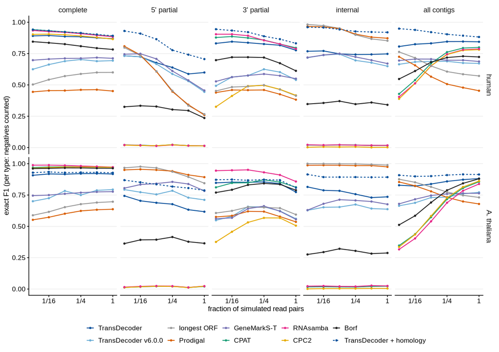

```r
HOM_LAB <- "TransDecoder + homology"
hom <- hds %>% filter(method == "TD_B_homology_assist") %>%
  transmute(species, fraction = ifelse(species == "human", lev_frac(level), alev$fraction[match(level, alev$level)]),
            f1_exact, complete = f1_exact_wneg_complete, `5prime_partial` = f1_exact_wneg_5prime_partial,
            `3prime_partial` = f1_exact_wneg_3prime_partial, internal = f1_exact_wneg_internal) %>%
  pivot_longer(-c(species, fraction), names_to = "panel", values_to = "value") %>%
  mutate(panel = ifelse(panel == "f1_exact", "all", SIM_TYPE_LAB[panel]), method = HOM_LAB, species = as.character(species))
both <- bind_rows(
  dbt %>% transmute(species = "human", fraction = lev_frac(level), method, panel = as.character(type), value = f1_exact_wneg),
  dov %>% transmute(species = "human", fraction = lev_frac(level), method, panel = "all", value = f1_exact),
  abt %>% transmute(species = "A. thaliana", fraction = alev$fraction[match(level, alev$level)], method,
                    panel = as.character(type), value = f1_exact_wneg),
  aov %>% transmute(species = "A. thaliana", fraction = alev$fraction[match(level, alev$level)], method, panel = "all",
                    value = f1_exact)) %>%
  mutate(method = as.character(method)) %>% bind_rows(hom) %>%
  mutate(panel = factor(panel, c(SIM_TYPE_LAB, "all"), c(SIM_TYPE_LAB, "all contigs")),
         species = factor(species, c("human", "A. thaliana")),
         method = factor(method, c(SIM_TOOLS, HOM_LAB)))
HOM_COL <- c(DEPTH_COL, setNames(TD_C, HOM_LAB))
HOM_LTY <- setNames(c(rep("solid", length(DEPTH_COL)), "22"), names(HOM_COL))
figS_athal <- ggplot(both, aes(fraction, value, colour = method, linetype = method)) + geom_line(linewidth = 0.4) +
  geom_point(size = 0.6) +
  facet_grid(species ~ panel) +
  scale_x_continuous(trans = "log2", breaks = c(1, 1/4, 1/16), labels = c("1", "1/4", "1/16")) +
  scale_colour_manual(values = HOM_COL, name = NULL) + scale_linetype_manual(values = HOM_LTY, name = NULL) +
  scale_y_continuous(limits = c(0, 1)) +
  labs(x = "fraction of simulated read pairs", y = "exact F1 (per type: negatives counted)") +
  theme(legend.position = "bottom",
        panel.grid.major.y = element_line(linewidth = 0.2, colour = "#e5e5e5")) +
  guides(colour = guide_legend(nrow = 2), linetype = guide_legend(nrow = 2))
save_fig(figS_athal, "figS_simtrinity_athal", FULL_W, 120 * MM)
figS_athal
```

## Checks against the manuscript

Each row compares a value computed here with the value in the text now. Labels give the tex file and line (`mb` = `methods_benchmark.tex`, `rb` = `results_benchmark.tex`, `fm` = `figures_main.tex`). TransDecoder values are from the release runs, so TransDecoder mismatches are expected until the text is updated (see the previous section for the earlier values).

```r
# Methods
for (o in ORGS) check_text(sprintf("mb:32-39 genes, %s", ORG_LABEL[[o]]), genes$n_truth[genes$org == o], GENES_TEX[[o]])
check_text("mb:82 inputs per organism", unique(per_org$n), 10)
check_text("mb:84 human lncRNA negatives", n_lnc[["human"]], 33668)
check_text("mb:85 mouse lncRNA negatives", n_lnc[["mouse"]], 31467)
check_text("mb:85 inputs in total", N_INPUTS, 84)
check_text("mb:93 v5.7.1 = v6.0.0, inputs", sum(v6_same$same), 80)
check_text("mb:120 ANGEL runs", nrow(angel), 3)
check_text("mb:120 ANGEL hours, min", floor(min(angel$hours)), 17)
check_text("mb:120 ANGEL hours, max", round(max(angel$hours)), 22)
# Table 1 (rb:24-32)
TEX_T1 <- tribble(~tool, ~line, ~v1, ~v2, ~v3, ~v4, ~v5,
  "pytd_v7", 24, 0.980, 0.912, 0.930, 0.822, 0.994,
  "perl_td_v600", 25, 0.972, 0.779, 0.869, 0.715, 0.995,
  "longest_orf", 26, 0.976, 0.689, 0.839, 0.713, 0.803,
  "prodigal", 27, 0.937, 0.643, 0.936, 0.782, 0.660,
  "gmst", 28, 0.974, 0.783, 0.866, 0.746, 0.996,
  "cpat", 29, 0.965, 0.940, 0.783, 0.440, 0.971,
  "rnasamba", 30, 0.991, 0.961, 0.864, 0.486, 0.721,
  "cpc2", 31, 0.964, 0.935, 0.572, 0.183, 0.982,
  "borf", 32, 0.976, 0.923, 0.816, 0.538, 0.838,
  "codan", 33, 0.974, 0.830, 0.912, 0.761, 0.946)
for (i in seq_len(nrow(TEX_T1))) for (k in 1:5)
  check_text(sprintf("rb:%d Table 1 %s, %s", TEX_T1$line[i], TOOLS[[TEX_T1$tool[i]]], COLS$col[k]),
             r3(T1(TEX_T1$tool[i], COLS$col[k])), TEX_T1[[paste0("v", k)]][i])
check_text("rb:17 Table 1 caption: standard-code tools' medians over 7 organisms (1 = yes)",
           as.numeric(all(table1$min_orgs[table1$tool %in% INCOMPATIBLE] == 7)), 1)
# Stop codons
check_text("rb:39 TD complete stop F1 min", r3(min(td_cs)), 0.933)
check_text("rb:39 TD complete stop F1 max", r3(max(td_cs)), 0.997)
check_text("rb:40 TD complete stop F1 median", r3(median(td_cs)), 0.980)
check_text("rb:40 v6.0.0 complete stop F1 min", r3(min(v6_cs)), 0.948)
check_text("rb:40 v6.0.0 complete stop F1 max", r3(max(v6_cs)), 0.985)
check_text("rb:41 longest ORF complete stop F1 min", r3(min(lo_cs)), 0.954)
check_text("rb:41 longest ORF complete stop F1 max", r3(max(lo_cs)), 0.984)
check_text("rb:41 TD within x of v6.0.0 per organism (stop)", r3(td_v6_maxdiff), 0.014)
# Noncoding
check_text("rb:48 TD complete+rand precision median", r3(median(td_p)), 0.994)
check_text("rb:49 TD complete+rand precision min", r3(min(td_p)), 0.980)
check_text("rb:49 TD complete+rand precision max", r3(max(td_p)), 0.997)
check_text("rb:49 TD stop F1 complete median (from)", r3(median(td_cs)), 0.980)
check_text("rb:49 TD stop F1 complete+rand median (to)", r3(MED(TD, "complete.wRand", "f1_stop")), 0.979)
check_text("rb:50 Prodigal complete+rand precision min", r3(min(pr_p)), 0.344)
check_text("rb:50 Prodigal complete+rand precision max", r3(max(pr_p)), 0.866)
check_text("rb:50 Prodigal complete+rand precision median", r3(median(pr_p)), 0.660)
check_text("rb:51 Prodigal stop F1 complete median (from)", r3(MED("prodigal", "complete", "f1_stop")), 0.937)
check_text("rb:51 Prodigal stop F1 complete+rand median (to)", r3(MED("prodigal", "complete.wRand", "f1_stop")), 0.791)
check_text("rb:52 longest ORF complete+rand precision median", r3(median(lo_p)), 0.803)
check_text("rb:52 longest ORF complete+rand precision, C. rei.", r3(lo_p[["creinhardtii"]]), 0.567)
check_text("rb:53 RNAsamba complete+rand precision median", r3(MED("rnasamba", "complete.wRand", "precision_stop")), 0.721)
check_text("rb:53 Borf complete+rand precision median", r3(MED("borf", "complete.wRand", "precision_stop")), 0.838)
check_text("rb:53 CPAT complete+rand precision median", r3(median(cp_p)), 0.971)
check_text("rb:54 CPAT complete+rand precision, C. rei.", r3(cp_p[["creinhardtii"]]), 0.629)
# Starts
check_text("rb:58 longest ORF complete exact F1 median", r3(MED("longest_orf", "complete", "f1_exact")), 0.689)
check_text("rb:58 TD complete exact F1 min", r3(min(td_ce)), 0.747)
check_text("rb:58 TD complete exact F1 max", r3(max(td_ce)), 0.940)
check_text("rb:59 TD complete exact F1 median", r3(median(td_ce)), 0.912)
check_text("rb:60 v6.0.0 complete exact F1 min", r3(min(v6_ce)), 0.567)
check_text("rb:60 v6.0.0 complete exact F1 max", r3(max(v6_ce)), 0.912)
check_text("rb:60 v6.0.0 complete exact F1 median", r3(median(v6_ce)), 0.779)
check_text("rb:61 Prodigal complete exact F1 median", r3(MED("prodigal", "complete", "f1_exact")), 0.643)
check_text("rb:62 GeneMarkS-T complete exact F1 median", r3(MED("gmst", "complete", "f1_exact")), 0.783)
check_text("rb:63 CPAT/RNAsamba/CPC2 complete exact F1 medians, lowest", r3(min(cls_ce)), 0.935)
check_text("rb:63 CPAT/RNAsamba/CPC2 complete exact F1 medians, highest", r3(max(cls_ce)), 0.961)
check_text("rb:64 CPAT/RNAsamba/CPC2 fragments exact F1 medians, lowest", r3(min(cls_fe)), 0.183)
check_text("rb:64 CPAT/RNAsamba/CPC2 fragments exact F1 medians, highest", r3(max(cls_fe)), 0.486)
check_text("rb:64 TD fragments exact F1 median", r3(median(td_fe)), 0.822)
# Fragments
check_text("rb:66 organisms where Prodigal stop F1 > TD, fragments", length(prod_better_stop), 5)
check_text("rb:67 Prodigal fragments stop F1 median", r3(median(pr_fs)), 0.936)
check_text("rb:67 TD fragments stop F1 median", r3(median(td_fs)), 0.930)
check_text("rb:68 T. the. is the exception (Prodigal not higher)", as.numeric(!"tthermophila" %in% prod_better_stop), 1)
check_text("rb:68 Prodigal fragments stop F1, T. the.", r3(pr_fs[["tthermophila"]]), 0.869)
check_text("rb:68 TD fragments stop F1, T. the.", r3(td_fs[["tthermophila"]]), 0.887)
check_text("rb:79 TD > Prodigal exact on fragments in human, mouse, S. pom., D. mel., T. the.",
           as.numeric(setequal(td_better_exact, c("human", "mouse", "spombe", "dmel", "tthermophila"))), 1)
# Ciliate code
check_text("rb:80 TD T. the. complete stop F1", r3(TT(TD, "complete", "f1_stop")), 0.933)
check_text("rb:80 TD T. the. complete exact F1", r3(TT(TD, "complete", "f1_exact")), 0.833)
check_text("rb:81 v6.0.0 T. the. complete stop F1", r3(TT("perl_td_v600", "complete", "f1_stop")), 0.948)
check_text("rb:81 v6.0.0 T. the. complete exact F1", r3(TT("perl_td_v600", "complete", "f1_exact")), 0.567)
check_text("rb:81 Prodigal T. the. complete stop F1", r3(TT("prodigal", "complete", "f1_stop")), 0.856)
check_text("rb:81 Prodigal T. the. complete exact F1", r3(TT("prodigal", "complete", "f1_exact")), 0.395)
check_text("rb:82 CPAT T. the. complete stop F1", r3(TT("cpat", "complete", "f1_stop")), 0.884)
check_text("rb:82 CPAT T. the. complete exact F1", r3(TT("cpat", "complete", "f1_exact")), 0.851)
check_text("rb:83 TD T. the. complete+rand precision", r3(TT(TD, "complete.wRand", "precision_stop")), 0.980)
check_text("rb:83 v6.0.0 T. the. complete+rand precision", r3(TT("perl_td_v600", "complete.wRand", "precision_stop")), 0.519)
check_text("rb:83 Prodigal T. the. complete+rand precision", r3(TT("prodigal", "complete.wRand", "precision_stop")), 0.344)
# GC extremes
check_text("rb:88 P. fal. has the highest TD exact F1 (1 = yes)", as.numeric(names(which.max(td_ce)) == "pfalciparum"), 1)
check_text("rb:88 TD P. fal. complete exact F1", r3(td_ce[["pfalciparum"]]), 0.940)
check_text("rb:88 TD P. fal. complete stop F1", r3(td_cs[["pfalciparum"]]), 0.997)
check_text("rb:89 TD C. rei. complete stop F1", r3(td_cs[["creinhardtii"]]), 0.975)
check_text("rb:89 TD C. rei. complete exact F1", r3(td_ce[["creinhardtii"]]), 0.747)
check_text("rb:89 C. rei. has the lowest TD exact F1 (1 = yes)", as.numeric(names(which.min(td_ce)) == "creinhardtii"), 1)
check_text("rb:90 other methods C. rei. exact F1, lowest", r3(min(cre_others)), 0.653)
check_text("rb:90 other methods C. rei. exact F1, highest", r3(max(cre_others)), 0.786)
# Perl = Python
check_text("rb:7 Perl and Python identical, inputs", n_ident, 84)
# Figure caption
check_text("fm:39 ANGEL complete runs only on A. thaliana (1 = yes)",
           as.numeric(all(S$org[S$tool == "angel" & S$variant == "complete"] == "athal")), 1)
check_report()
```

| claim | computed | manuscript | ok |
| --- | --- | --- | --- |
| CodAn inputs without a row (4 lncRNA + T. thermophila complete.unstranded.wRand) | 5 | 5 | TRUE |
| CodAn missing row outside wLnc is only T. thermophila complete.unstranded.wRand (1 = yes) | 1 | 1 | TRUE |
| pytd_v7_homology rows in all_scores.tsv (all 84 finished) | 84 | 84 | TRUE |
| mb:32-39 genes, P. falciparum | 5281 | 5281 | TRUE |
| mb:32-39 genes, T. thermophila | 26456 | 26456 | TRUE |
| mb:32-39 genes, S. pombe | 5100 | 5100 | TRUE |
| mb:32-39 genes, A. thaliana | 26867 | 26867 | TRUE |
| mb:32-39 genes, D. melanogaster | 13884 | 13884 | TRUE |
| mb:32-39 genes, M. musculus | 21409 | 21409 | TRUE |
| mb:32-39 genes, H. sapiens | 19167 | 19167 | TRUE |
| mb:32-39 genes, C. reinhardtii | 17621 | 17621 | TRUE |
| mb:82 inputs per organism | 10 | 10 | TRUE |
| mb:84 human lncRNA negatives | 33668 | 33668 | TRUE |
| mb:85 mouse lncRNA negatives | 31467 | 31467 | TRUE |
| mb:85 inputs in total | 84 | 84 | TRUE |
| mb:93 v5.7.1 = v6.0.0, inputs | 80 | 80 | TRUE |
| mb:120 ANGEL runs | 3 | 3 | TRUE |
| mb:120 ANGEL hours, min | 17 | 17 | TRUE |
| mb:120 ANGEL hours, max | 22 | 22 | TRUE |
| rb:24 Table 1 TransDecoder (release), complete_stop_f1 | 0.98 | 0.98 | TRUE |
| rb:24 Table 1 TransDecoder (release), complete_exact_f1 | 0.912 | 0.912 | TRUE |
| rb:24 Table 1 TransDecoder (release), fragments_stop_f1 | 0.93 | 0.93 | TRUE |
| rb:24 Table 1 TransDecoder (release), fragments_exact_f1 | 0.822 | 0.822 | TRUE |
| rb:24 Table 1 TransDecoder (release), complete_rand_precision | 0.994 | 0.994 | TRUE |
| rb:25 Table 1 TransDecoder v6.0.0, complete_stop_f1 | 0.972 | 0.972 | TRUE |
| rb:25 Table 1 TransDecoder v6.0.0, complete_exact_f1 | 0.779 | 0.779 | TRUE |
| rb:25 Table 1 TransDecoder v6.0.0, fragments_stop_f1 | 0.869 | 0.869 | TRUE |
| rb:25 Table 1 TransDecoder v6.0.0, fragments_exact_f1 | 0.715 | 0.715 | TRUE |
| rb:25 Table 1 TransDecoder v6.0.0, complete_rand_precision | 0.995 | 0.995 | TRUE |
| rb:26 Table 1 longest ORF, complete_stop_f1 | 0.976 | 0.976 | TRUE |

[output cut: 106 more lines]

```r
chk <- bind_rows(.checks$rows)
```

0 of 136 checked values differ from the manuscript.